# Analiza skupa podataka Speed Dating

Seminarski rad iz predmeta Uvod u nauku o podacima

Luka Vuksanović (39-2022), Janko Jošović (58-2022)

# 1 Uvod i cilj rada

Osnova Speed Dating skupa podataka koji analiziramo u ovom radu jeste eksperiment koji su sproveli profesori Ray Fisman i Sheena Iyengar sa Univerziteta Kolumbija u periodu između 2002. i 2004. godine. Glavna ideja eksperimenta bila je da se ispita da li muškarci i žene biraju partnere na različit način, a rezultati su objavljeni 2006. godine u radu Gender Differences in Mate Selection: Evidence From a Speed Dating Experiment (Fisman, Iyengar, Kamenica i Simonson, časopis The Quarterly Journal of Economics). Skup podataka koji koristimo javno je dostupan na platformi Kaggle pod nazivom Speed Dating Experiment, zajedno sa dokumentacijom kolona Speed Dating Data Key.

U istraživanju je učestvovao ukupno 551 student postdiplomskih studija Univerziteta Kolumbija kroz 21 zaseban događaj, što se u podacima vodi kao talas ili wave. Učesnici nisu bili sa jednog fakulteta, već sa različitih škola univerziteta (biznis, pravo, medicina, inženjerstvo, društvene nauke i druge), na master, doktorskim i profesionalnim programima. Medijana starosti učesnika iznosi 26 godina, dok se raspon kreće od 18 do 55 godina, jer na ovakve programe upisuju i ljudi koji su već godinama u radnom odnosu.

## 1.1 Kako je izgledao jedan događaj

Pre samog događaja svaki učesnik je popunjavao uvodni upitnik sa osnovnim podacima o sebi, uključujući starost, rasu, oblast studija, interesovanja i kratku samoprocenu sopstvenih osobina. U istom upitniku navodili su i šta traže kod partnera tako što su raspoređivali ukupno 100 poena na šest osobina, a to su privlačnost, iskrenost, inteligencija, zabavnost, ambicioznost i zajednička interesovanja.

Tokom večeri žene su sedele za stolovima, dok su muškarci prilazili od stola do stola i upoznavali učesnice. Svaki sastanak trajao je tačno četiri minuta. Odmah nakon razgovora oba učesnika su popunjavala kratak formular u kom beleže da li žele ponovo da vide tu osobu i ujedno je ocenjuju na skali od 1 do 10 za onih istih šest osobina. Događaj se završavao tek kada bi svaki učesnik upoznao sve osobe suprotnog pola iz te grupe.

Ukoliko bi obe osobe dale potvrdan odgovor, dolazilo bi do poklapanja, odnosno match-a, pa su im organizatori prosleđivali kontakt podatke. Dan nakon događaja učesnici su popunjavali još jedan kratak upitnik o tome koliko su zadovoljni događajem, a nakon tri do četiri nedelje i završnu anketu o tome da li su zaista stupili u kontakt sa osobama sa kojima su se poklopili.

## 1.2 Zašto je ovaj skup podataka zanimljiv za analizu

Ono što ove podatke izdvaja jeste to što za svakog učesnika imamo dve strane priče. S jedne strane znamo šta je osoba pre događaja navela da traži kod partnera, a sa druge strane vidimo kako je zaista glasala nakon svakog četvorominutnog sastanka. Pošto su se odluke donosile na licu mesta i odmah beležile, podaci dosta dobro pokazuju na šta ljudi u praksi reaguju pri prvom utisku, a ne samo kako vole da opišu sebe u anketi. Zbog toga možemo direktno da proverimo koliko se izjavljene i stvarne preferencije poklapaju.

Naravno, od starta treba imati u vidu da su svi ispitanici postdiplomski studenti jednog američkog univerziteta iz velikog grada, pa zaključke ne možemo tek tako uopštiti na celu populaciju.

## 1.3 Cilj rada i hipoteze

Glavni cilj projekta je da na osnovu podataka o učesniku i njegovih ocena sa sastanka predvidimo da li će poželeti ponovni susret. To u podacima pratimo kroz ciljnu promenljivu dec, gde vrednost 1 označava potvrdan, a 0 odričan odgovor, što ovaj zadatak svodi na problem binarne klasifikacije.

Pored samog predviđanja, kroz analizu želimo da ispitamo još nekoliko stvari:

- koje osobine partnera u praksi najviše prevagnu pri donošenju odluke?
- koliko se muškarci i žene zaista razlikuju u tome šta im je bitno?
- da li sličnost sa partnerom, poput iste rase ili bliskih godina, utiče na odluku?
- da li se ono što učesnici tvrde da traže u uvodnom upitniku poklapa sa njihovim stvarnim odlukama tokom večeri?

Iz ovih pitanja izvukli smo pet hipoteza koje u radu proveravamo statističkim testovima na nivou značajnosti α = 0,05:

1. H1: Muškarci u proseku češće od žena odgovaraju sa „da” nakon sastanka.
2. H2: Fizička privlačnost partnera ima jači uticaj na odluku kod muškaraca nego kod žena.
3. H3: Učesnici češće daju potvrdan odgovor partnerima iste rase i osobama koje su im bliže po godinama.
4. H4: Osobine koje učesnici pre događaja navedu kao najvažnije razlikuju se od onih koje zaista utiču na njihovu konačnu odluku.
5. H5: Žene više od muškaraca biraju partnere višeg statusa (hipergamija).

Hipoteze H1, H2 i H5 odgovaraju na pitanje o razlikama između muškaraca i žena, H3 na pitanje o sličnosti sa partnerom, a H4 na pitanje o izjavljenim i stvarnim preferencijama. Na prvo pitanje, o tome koje osobine najviše prevagnu, odgovaramo kroz eksplorativnu analizu, model iz hipoteze H4 i koeficijente lasso modela.

## 1.4 Struktura rada

Rad prati redosled koraka jedne analize podataka:

- u drugom poglavlju opisujemo strukturu tabele i biramo kolone koje imaju smisla za naše pitanje;
- u trećem, četvrtom i petom poglavlju čistimo podatke, ispitujemo nedostajuće vrednosti i ekstremne vrednosti;
- u šestom poglavlju eksplorativnom analizom tražimo obrasce u podacima;
- u sedmom poglavlju statističkim testovima proveravamo hipoteze H1 do H5;
- u osmom poglavlju pravimo nove promenljive;
- u devetom i desetom poglavlju treniramo, poboljšavamo i na test skupu proveravamo modele mašinskog učenja;
- u jedanaestom poglavlju sumiramo odgovore na postavljena pitanja i ograničenja rada.

# 2 Opis i priprema podataka

## 2.1 Šta predstavlja jedan red

Svaki red u tabeli predstavlja jedan četvorominutni sastanak iz ugla jednog učesnika. Pošto oba učesnika posle razgovora popunjavaju svoj formular, svaki sastanak se pojavljuje dva puta, pa 8.378 redova odgovara broju od oko 4.200 održanih sastanaka. Na primer, sastanak između učesnice 21 i učesnika 40 izgleda ovako:

```r
data %>%
  filter((iid == 21 & pid == 40) | (iid == 40 & pid == 21)) %>%
  select(iid, pid, attr, dec)
```

```
## # A tibble: 2 × 4
##     iid   pid  attr   dec
##   <dbl> <dbl> <dbl> <dbl>
## 1    21    40     6     0
## 2    40    21     3     0
```

U prvom redu učesnica 21 daje partneru ocenu 6 za privlačnost i odgovara „ne”. U drugom redu isti sastanak vidimo iz njegovog ugla: on njoj daje ocenu 3 i takođe odgovara „ne”. Osobu u celom skupu jedinstveno određuje kolona iid, dok kolona id na svakom događaju kreće od jedinice, pa je ne koristimo.

Ovakva struktura ima tri posledice za ostatak rada. Svaki učesnik se pojavljuje u 5 do 22 reda, a neki ljudi skoro svima kažu „da” dok su drugi mnogo stroži, pa redovi iste osobe nisu međusobno nezavisni i to moramo da uzmemo u obzir kod statističkih testova. Iz istog razloga podelu na trening i test skup radimo po učesniku, jer bi model inače na testu prepoznavao navike ljudi koje je već video i davao nerealno dobre rezultate. Na kraju, osobine samih ljudi, poput prosečne starosti, računamo na jednom redu po iid, da se osoba sa 22 sastanka ne bi računala 22 puta.

Osnovne karakteristike skupa su sledeće:

```r
po_osobi <- data %>% distinct(iid, .keep_all = TRUE)
broj_sastanaka <- count(data, iid)$n

tibble(
  pokazatelj = c("redova", "kolona", "učesnika", "događaja (talasa)", "žena", "muškaraca",
                 "sastanaka po osobi, najmanje", "sastanaka po osobi, medijana",
                 "sastanaka po osobi, najviše", "odluka „da” (%)"),
  vrednost = c(nrow(data), ncol(data), nrow(po_osobi), n_distinct(data$wave),
               sum(po_osobi$gender == 0), sum(po_osobi$gender == 1),
               min(broj_sastanaka), median(broj_sastanaka), max(broj_sastanaka),
               round(100 * mean(data$dec), 1))
)
```

```
## # A tibble: 10 × 2
##    pokazatelj                   vrednost
##    <chr>                           <dbl>
##  1 redova                           8378
##  2 kolona                            195
##  3 učesnika                          551
##  4 događaja (talasa)                  21
##  5 žena                              274
##  6 muškaraca                         277
##  7 sastanaka po osobi, najmanje        5
##  8 sastanaka po osobi, medijana       16
##  9 sastanaka po osobi, najviše        22
## 10 odluka „da” (%)                    42
```

Uzorak je skoro savršeno izbalansiran po polu, što je važno jer se veliki deo rada zasniva na poređenju muških i ženskih odluka. Broj sastanaka po osobi zavisi od veličine događaja, na kojima je bilo od 10 do 44 ljudi. Učesnici su rekli „da” na 42% sastanaka (3.518 od 8.378), pa bi model koji uvek predviđa „ne” bio tačan u oko 58% slučajeva i to je granica koju naši modeli moraju da pređu.

Kolona round beleži koliko je sastanaka učesnik trebalo da ima, pa proveravamo da li se taj broj slaže sa brojem redova u tabeli:

```r
data %>%
  count(iid, wave, gender, round) %>%
  filter(n != round) %>%
  count(wave, gender, round, n, name = "broj_ucesnika")
```

```
## # A tibble: 1 × 5
##    wave gender round     n broj_ucesnika
##   <dbl>  <dbl> <dbl> <int>         <int>
## 1    17      1    11    10            14
```

Neslaganje postoji samo kod 14 muškaraca sa događaja 17, koji u koloni round imaju 11, a u tabeli po 10 sastanaka. Najverovatnije je bila planirana još jedna učesnica koja nije došla, a vrednost round nije ažurirana. Postojeći sastanci su ispravni, pa ove redove zadržavamo.

## 2.2 Kako čitamo nazive kolona

Početni skup ima 195 kolona, čija smo značenja preuzeli iz zvanične dokumentacije Speed Dating Data Key, a njihov pregled po grupama nalazi se u prilogu na kraju rada. Većina kolona odnosi se na šest osobina partnera: privlačnost (attr), iskrenost (sinc), inteligenciju (intel), zabavnost (fun), ambicioznost (amb) i zajednička interesovanja (shar). Sufiks u nazivu kolone govori kada je podatak prikupljen, a broj iza osobine na koje se pitanje odnosi:

| Sufiks | Značenje |
| --- | --- |
| `_o` | Podatak o partneru (njegova odluka, ocene, preferencije) |
| `_1` | Upitnik pre događaja (prijava) |
| `_s` | Upitnik na sredini događaja |
| `_2` | Upitnik dan nakon događaja |
| `_3` | Upitnik 3 do 4 nedelje nakon događaja |

| Broj | Pitanje |
| --- | --- |
| 1 | Šta tražiš kod partnera? |
| 2 | Šta, po tvom mišljenju, traži suprotni pol? |
| 3 | Kako ocenjuješ sebe? |
| 4 | Šta, po tvom mišljenju, traže osobe tvog pola? |
| 5 | Kako misliš da te drugi vide? |
| 7 | Šta je zaista bilo važno u tvojim odlukama na događaju? |

Tako attr1_1 označava koliko je poena učesnik dao privlačnosti pre događaja, a attr7_2 koliko mu je privlačnost zaista bila važna prema proceni dan posle događaja. Razlika između ova dva pitanja osnova je hipoteze H4.

Na pitanja 1, 2 i 4 učesnici su raspoređivali 100 poena, ali dokumentacija navodi da su u talasima 6 do 9 davali ocene od 1 do 10. Kod pitanja 1 i 2 zbir je i u tim talasima između 99,98 i 100,03, što znači da su ocene u ovoj verziji tabele već preračunate na skalu od 100 poena, pa su svi talasi uporedivi. Pitanje 4 u tim talasima je ostalo na skali od 1 do 10, ali ga ionako ne koristimo.

## 2.3 Šta nedostaje i zašto

Nije isto kada učesnik preskoči jedno pitanje i kada pitanje na nekom događaju uopšte nije postavljeno, jer prvi slučaj možemo da dopunimo, a drugi ne. Prvo gledamo kolone sa najviše praznih polja:

```r
data %>%
  summarise(across(everything(), ~ round(100 * mean(is.na(.x)), 1))) %>%
  pivot_longer(everything(), names_to = "kolona", values_to = "procenat_na") %>%
  arrange(desc(procenat_na)) %>%
  print(n = 10)
```

```
## # A tibble: 195 × 2
##    kolona   procenat_na
##    <chr>          <dbl>
##  1 num_in_3        92
##  2 numdat_3        82.1
##  3 expnum          78.5
##  4 sinc7_2         76.7
##  5 amb7_2          76.7
##  6 shar7_2         76.4
##  7 attr7_2         76.3
##  8 intel7_2        76.3
##  9 fun7_2          76.3
## 10 attr7_3         75.9
## # ℹ 185 more rows
```

Na vrhu su pitanja iz naknadnih upitnika, ali i kolona expnum, koja je deo uvodnog upitnika, a nedostaje u 78,5% redova. Zato za ovakve kolone proveravamo u kojim talasima uopšte postoje:

```r
data %>%
  select(wave, expnum, attr4_1, attr5_1, attr7_2) %>%
  pivot_longer(-wave, names_to = "kolona", values_to = "vrednost") %>%
  filter(!is.na(vrednost)) %>%
  group_by(kolona) %>%
  summarise(prvi_talas = min(wave), poslednji_talas = max(wave))
```

```
## # A tibble: 4 × 3
##   kolona  prvi_talas poslednji_talas
##   <chr>        <dbl>           <dbl>
## 1 attr4_1          6              21
## 2 attr5_1         10              21
## 3 attr7_2         15              21
## 4 expnum           1               5
```

Ova polja nisu prazna slučajno, već ta pitanja u ostalim talasima nisu ni postavljana. Za naš rad su ipak najvažnije kolone nastale odmah posle svakog sastanka, a to su odluka dec i ocene partnera:

```r
data %>%
  summarise(across(c(dec, attr, sinc, intel, fun, amb, shar, like, prob),
                   ~ round(100 * mean(is.na(.x)), 1))) %>%
  pivot_longer(everything(), names_to = "kolona", values_to = "procenat_na")
```

```
## # A tibble: 9 × 2
##   kolona procenat_na
##   <chr>        <dbl>
## 1 dec            0
## 2 attr           2.4
## 3 sinc           3.3
## 4 intel          3.5
## 5 fun            4.2
## 6 amb            8.5
## 7 shar          12.7
## 8 like           2.9
## 9 prob           3.7
```

Ciljna promenljiva dec je potpuno popunjena, pa ne moramo da brišemo nijedan red zbog nepoznatog ishoda. Kod većine ocena nedostaje između 2,4% i 4,2% vrednosti, a nešto više kod ambicioznosti (8,5%) i zajedničkih interesovanja (12,7%). Razloge za nedostajanje i način na koji postupamo sa njima sažimamo u tabeli:

| Razlog | Primeri | Kako postupamo |
| --- | --- | --- |
| Pitanje nije postavljano u celim talasima | expnum, attr4_1, attr5_1, attr7_2 | Ne koristimo ih u modelima, a attr7_2 koristimo samo za H4 na talasima 15 do 21 |
| Naknadne upitnike nisu popunili svi | kolone sa sufiksima `_2` i `_3` (završnu anketu vratilo je 263 od 551 učesnika) | Ne koristimo ih u modelima jer nastaju posle odluke |
| Učesnik je preskočio pitanje | ocene sa sastanka, naročito amb i shar | Zadržavamo ih i obrađujemo u četvrtom poglavlju |

## 2.4 Izbor kolona

Od 195 kolona zadržavamo samo one koje imaju smisla za naš problem, prema tri pravila:

1. Vreme nastanka. Model sme da koristi samo informacije koje su postojale u trenutku kada učesnik donosi odluku. Sve što je nastalo kasnije ili sadrži ishod dovelo bi do curenja podataka, odnosno model bi „varao” koristeći informacije iz budućnosti.
2. Ugao posmatranja. Modeliramo odluku jednog učesnika, pa zadržavamo njegove podatke i ocene koje je on dao, a izbacujemo ono što je partner o njemu napisao u svom obrascu.
3. Upotrebljivost. Izbacujemo kolone koje su prazne u celim talasima, slobodan tekst i kolone koje samo ponavljaju podatak koji već imamo.

Zadržavamo sledeće kolone, pri čemu identifikatori iid, pid i wave služe samo za grupisanje redova i podelu podataka i ne ulaze u modele:

| Uloga | Kolone |
| --- | --- |
| Ciljna promenljiva | `dec` |
| Identifikatori | `iid`, `pid`, `wave` |
| Učesnik | gender, age, race, field_cd, career_c, imprace, imprelig, goal, date, go_out, exphappy, 17 interesovanja od sports do yoga |
| Preferencije i samoprocena | attr1_1 do shar1_1, attr2_1 do shar2_1, attr3_1 do amb3_1 |
| Partner i par | `age_o`, `race_o`, `samerace`, `int_corr` |
| Sastanak | `attr`, `sinc`, `intel`, `fun`, `amb`, `shar`, `like`, `prob`, `met`, `order`, `condtn` |

Ostale kolone izbacujemo prema istim pravilima:

| Pravilo | Kolone | Razlog |
| --- | --- | --- |
| Vreme | `match`, `dec_o` | match već sadrži odluku učesnika, a dec_o je odluka partnera koju učesnik ne zna |
| Vreme | sve kolone sa sufiksima `_2` i `_3`, `match_es` | Popunjene na kraju večeri ili kasnije, kada su odluke već donete |
| Vreme | attr1_s do shar1_s, attr3_s do amb3_s | Nisu postojale u prvoj polovini večeri i nedostaju u više od polovine redova |
| Ugao | attr_o do shar_o, like_o, prob_o, met_o | Ocene partnera koje učesnik ne vidi dok odlučuje |
| Ugao | pf_o_att do pf_o_sha | Početne preferencije partnera koje učesnik ne poznaje |
| Upotrebljivost | expnum, attr4_1 do shar4_1, attr5_1 do amb5_1 | Pitanja nisu postavljana u svim talasima |
| Upotrebljivost | `mn_sat`, `tuition`, `income` | Nedostaje između 49% i 63% vrednosti |
| Upotrebljivost | `id`, `partner`, `idg`, `field`, `career` | Ponavljaju podatke iz kolona iid, pid, gender, field_cd i career_c |
| Upotrebljivost | `round` | Ponavlja informaciju o veličini događaja koju već beleži condtn |
| Upotrebljivost | `zipcode`, `from`, `undergra` | Slobodan tekst sa stotinama različitih vrednosti |
| Upotrebljivost | `position`, `positin1` | Broj stola ne govori ništa o konkretnom partneru |

Od podataka o partneru zadržavamo samo starost i rasu, jer su to osobine koje učesnik može da vidi ili čuje tokom razgovora, a trebaju nam i za hipotezu H3. Za sličnost po oblasti studija nije potrebna nova kolona, jer partnerovu oblast možemo da pročitamo preko njegovog iid broja (kolona pid), pa ćemo u osmom poglavlju napraviti promenljivu ista_oblast i testirati je. Kraj iz kog osoba dolazi ne možemo pouzdano da uporedimo, jer kolona from ima 269 različitih upisa na 551 učesnika (isto mesto je upisano kao „New York”, „NYC” ili „Manhattan”), a poštanski broj nedostaje kod 76 učesnika.

Kolona int_corr ostaje iako je izračunata iz upitnika oba učesnika. Za curenje podataka presudno je vreme nastanka, a ti upitnici su popunjeni pre događaja, pa ova vrednost postoji pre sastanka i ne govori ništa o njegovom ishodu. Kolonu condtn zadržavamo kao eksperimentalni uslov studije (manji ili veći izbor partnera). Ocene like i prob nastaju na samom sastanku i tehnički ne prave curenje podataka, ali pitanje like praktično meri isto što i odluka, pa glavne modele treniramo bez ove dve kolone, a poređenje sa njima prikazujemo posebno.

```r
interesovanja <- names(select(data, sports:yoga))
preferencije <- names(select(data, attr1_1:shar1_1, attr2_1:shar2_1,
                             attr3_1, sinc3_1, intel3_1, fun3_1, amb3_1))

sd <- data %>%
  select(dec, iid, pid, wave, gender, age, race, field_cd, career_c,
         imprace, imprelig, goal, date, go_out, exphappy,
         all_of(interesovanja), all_of(preferencije),
         age_o, race_o, samerace, int_corr,
         attr:shar, like, prob, met, order, condtn)

dim(sd)
```

```
## [1] 8378   64
```

Time smo početni skup sveli na tabelu sd sa 8.378 redova i 64 kolone: ciljnu promenljivu dec, tri identifikatora i 60 ulaznih promenljivih. Nad ovom tabelom sada sprovodimo čišćenje podataka.

# 3 Čišćenje podataka

U ovom delu prolazimo kroz odabrane 64 kolone kako bismo proverili da li se podaci u tabeli slažu sa opisima iz dokumentacije i ispravili sve nepravilnosti. To podrazumeva proveru duplikata, sređivanje tipova promenljivih, rešavanje nekonzistentnih šifara kod kolone met, brisanje nemogućih vrednosti koje iskaču van opsega skale i normalizaciju poena u uvodnom upitniku.

## 3.1 Duplikati

Prvo proveravamo da li u tabeli postoje duplirani redovi koji bi mogli da pokvare rezultate analize. Gledamo dve stvari, a to su potpuno identični redovi u svim kolonama i ponovljeni parovi identifikatora iid i pid koji bi značili da je isti sastanak iz ugla iste osobe upisan više puta:

```r
sum(duplicated(sd))
```

```
## [1] 0
```

```r
sd %>%
  count(iid, pid) %>%
  filter(n > 1)
```

```
## # A tibble: 0 × 3
## # ℹ 3 variables: iid <dbl>, pid <dbl>, n <int>
```

Vidimo da u skupu nema ni potpunih duplikata ni ponovljenih parova učesnik-partner. Ovde je važno napomenuti da dva reda koja opisuju isti susret iz ugla dve različite osobe, recimo par iid = 21, pid = 40 i par iid = 40, pid = 21, ne predstavljaju duplikate. Svaki od ta dva reda nosi nezavisnu odluku i ocene druge osobe, pa oba reda moraju da ostanu u tabeli.

Prilikom grupisanja po koloni pid primetili smo da u nekoliko redova ova vrednost nedostaje, pa smo proverili o čemu se radi:

```r
data %>%
  filter(is.na(pid)) %>%
  count(wave, partner)
```

```
## # A tibble: 1 × 3
##    wave partner     n
##   <dbl>   <dbl> <int>
## 1     5       7    10
```

Radi se o 10 redova sa petog događaja koji se svi odnose na istog partnera sa rednim brojem 7, kome iz nekog razloga u bazi nije upisan jedinstveni iid. Pošto svaki od tih 10 učesnika ima samo po jedan takav sastanak, ovde nema nikakvih duplikata. Te redove zadržavamo jer imaju uredno popunjenu odluku dec i ocene sa sastanka, a sam identifikator pid nam svakako ne ulazi u modele.

## 3.2 Tipovi promenljivih

Pošto su u izvornom fajlu sve kategorije šifrovane brojevima, R ih je prilikom učitavanja automatski prepoznao kao obične numeričke kolone. Kada bismo nominalne promenljive poput rase ili oblasti studija ostavili kao brojeve, modeli bi ih tretirali kao količine, što nema nikakvog smisla jer šifra 8 za biznis nije „osam puta veća” od šifre 1 za pravo. Zbog toga sve kolone razvrstavamo po tipu i prilagođavamo ih pre dalje analize:

| Tip | Kolone | Postupak |
| --- | --- | --- |
| Nominalne kategorije | `gender`, `race`, `race_o`, `goal`, `field_cd`, `career_c`, `condtn`, `samerace` | Pretvaramo u faktore sa nazivima iz dokumentacije |
| Ordinalne | `date`, `go_out` | Ostaju numeričke, gde skala ide od 1 za više puta nedeljno do 7 za skoro nikad |
| Numeričke | starost, ocene od 1 do 10, poeni od 100, interesovanja, int_corr, order | Bez promene |
| Identifikatori | `iid`, `pid`, `wave` | Bez promene, služe samo za grupisanje i podelu skupa |

Iako su ocene od 1 do 10 strogo gledano ordinalne, u praksi ih zadržavamo kao numeričke promenljive jer imaju dovoljno široku skalu sa deset podeoka. Kod promenljivih date i go_out zadržavamo originalnu skalu od 1 do 7 uz podsetnik da veći broj znači ređe izlaske, dok ciljnu promenljivu dec ostavljamo u formatu 0 i 1 jer nam je tako najlakše da računamo procente potvrdnih odgovora.

Pre nego što nominalne kolone pretvorimo u faktore, izbrojaćemo koliko u njima trenutno ima nedostajućih vrednosti. Ovo je dobra provera jer funkcija factor() svaku nepoznatu šifru koju nismo naveli u listi nivoa automatski pretvara u NA:

```r
kategorijske <- c("gender", "race", "race_o", "goal", "field_cd",
                  "career_c", "condtn", "samerace")

na_pre <- sd %>%
  summarise(across(all_of(kategorijske), ~ sum(is.na(.x))))

na_pre
```

```
## # A tibble: 1 × 8
##   gender  race race_o  goal field_cd career_c condtn samerace
##    <int> <int>  <int> <int>    <int>    <int>  <int>    <int>
## 1      0    63     73    79       82      138      0        0
```

```r
rase <- c("Afroamerička", "Evropska/bela", "Latinoamerička",
          "Azijska", "Indijanska", "Ostalo")

ciljevi <- c("Zabavno veče", "Upoznavanje ljudi", "Da dobije sastanak",
             "Ozbiljna veza", "Da kaže da je probao", "Ostalo")

oblasti <- c("Pravo", "Matematika", "Društvene nauke/psihologija",
             "Medicina/farmacija/biotehnologija", "Inženjerstvo",
             "Engleski jezik/kreativno pisanje/novinarstvo",
             "Istorija/religija/filozofija", "Biznis/ekonomija/finansije",
             "Obrazovanje", "Biologija/hemija/fizika", "Socijalni rad",
             "Neopredeljeni", "Političke nauke/međunarodni odnosi", "Film",
             "Likovna umetnost", "Jezici", "Arhitektura", "Ostalo")

karijere <- c("Pravnik", "Akademska karijera/istraživanje", "Psiholog",
              "Lekar/medicina", "Inženjer", "Umetnost/zabava",
              "Bankarstvo/konsalting/finansije/biznis", "Nekretnine",
              "Međunarodni/humanitarni poslovi", "Neopredeljeni",
              "Socijalni rad", "Logopedija", "Politika", "Profesionalni sport",
              "Ostalo", "Novinarstvo", "Arhitektura")

sd <- sd %>%
  mutate(
    gender   = factor(gender, levels = c(0, 1), labels = c("Žena", "Muškarac")),
    race     = factor(race, levels = 1:6, labels = rase),
    race_o   = factor(race_o, levels = 1:6, labels = rase),
    goal     = factor(goal, levels = 1:6, labels = ciljevi),
    field_cd = factor(field_cd, levels = 1:18, labels = oblasti),
    career_c = factor(career_c, levels = 1:17, labels = karijere),
    condtn   = factor(condtn, levels = c(1, 2),
                      labels = c("Mali događaj", "Veliki događaj")),
    samerace = factor(samerace, levels = c(0, 1), labels = c("Ne", "Da"))
  )
```

Sada proveravamo da li je broj praznih polja u ovim kolonama ostao isti i nakon prebacivanja u faktore:

```r
na_posle <- sd %>%
  summarise(across(all_of(kategorijske), ~ sum(is.na(.x))))

all(na_pre == na_posle)
```

```
## [1] TRUE
```

Vrednost TRUE potvrđuje da nismo slučajno izbrisali nijedan podatak i da su sve postojeće šifre pravilno mapirane na tekstualne nazive. Sada umesto nepreglednih brojeva u tabelama i na graficima odmah vidimo stvarne nazive kategorija, kao na primeru raspodele učesnika po rasi:

```r
sd %>%
  distinct(iid, .keep_all = TRUE) %>%
  count(race)
```

```
## # A tibble: 6 × 2
##   race               n
##   <fct>          <int>
## 1 Afroamerička      26
## 2 Evropska/bela    304
## 3 Latinoamerička    42
## 4 Azijska          136
## 5 Ostalo            37
## 6 <NA>               6
```

Primećujemo da u našem uzorku nema nijednog učesnika starosedelačkog porekla, pa ta kategorija uopšte ne figuriše u ispisu iznad. Sam nivo faktora za sada ostaje u definiciji kolone, a prilikom pripreme matrica za modele automatski ćemo izbaciti sve prazne nivoe.

## 3.3 Promenljiva met

Kolona met bi trebalo da označava da li su se učesnik i partner poznavali pre dolaska na događaj, pri čemu u dokumentaciji stoji da je 1 šifra za „da”, a 2 za „ne”. Međutim, kada izbrojimo sve vrednosti koje se zaista javljaju u tabeli, dobijamo prilično drugačiju sliku:

```r
sd %>%
  count(met)
```

```
## # A tibble: 9 × 2
##     met     n
##   <dbl> <int>
## 1     0  4047
## 2     1   351
## 3     2  3597
## 4     3     1
## 5     5     2
## 6     6     1
## 7     7     3
## 8     8     1
## 9    NA   375
```

Pored očekivanih brojeva 1 i 2, u koloni imamo čak 4.047 nula koje se u dokumentaciji uopšte ne spominju, kao i osam potpuno čudnih vrednosti od 3 do 8. Kako bismo otkrili odakle dolaze tolike nule, izlistali smo vrednosti ove kolone po događajima:

```r
sd %>%
  count(wave, met) %>%
  pivot_wider(names_from = met, values_from = n,
              values_fill = 0, names_sort = TRUE)
```

```
## # A tibble: 21 × 10
##     wave   `0`   `1`   `2`   `3`   `5`   `6`   `7`   `8`  `NA`
##    <dbl> <int> <int> <int> <int> <int> <int> <int> <int> <int>
##  1     1     0    30   167     0     0     0     0     0     3
##  2     2     0    25   569     0     0     0     0     0    14
##  3     3     0     4   177     1     0     0     0     0    18
##  4     4     0    17   624     0     1     0     0     0     6
##  5     5     0    31   152     0     0     0     0     0     7
##  6     6     0    10    39     0     0     0     0     0     1
##  7     7   464    45     0     0     0     0     0     0     3
##  8     8     0    13   179     0     0     1     1     1     5
##  9     9     0    46   720     0     0     0     1     0    33
## 10    10   150     2     1     0     0     0     0     0     9
## # ℹ 11 more rows
```

Tabela po talasima odmah rešava misteriju. Na događajima 1 do 6, zatim 8, 9 i od 15 do 17 korišćene su šifre 1 i 2, dok se na događajima 7, od 10 do 14 i od 18 do 21 umesto dvojke pojavljuje isključivo nula. Očigledno je da su organizatori na polovini događaja odričan odgovor šifrovali nulom umesto dvojkom.

```r
table(met = data$met, met_o = data$met_o)
```

```
##    met_o
## met    1    2    3    5    6    7    8
##   0   31 3895    0    1    0    0    0
##   1  278   67    0    0    0    2    0
##   2   36 3433    1    1    1    1    1
##   3    0    1    0    0    0    0    0
##   5    0    2    0    0    0    0    0
##   6    0    1    0    0    0    0    0
##   7    2    1    0    0    0    0    0
##   8    0    1    0    0    0    0    0
```

Sada kolonu met možemo čisto da prekodiramo u faktor sa nivoima „Ne” i „Da”:

```r
# 0 i 2 prebacujemo u Ne, 1 u Da, a greske (3-8) u NA
sd <- sd %>%
  mutate(met = case_when(
    met == 1         ~ "Da",
    met %in% c(0, 2) ~ "Ne",
    TRUE             ~ NA_character_
  ),
  met = factor(met, levels = c("Ne", "Da")))

sd %>%
  count(met)
```

```
## # A tibble: 3 × 2
##   met       n
##   <fct> <int>
## 1 Ne     7644
## 2 Da      351
## 3 <NA>    383
```

Nakon sređivanja vidimo da se u 7.644 slučaja partneri nisu poznavali od ranije, dok su se na 351 sastanku, što je oko 4% uzorka, osobe već znale. Broj nedostajućih vrednosti se povećao sa 375 na 383 upravo za onih osam obrisanih grešaka.

## 3.4 Vrednosti van dozvoljenog opsega

Sledeći korak je provera da li se sve numeričke vrednosti nalaze u granicama skala koje propisuje upitnik. Ovde ne tražimo ekstremne vrednosti koje su realno moguće, već isključivo nemoguće unose poput ocene 0 ili 14 na skali koja ide od 1 do 10.

Prvo izlistavamo minimum i maksimum za sve numeričke promenljive u našem skupu:

```r
sd %>%
  select(where(is.numeric), -iid, -pid, -wave, -dec) %>%
  summarise(across(everything(), list(min = ~ min(.x, na.rm = TRUE),
                                      max = ~ max(.x, na.rm = TRUE)))) %>%
  pivot_longer(everything(),
               names_to = c("kolona", ".value"),
               names_pattern = "(.*)_(min|max)$")
```

```
## # A tibble: 51 × 3
##    kolona     min   max
##    <chr>    <dbl> <dbl>
##  1 age         18    55
##  2 imprace      0    10
##  3 imprelig     1    10
##  4 date         1     7
##  5 go_out       1     7
##  6 exphappy     1    10
##  7 sports       1    10
##  8 tvsports     1    10
##  9 exercise     1    10
## 10 dining       1    10
## # ℹ 41 more rows
```

Kod većine kolona granice su potpuno ispravne. Starost ide od 18 do 55 godina, poeni za preferencije su između 0 i 100, samoprocene su od 2 do 10, izlasci date i go_out su u rasponu od 1 do 7, dok je korelacija interesovanja int_corr uredno između -0,83 i 0,91. Međutim, kod dela kolona koje bi morale biti na skali od 1 do 10 vidimo nule ili brojeve veće od deset, pa ćemo izbrojati koliko tačno ima takvih odstupanja po kolonama:

```r
skala_1_10 <- c("attr", "sinc", "intel", "fun", "amb", "shar", "like", "prob",
                interesovanja, "imprace", "imprelig", "exphappy",
                "attr3_1", "sinc3_1", "intel3_1", "fun3_1", "amb3_1")

van_opsega <- sd %>%
  summarise(across(all_of(skala_1_10),
                   ~ sum(.x < 1 | .x > 10, na.rm = TRUE))) %>%
  pivot_longer(everything(), names_to = "kolona", values_to = "broj") %>%
  filter(broj > 0)

van_opsega
```

```
## # A tibble: 19 × 2
##    kolona    broj
##    <chr>    <int>
##  1 attr         8
##  2 sinc         9
##  3 intel        5
##  4 fun         14
##  5 amb          5
##  6 shar        59
##  7 like         8
##  8 prob        49
##  9 museums     18
## 10 art         18
## 11 hiking      18
## 12 gaming     137
## 13 clubbing    18
## 14 reading     51
## 15 theater     18
## 16 movies      18
## 17 concerts    18
## 18 yoga        36
## 19 imprace      8
```

```r
sum(van_opsega$broj)
```

```
## [1] 515
```

Ukupno smo pronašli 515 pojedinačnih vrednosti koje iskaču van skale od 1 do 10, i one se mogu podeliti u tri grupe:

- Prvu grupu čine nule u ocenama sa samog sastanka, najviše kod zajedničkih interesovanja shar u 59 redova i procene verovatnoće prob u 49 redova. Pošto na skali od 1 do 10 nula ne postoji, verovatno je pri unosu podataka prazno polje ponegde zabeleženo kao nula.
- Drugu grupu čine odstupanja kod interesovanja iz uvodnog upitnika. Ovde pored pojedinačnih nula imamo i vrednosti veće od 10, i to gaming = 14 kod pet učesnika i reading = 13 kod tri učesnika.
- Treći slučaj je jedan učesnik kome je u koloni imprace upisana nula.

Sve ove neispravne vrednosti prebacujemo u NA. Druga opcija bila bi da vrednosti poput 13 i 14 spustimo na gornju granicu skale, odnosno na 10, ali pošto ne znamo da li je učesnik zaista hteo da da desetku ili je u pitanju greška pri kucanju, poštenije je da ih tretiramo kao nedostajuće podatke. Naravno, te redove ne brišemo iz tabele jer sve ostale kolone u njima sadrže potpuno ispravne podatke sa sastanka.

```r
# sve vrednosti van skale 1-10 postavljamo na NA
na_pre_opseg <- sum(is.na(sd[skala_1_10]))

sd <- sd %>%
  mutate(across(all_of(skala_1_10),
                ~ if_else(.x < 1 | .x > 10, NA_real_, .x)))

na_posle_opseg <- sum(is.na(sd[skala_1_10]))
na_posle_opseg - na_pre_opseg
```

```
## [1] 515
```

Vidimo da se ukupan broj NA vrednosti u ovim kolonama povećao za tačno 515, koliko smo i pronašli grešaka. Takođe, u nekim ocenama sa sastanka javljaju se vrednosti na pola boda poput 6,5 ili 7,5 jer su pojedini učesnici dopisivali međuvrednosti, ali pošto se one nalaze unutar dozvoljenog raspona od 1 do 10, njih normalno zadržavamo.

## 3.5 Zbir preferencija

U uvodnom upitniku učesnici su na prvo pitanje o tome šta traže kod partnera i drugo pitanje o tome šta misle da traži suprotni pol odgovarali tako što su raspoređivali ukupno 100 poena na šest osobina. Da bismo mogli ravnopravno da poredimo učesnike, zbir tih šest kolona kod svakog pojedinca mora da iznosi 100. Ovu proveru radimo na nivou učesnika uz toleranciju od jednog poena, zato što preračunate ocene iz talasa 6 do 9 zbog zaokruživanja nekada daju zbir od 99,98 ili 100,02:

```r
pref_1 <- c("attr1_1", "sinc1_1", "intel1_1", "fun1_1", "amb1_1", "shar1_1")
pref_2 <- c("attr2_1", "sinc2_1", "intel2_1", "fun2_1", "amb2_1", "shar2_1")

zbirovi <- sd %>%
  distinct(iid, .keep_all = TRUE) %>%
  mutate(zbir_1 = rowSums(across(all_of(pref_1))),
         zbir_2 = rowSums(across(all_of(pref_2))))

zbirovi %>%
  summarise(
    pitanje_1_odstupa = sum(abs(zbir_1 - 100) > 1, na.rm = TRUE),
    pitanje_2_odstupa = sum(abs(zbir_2 - 100) > 1, na.rm = TRUE),
    pitanje_1_nedostaje = sum(is.na(zbir_1)),
    pitanje_2_nedostaje = sum(is.na(zbir_2))
  )
```

```
## # A tibble: 1 × 4
##   pitanje_1_odstupa pitanje_2_odstupa pitanje_1_nedostaje pitanje_2_nedostaje
##               <int>             <int>               <int>               <int>
## 1                 9                19                  10                   8
```

Ispostavlja se da kod 9 učesnika na prvom pitanju i kod 19 učesnika na drugom pitanju zbir poena odstupa od stotke za više od jednog boda. Pogledajmo kako izgledaju ti redovi za prvo pitanje:

```r
zbirovi %>%
  filter(abs(zbir_1 - 100) > 1) %>%
  select(iid, wave, all_of(pref_1), zbir_1)
```

```
## # A tibble: 9 × 9
##     iid  wave attr1_1 sinc1_1 intel1_1 fun1_1 amb1_1 shar1_1 zbir_1
##   <dbl> <dbl>   <dbl>   <dbl>    <dbl>  <dbl>  <dbl>   <dbl>  <dbl>
## 1    44     2      25      15       25     25     15      15    120
## 2    66     3      20      25       15     15     53      20    148
## 3    67     3      20      15       20     20      5      10     90
## 4   105     4      30      15       20     20      0       5     90
## 5   427    16      20      20       20     20     20      20    120
## 6   489    19      20      10       20     20     20       0     90
## 7   517    21      15      20       20     20      5      10     90
## 8   518    21      20      25       25     30      5       5    110
## 9   526    21      10      10       30     20     10      15     95
```

Iz tabele se lepo vidi kako su nastale ove greške. Na primer, učesnik sa brojem 427 je svakoj od šest osobina dao po 20 poena pa mu je zbir 120, iako je njegova namera očigledno bila da sve osobine oceni kao podjednako važne. Slično tome, nekome je zbir ispao 90 ili 95 jer je loše sabrao poene u glavi dok je popunjavao papir.

Umesto da brišemo ove ljude ili da njihove poene proglašavamo za NA, problem rešavamo jednostavnom normalizacijom, tako što poene svake pojedinačne osobine podelimo sa trenutnim zbirom tog učesnika i pomnožimo sa 100. Na taj način čuvamo tačan međusobni odnos osobina koji je učesnik želeo da iskaže i svodimo sve ispitanike na istu skalu od 0 do 100. Ovu korekciju radimo samo kod onih učesnika koji su upisali vrednosti za svih šest osobina, dok one kojima neko polje nedostaje ostavljamo za naredno poglavlje kako im ne bismo veštački naduvali preostale procente:

```r
# pomocna funkcija za svodjenje zbira poena na 100
normalizuj <- function(df, kolone) {
  zbir <- rowSums(df[kolone])
  df %>%
    mutate(across(all_of(kolone), ~ if_else(is.na(zbir), .x, .x / zbir * 100)))
}

sd <- sd %>%
  normalizuj(pref_1) %>%
  normalizuj(pref_2)

sd %>%
  distinct(iid, .keep_all = TRUE) %>%
  mutate(zbir_1 = rowSums(across(all_of(pref_1))),
         zbir_2 = rowSums(across(all_of(pref_2)))) %>%
  summarise(min_1 = min(zbir_1, na.rm = TRUE), max_1 = max(zbir_1, na.rm = TRUE),
            min_2 = min(zbir_2, na.rm = TRUE), max_2 = max(zbir_2, na.rm = TRUE))
```

```
## # A tibble: 1 × 4
##   min_1 max_1 min_2 max_2
##   <dbl> <dbl> <dbl> <dbl>
## 1   100   100   100   100
```

Nakon normalizacije, minimalni i maksimalni zbir poena na oba pitanja iznosi tačno 100 kod svih učesnika koji imaju kompletne odgovore, čime smo ujednačili skalu preferencija za dalju analizu.

## 3.6 Pregled izmena i čuvanje očišćenog skupa

Sve provere i popravke koje smo uradili u ovom poglavlju možemo kratko da sumiramo u sledećoj tabeli:

| Korak | Nalaz | Izmena |
| --- | --- | --- |
| Duplikati | Nema potpunih duplikata ni ponovljenih parova učesnik-partner, dok u 10 redova iz talasa 5 fali pid | Bez izmena |
| Tipovi promenljivih | 8 kolona sa šiframa kategorija pročitano je kao brojevi | Pretvorene u faktore sa nazivima iz dokumentacije |
| Promenljiva `met` | Na polovini događaja odgovor „ne” je šifrovan nulom umesto dvojkom, uz 8 unosa van šifarnika | 0 i 2 prebačeni u „Ne”, 1 u „Da”, a 8 grešaka u NA |
| Vrednosti van opsega | Pronađeno 515 vrednosti van skale od 1 do 10 u ocenama, interesovanjima i koloni imprace | Sve vrednosti van opsega prebačene u NA |
| Zbir preferencija | Zbir poena odstupa od 100 kod 9 učesnika na prvom i 19 učesnika na drugom pitanju | Vrednosti proporcionalno normalizovane na zbir 100 |

Bitno je naglasiti da tokom čišćenja nismo obrisali nijedan jedini red iz tabele, već smo samo neispravne unose prebacili u NA vrednosti kojima se bavimo u sledećem poglavlju. Sam proces popunjavanja nedostajućih vrednosti namerno ostavljamo tek za deveto poglavlje, nakon što tabelu podelimo na trening i test skup, kako informacije iz test skupa ne bi uticale na imputaciju.

Pre nego što sačuvamo očišćenu tabelu, još jednom proveravamo njene dimenzije i strukturu:

```r
dim(sd)
```

```
## [1] 8378   64
```

```r
glimpse(sd)
```

```
## Rows: 8,378
## Columns: 64
## $ dec      <dbl> 1, 1, 1, 1, 1, 0, 1, 0, 1, 1, 0, 0, 0, 1, 0, 0, 1, 0, 1, 1, 0…
## $ iid      <dbl> 1, 1, 1, 1, 1, 1, 1, 1, 1, 1, 2, 2, 2, 2, 2, 2, 2, 2, 2, 2, 3…
## $ pid      <dbl> 11, 12, 13, 14, 15, 16, 17, 18, 19, 20, 11, 12, 13, 14, 15, 1…
## $ wave     <dbl> 1, 1, 1, 1, 1, 1, 1, 1, 1, 1, 1, 1, 1, 1, 1, 1, 1, 1, 1, 1, 1…
## $ gender   <fct> Žena, Žena, Žena, Žena, Žena, Žena, Žena, Žena, Žena, Žena, Ž…
## $ age      <dbl> 21, 21, 21, 21, 21, 21, 21, 21, 21, 21, 24, 24, 24, 24, 24, 2…
## $ race     <fct> Azijska, Azijska, Azijska, Azijska, Azijska, Azijska, Azijska…
## $ field_cd <fct> Pravo, Pravo, Pravo, Pravo, Pravo, Pravo, Pravo, Pravo, Pravo…
## $ career_c <fct> NA, NA, NA, NA, NA, NA, NA, NA, NA, NA, NA, NA, NA, NA, NA, N…
## $ imprace  <dbl> 2, 2, 2, 2, 2, 2, 2, 2, 2, 2, 2, 2, 2, 2, 2, 2, 2, 2, 2, 2, 8…
## $ imprelig <dbl> 4, 4, 4, 4, 4, 4, 4, 4, 4, 4, 5, 5, 5, 5, 5, 5, 5, 5, 5, 5, 4…
## $ goal     <fct> Upoznavanje ljudi, Upoznavanje ljudi, Upoznavanje ljudi, Upoz…
## $ date     <dbl> 7, 7, 7, 7, 7, 7, 7, 7, 7, 7, 5, 5, 5, 5, 5, 5, 5, 5, 5, 5, 3…
```

[output cut: 51 more lines]

Tabela sd ima očekivanih 8.378 redova i 64 kolone sa ispravnim tipovima podataka, pa je čuvamo na disku u dva formata:

```r
dir.create("data/clean", showWarnings = FALSE, recursive = TRUE)

saveRDS(sd, "data/clean/sd_clean.rds")
write_excel_csv(sd, "data/clean/sd_clean.csv")
```

Fajl sd_clean.rds čuva kompletnu R strukturu zajedno sa definisanim nivoima faktora pa ćemo njega učitavati u nastavku rada, dok sd_clean.csv služi kao čista tabela koja se lako otvara u bilo kom drugom programu.

# 4 Nedostajuće vrednosti

Nakon što smo izbacili nepotrebne kolone i sve neispravne unose pretvorili u NA, u ovom poglavlju detaljno analiziramo nedostajuće vrednosti u preostale 64 kolone našeg očišćenog skupa. Cilj nam je da utvrdimo koliko tačno podataka nedostaje, odakle potiču te praznine i da li samo odsustvo ocene nosi neku skrivenu informaciju o konačnoj odluci učesnika.

## 4.1 Koliko vrednosti nedostaje

Za početak računamo procenat praznih polja u našem radnom skupu sd i prikazujemo prvih 15 kolona sa najviše nedostajućih vrednosti na grafiku:

```r
na_sd <- sd %>%
  summarise(across(everything(), ~ round(100 * mean(is.na(.x)), 1))) %>%
  pivot_longer(everything(), names_to = "kolona", values_to = "procenat_na") %>%
  filter(procenat_na > 0) %>%
  arrange(desc(procenat_na))

nrow(na_sd)
```

```
## [1] 57
```

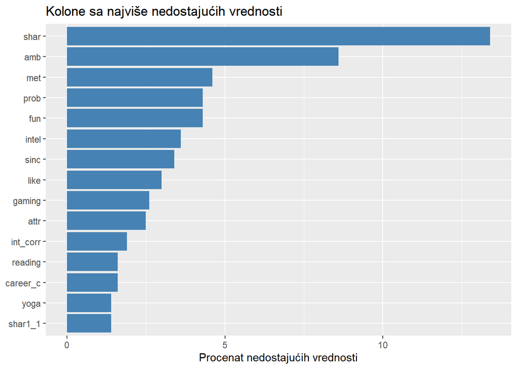

```r
na_sd %>%
  slice_head(n = 15) %>%
  ggplot(aes(x = reorder(kolona, procenat_na), y = procenat_na)) +
  geom_col(fill = "steelblue") +
  coord_flip() +
  labs(title = "Kolone sa najviše nedostajućih vrednosti",
       x = NULL, y = "Procenat nedostajućih vrednosti")
```

Vidimo da se bar jedno prazno polje javlja u 57 od 64 kolone, ali je kod velike većine promenljivih taj procenat veoma mali i kreće se oko 1% do 2%. Na samom vrhu nalaze se ocene sa sastanka, i to zajednička interesovanja shar sa 13,4% nedostajućih vrednosti, ambicioznost amb sa 8,6%, prethodno poznanstvo met sa 4,6%, kao i zabavnost fun i procena verovatnoće prob sa po 4,3%.

Ovde može da se primeti da je procenat praznih polja za kolonu shar porastao sa 12,7% iz drugog poglavlja na sadašnjih 13,4%. Ta razlika potiče direktno od onih 59 nula koje smo u prethodnom poglavlju tokom čišćenja skale prebacili u NA, a slična stvar važi i za kolonu prob.

Iako nijedna pojedinačna kolona nema previše praznih polja, interesantno je proveriti u koliko redova tabele ne nedostaje apsolutno nijedan podatak:

```r
sum(complete.cases(sd))
```

```
## [1] 6240
```

```r
mean(complete.cases(sd))
```

```
## [1] 0.7448078
```

Kompletno popunjene podatke u svim kolonama ima 6.240 od ukupno 8.378 redova, odnosno oko 74,5% skupa. To znači da bismo prostim brisanjem svakog reda u kom fali makar jedna cifra izgubili čitavu četvrtinu sastanaka, što nikako ne želimo da uradimo.

## 4.2 Odakle potiču nedostajuće vrednosti

Kod demografskih kolona i preferencija iz uvodnog upitnika vrednosti se ponavljaju kroz sve sastanke iste osobe, pa praznine u tom delu tabele proveravamo na nivou pojedinačnih učesnika:

```r
sd %>%
  distinct(iid, .keep_all = TRUE) %>%
  summarise(
    bez_starosti = sum(is.na(age)),
    bez_preferencija = sum(is.na(attr1_1)),
    bez_interesovanja = sum(is.na(sports)),
    bez_celog_upitnika = sum(is.na(age) & is.na(attr1_1) & is.na(sports) & is.na(goal))
  )
```

```
## # A tibble: 1 × 4
##   bez_starosti bez_preferencija bez_interesovanja bez_celog_upitnika
##          <int>            <int>             <int>              <int>
## 1            8                7                 7                  6
```

Ispostavlja se da prazna polja u uvodnom upitniku potiču od veoma malog broja ljudi. Imamo šest učesnika koji izgleda uopšte nisu predali uvodni obrazac jer im nedostaju i starost i interesovanja i preferencije, uz još par pojedinaca koji su preskočili samo po neko pitanje.

S druge strane, kod ocena sa samih sastanaka zanimljivo je proveriti da li prazna polja u najpraznijoj koloni shar nastaju tako što većina učesnika ponekad zaboravi da upiše ocenu, ili postoje ljudi koji to pitanje redovno preskaču:

```r
sd %>%
  group_by(iid) %>%
  summarise(udeo_na = mean(is.na(shar))) %>%
  summarise(
    preskocili_bar_jednom = sum(udeo_na > 0),
    preskocili_vise_od_polovine = sum(udeo_na > 0.5)
  )
```

```
## # A tibble: 1 × 2
##   preskocili_bar_jednom preskocili_vise_od_polovine
##                   <int>                       <int>
## 1                   227                          46
```

Rezultat pokazuje da važi i jedno i drugo. Ukupno 227 učesnika je bar na jednom sastanku ostavilo polje shar prazno, ali među njima imamo i 46 učesnika koji ovu osobinu nisu ocenili na više od polovine svojih sastanaka.

## 4.3 Da li je nedostajanje povezano sa odlukom

Pre nego što popunimo prazna polja u ocenama sa sastanka, moramo da se zapitamo zašto bi neko uopšte preskočio da oceni partnera. Logična pretpostavka je da učesnik koji već nakon prvog minuta vidi da mu se osoba preko puta uopšte ne dopada, na kraju razgovora samo zaokruži „ne” i ne trudi se da popuni svih osam skala do kraja. Ako je to tačno, onda sama činjenica da je neko polje ostalo prazno sugeriše negativnu odluku. Zato poredimo procenat potvrdnih odgovora u redovima gde ocena postoji i u redovima gde ona nedostaje:

```r
sd %>%
  select(dec, shar, amb, fun, prob) %>%
  pivot_longer(-dec, names_to = "ocena", values_to = "vrednost") %>%
  group_by(ocena, nedostaje = is.na(vrednost)) %>%
  summarise(udeo_da = round(mean(dec), 3), broj = n(), .groups = "drop")
```

```
## # A tibble: 8 × 4
##   ocena nedostaje udeo_da  broj
##   <chr> <lgl>       <dbl> <int>
## 1 amb   FALSE       0.427  7661
## 2 amb   TRUE        0.346   717
## 3 fun   FALSE       0.43   8014
## 4 fun   TRUE        0.192   364
## 5 prob  FALSE       0.432  8020
## 6 prob  TRUE        0.14    358
## 7 shar  FALSE       0.435  7252
## 8 shar  TRUE        0.321  1126
```

Razlike u tabeli su prilično uočljive, pa pomoću hi-kvadrat testa nezavisnosti na nivou značajnosti α = 0,05 proveravamo sledeće hipoteze:

- H0: Odsustvo ocene i konačna odluka učesnika su međusobno nezavisni.
- H1: Odsustvo ocene i konačna odluka učesnika su statistički povezani.

```r
sapply(c("shar", "amb", "fun", "prob"), function(kolona) {
  chisq.test(table(is.na(sd[[kolona]]), sd$dec))$p.value
})
```

```
##         shar          amb          fun         prob
## 8.087931e-13 3.178770e-05 3.834643e-19 8.646413e-28
```

Kod sve četiri posmatrane kolone p-vrednost je daleko manja od 0,001, što znači da možemo da odbacimo nultu hipotezu. Učesnici zaista mnogo ređe kažu „da” na sastancima gde su preskočili neku od ovih ocena. Dok je na sastancima sa uredno upisanim ocenama udeo potvrdnih odgovora oko 43%, u redovima gde fali ocena za shar on pada na 32,1%, kada fali fun pada na svega 19,2%, a kada učesnik nije upisao koliku šansu daje poklapanju u koloni prob, rekao je „da” u samo 14% slučajeva.

Iz ovoga se jasno vidi da prazna polja u ocenama nisu nastala potpuno slučajno (nisu MCAR), već da učesnici znatno češće preskaču ocenjivanje onda kada im se partner ne dopadne. Ovakvo ponašanje odgovara MNAR mehanizmu, jer ocena verovatno fali upravo zato što bi bila niska. Strogo gledano, to iz samih podataka ne možemo da dokažemo, a pošto je odluka dec uvek poznata, nedostajanje je delom objašnjivo poznatim podacima, što odgovara i MAR mehanizmu. Za dalji rad je bitno ono što sigurno znamo: nedostajanje nije slučajno i nosi informaciju o odluci.

## 4.4 Odluka o obradi

Na osnovu svega što smo ovde utvrdili, obradu nedostajućih vrednosti postavljamo kroz tri koraka:

1. Prvo, ne brišemo redove sa praznim poljima. Osim što bismo tako bacili četvrtinu podataka, izbacili bismo nesrazmerno mnogo sastanaka sa odlukom „ne” i time pokvarili prirodni balans klasa u uzorku.
2. Drugo, prazna polja popunjavamo tek u devetom poglavlju nakon podele na trening i test skup. Numeričke kolone ćemo imputirati medijanom, a faktorske najčešćom kategorijom izračunatom isključivo na trening podacima, dok ćemo u desetom poglavlju isprobati i regresionu imputaciju.
3. Treće, pošto smo upravo dokazali da samo odsustvo ocene sa sastanka nosi bitan signal za predviđanje odluke, u osmom poglavlju ćemo pre imputacije napraviti novu promenljivu broj_na_ocena koja broji koliko je ocena učesnik preskočio na datom sastanku.

# 5 Ekstremne vrednosti

Za razliku od grešaka pri unosu koje smo očistili u trećem poglavlju jer su bile van dozvoljenog opsega skale, ekstremne vrednosti, odnosno autlajeri, predstavljaju podatke koji su realno mogući, ali znatno odskaču od ostatka uzorka. Takve tačke mogu da povuku prosek ili da utiču na koeficijente modela, ali ih ne treba slepo brisati ako iza njih stoje stvarni učesnici i njihovi iskreni odgovori.

Većina numeričkih kolona u našem skupu nalazi se na strogo ograničenim skalama od 1 do 10 ili od 0 do 100 poena. Ipak, čak i na takvim zatvorenim skalama standardno pravilo interkvartilnog raspona može da označi određene odgovore kao ekstremne ukoliko se većina učesnika grupisala u uskom pojasu ocena. Zato ćemo prvo detaljno ispitati starost učesnika kao jedinu pravu otvorenu skalu, a zatim ćemo proveriti i sve ostale numeričke kolone.

## 5.1 Starost učesnika

Pošto je starost osobina samog ispitanika, analiziramo je na nivou od 551 jedinstvenog učesnika kako osobe sa većih događaja ne bi bile prebrojane više puta:

```r
ucesnici <- sd %>%
  distinct(iid, .keep_all = TRUE)

summary(ucesnici$age)
```

```
##    Min. 1st Qu.  Median    Mean 3rd Qu.    Max.    NA's
##   18.00   24.00   26.00   26.36   28.00   55.00       8
```

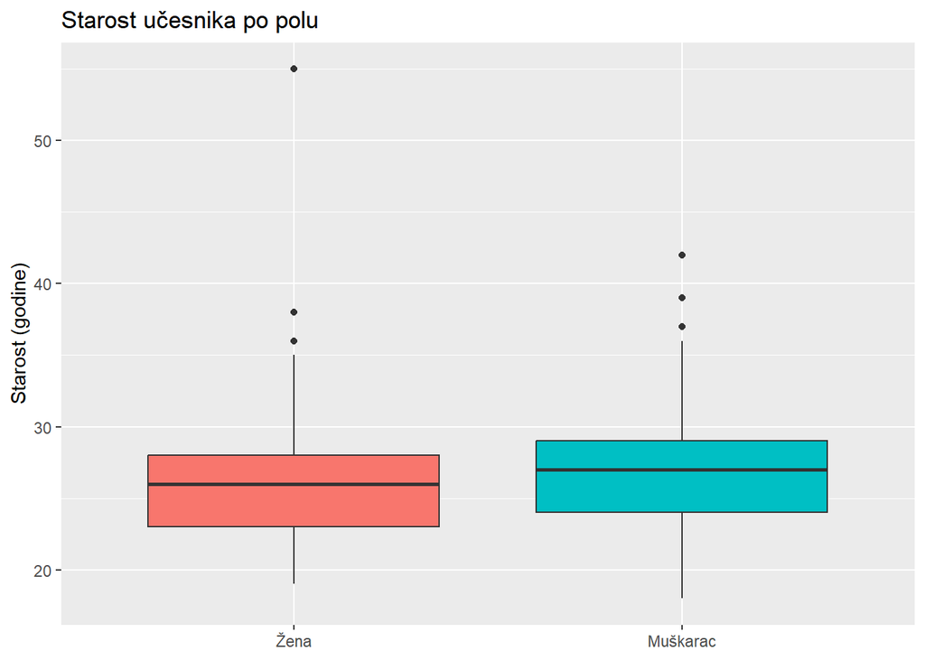

```r
ggplot(ucesnici, aes(x = gender, y = age, fill = gender)) +
  geom_boxplot(show.legend = FALSE) +
  labs(title = "Starost učesnika po polu", x = NULL, y = "Starost (godine)")
```

Iz osnovnih statistika i sa boxplot grafika vidimo da polovina svih učesnika ima između 24 i 28 godina, uz medijanu od 26 godina. Iznad gornjeg brka na grafiku uočavamo nekoliko starijih ispitanika kod oba pola, među kojima najviše odskače jedna učesnica od 55 godina.

Da bismo precizno izdvojili ove tačke, primenjujemo pravilo interkvartilnog raspona po kom se ekstremnim smatraju sve vrednosti manje od Q1 - 1,5 * IQR ili veće od Q3 + 1,5 * IQR:

```r
# IQR granice za starost ucesnika
q1 <- quantile(ucesnici$age, 0.25, na.rm = TRUE)
q3 <- quantile(ucesnici$age, 0.75, na.rm = TRUE)
iqr <- IQR(ucesnici$age, na.rm = TRUE)

donja_granica <- q1 - 1.5 * iqr
gornja_granica <- q3 + 1.5 * iqr

c(donja = donja_granica, gornja = gornja_granica)
```

```
##  donja.25% gornja.75%
##         18         34
```

```r
izvan <- ucesnici %>%
  filter(age < donja_granica | age > gornja_granica) %>%
  select(iid, wave, gender, age) %>%
  arrange(age)

izvan
```

```
## # A tibble: 13 × 4
##      iid  wave gender     age
##    <dbl> <dbl> <fct>    <dbl>
##  1    83     4 Žena        35
##  2   178     8 Žena        35
##  3   300    12 Žena        35
##  4   351    14 Žena        35
##  5   146     7 Žena        36
##  6   320    12 Muškarac    36
##  7   326    13 Žena        36
##  8   508    20 Muškarac    36
##  9   139     6 Muškarac    37
## 10   379    15 Žena        38
## 11    98     4 Muškarac    39
## 12   230     9 Muškarac    42
## 13   457    18 Žena        55
```

```r
sd %>%
  filter(iid %in% izvan$iid) %>%
  nrow()
```

```
## [1] 173
```

Pošto je interkvartilni raspon veoma uzak i iznosi svega 4 godine, granice normalnog raspona ispadaju od 18 do 34 godine. Ispod donje granice nema nikoga, dok iznad 34 godine imamo 13 učesnika, tačnije osam žena i pet muškaraca starosti od 35 do 55 godina, koji su zajedno učestvovali na 173 sastanka.

Ove učesnike svakako zadržavamo u skupu podataka. Iako većinu postdiplomaca čine ljudi u srednjim dvadesetim godinama, potpuno je normalno da na doktorskim ili master studijama ima i ljudi u tridesetim, četrdesetim ili pedesetim godinama, tako da ovde nije reč o grešci. Njihovim brisanjem izgubili bismo 173 sastanka i ujedno bismo uskratili modelu priliku da nauči kako mlađi učesnici reaguju kada preko puta njih sedne znatno stariji partner. Sam uticaj ovih ekstremnih godina ublažićemo u osmom poglavlju uvođenjem razlike u godinama između partnera.

Kao dodatnu proveru primenili smo i kriterijum z-vrednosti (|z| > 3), koji kao ekstremne izdvaja samo 4 najstarija učesnika sa 38, 39, 42 i 55 godina. Ovaj kriterijum se oslanja na prosek i standardnu devijaciju, koje i sami stariji učesnici podižu, a pretpostavlja i normalnu raspodelu, dok starost u našem skupu ima dugačak desni rep. Zato se u radu oslanjamo na IQR pravilo, a zaključak u oba slučaja ostaje isti.

## 5.2 Ostale numeričke kolone

Sada pravilo interkvartilnog raspona primenjujemo i na sve preostale numeričke kolone u skupu, pri čemu promenljive iz uvodnog upitnika ponovo gledamo na nivou učesnika, a ocene sa sastanaka na nivou pojedinačnog reda:

```r
iqr_van <- function(x) {
  q <- quantile(x, c(0.25, 0.75), na.rm = TRUE)
  i <- q[2] - q[1]
  sum(x < q[1] - 1.5 * i | x > q[2] + 1.5 * i, na.rm = TRUE)
}

po_ucesniku <- c("imprace", "imprelig", "date", "go_out",
                 interesovanja, preferencije)
po_redu <- c("attr", "sinc", "intel", "fun", "amb", "shar",
             "like", "prob", "int_corr", "order")

bind_rows(
  ucesnici %>%
    summarise(across(all_of(po_ucesniku), iqr_van)) %>%
    pivot_longer(everything(), names_to = "kolona", values_to = "izvan") %>%
    mutate(jedinica = "učesnik"),
  sd %>%
    summarise(across(all_of(po_redu), iqr_van)) %>%
    pivot_longer(everything(), names_to = "kolona", values_to = "izvan") %>%
    mutate(jedinica = "sastanak")
) %>%
  filter(izvan > 0) %>%
  arrange(desc(izvan))
```

```
## # A tibble: 29 × 3
##    kolona  izvan jedinica
##    <chr>   <int> <chr>
##  1 amb       143 sastanak
##  2 sinc      113 sastanak
##  3 like      110 sastanak
##  4 sinc1_1    75 učesnik
##  5 fun2_1     73 učesnik
##  6 sinc3_1    54 učesnik
##  7 shar2_1    52 učesnik
##  8 fun1_1     48 učesnik
##  9 intel      48 sastanak
## 10 attr1_1    39 učesnik
## # ℹ 19 more rows
```

Iako funkcija pronalazi tačke van IQR granica u 29 kolona, treba imati u vidu da su sve te vrednosti prethodno već očišćene i da se nalaze unutar dozvoljenih skala od 1 do 10 ili od 0 do 100. Razlog zašto ih formula uopšte hvata jeste to što su ljudi kod nekih pitanja davali veoma ujednačene odgovore. Tako recimo većina studenata za čitanje ili iskrenost daje visoke ocene od 7 do 9, pa interkvartilni raspon postane toliko uzak da svaka ocena 1, 2 ili 3 automatski ispadne ispod donje granice. Slično važi i kada neko privlačnosti u uvodnom upitniku dodeli 50 ili 100 poena dok većina daje oko 20. Takve tačke naravno nisu nikakve anomalije koje treba brisati, već upravo one razlike u ukusima i utiscima na osnovu kojih model i treba da predvidi odluku.

# 6 Eksplorativna analiza podataka

Pre nego što pređemo na formalne statističke testove i treniranje modela, u ovom poglavlju kroz tabelarne preglede i grafike istražujemo kako se ponašaju ključne promenljive u našem skupu. Analizu smo podelili na tri logična koraka: prvo gledamo raspodele pojedinačnih promenljivih kroz univarijantnu analizu, zatim u bivarijantnoj analizi ispitujemo kako svaka od njih pojedinačno utiče na odluku dec, i na kraju u multivarijantnoj analizi posmatramo međusobne korelacije više promenljivih istovremeno.

## 6.1 Univarijantna analiza

### 6.1.1 Ciljna promenljiva

Prva stvar koju proveravamo jeste odnos potvrdnih i odričnih odgovora u ciljnoj promenljivoj dec. Od balansa klasa direktno zavisi kako ćemo kasnije ocenjivati modele, jer kada bi jedna odluka činila 90% skupa, obična tačnost bi bila potpuno beskorisna metrika. Pošto se naša prva hipoteza bavi razlikom u izbirljivosti između muškaraca i žena, procente odgovora „da” i „ne” odmah prikazujemo odvojeno po polu:

```r
mean(sd$dec)
```

```
## [1] 0.4199093
```

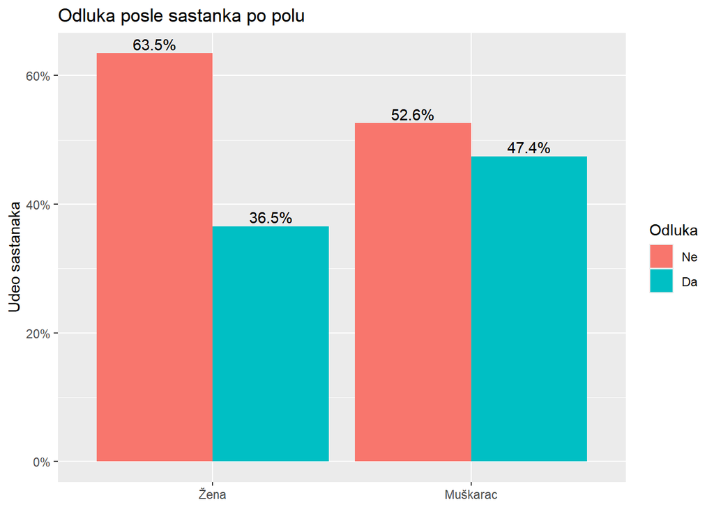

```r
sd %>%
  count(gender, dec) %>%
  group_by(gender) %>%
  mutate(udeo = n / sum(n)) %>%
  ggplot(aes(x = gender, y = udeo, fill = factor(dec, labels = c("Ne", "Da")))) +
  geom_col(position = "dodge") +
  geom_text(aes(label = scales::percent(udeo, accuracy = 0.1)),
            position = position_dodge(width = 0.9), vjust = -0.3) +
  scale_y_continuous(labels = scales::percent) +
  labs(title = "Odluka posle sastanka po polu", x = NULL, y = "Udeo sastanaka",
       fill = "Odluka")
```

Na nivou celog skupa učesnici su rekli „da” nakon 42% sastanaka, dok je u 58% slučajeva odgovor bio „ne”. To znači da su klase umereno neuravnotežene. Iako disbalans nije drastičan, model koji bi bez ikakvog učenja za svaki sastanak slepo pogađao „ne” imao bi tačnost od 58%. Zbog toga ćemo u delu sa mašinskim učenjem pored tačnosti obavezno pratiti F1 meru i površinu ispod ROC krive (AUC), a taj naivni model će nam služiti kao donji prag uspešnosti.

Sa grafika se jasno vidi i razlika između polova. Muškarci daju potvrdan odgovor na 47,4% svojih sastanaka, dok žene kažu „da” u 36,5% slučajeva, što je razlika od skoro 11 procentnih poena u korist muškaraca. Da li je ova razlika statistički značajna proverićemo u narednom poglavlju u okviru hipoteze H1.

### 6.1.2 Ocene partnera

Sada gledamo kako učesnici generalno ocenjuju partnere na onih osam skala od 1 do 10 nakon sastanka. Zanima nas koje osobine u proseku dobijaju najviše ocene, a kod kojih postoji najveće rasipanje, jer osobina na kojoj skoro svi dobiju istu ocenu teško može da objasni zašto je neko prošao dalje, a neko nije:

```r
ocene <- c("attr", "sinc", "intel", "fun", "amb", "shar", "like", "prob")

sd %>%
  select(all_of(ocene)) %>%
  summarise(across(everything(), list(prosek = ~ mean(.x, na.rm = TRUE),
                                      sd = ~ sd(.x, na.rm = TRUE)))) %>%
  pivot_longer(everything(),
               names_to = c("ocena", ".value"),
               names_pattern = "(.*)_(prosek|sd)$") %>%
  mutate(across(where(is.numeric), ~ round(.x, 2))) %>%
  arrange(desc(prosek))
```

```
## # A tibble: 8 × 3
##   ocena prosek    sd
##   <chr>  <dbl> <dbl>
## 1 intel   7.37  1.54
## 2 sinc    7.18  1.72
## 3 amb     6.78  1.79
## 4 fun     6.41  1.94
## 5 attr    6.2   1.94
## 6 like    6.14  1.83
## 7 shar    5.52  2.11
## 8 prob    5.24  2.1
```

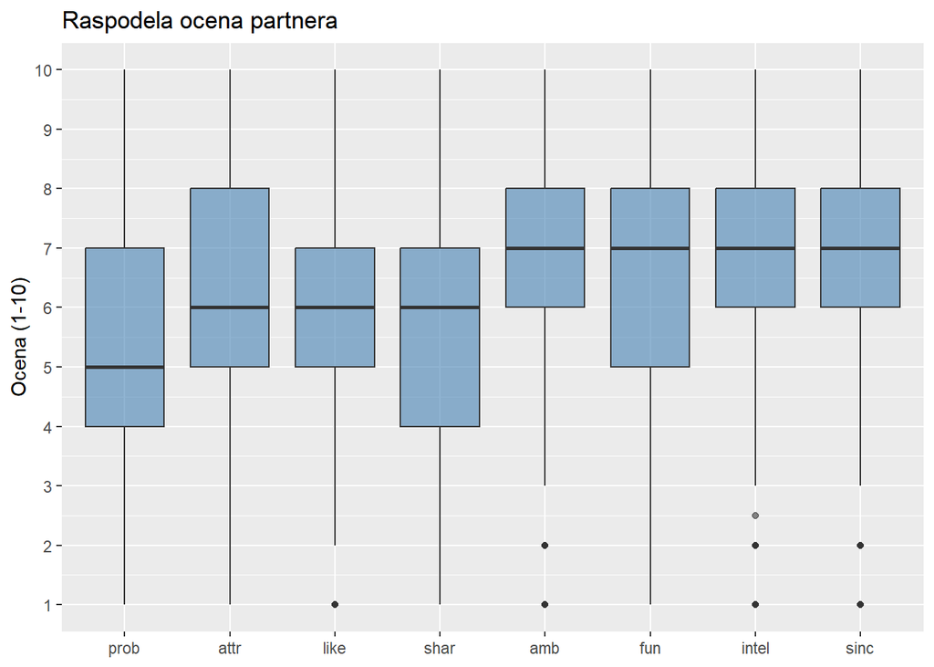

```r
sd %>%
  select(all_of(ocene)) %>%
  pivot_longer(everything(), names_to = "ocena", values_to = "vrednost") %>%
  filter(!is.na(vrednost)) %>%
  ggplot(aes(x = reorder(ocena, vrednost, median), y = vrednost)) +
  geom_boxplot(fill = "steelblue", alpha = 0.6) +
  scale_y_continuous(breaks = 1:10) +
  labs(title = "Raspodela ocena partnera", x = NULL, y = "Ocena (1-10)")
```

Vidimo da ispitanici najviše ocene daju za inteligenciju sa prosekom 7,37 i iskrenost sa 7,18, a odmah iza njih je i ambicioznost sa 6,78. Na samom dnu su zajednička interesovanja sa prosekom 5,52 i procena verovatnoće da će i druga strana reći „da” sa prosekom 5,24. Sa boxplot grafika se lepo primećuje da za inteligenciju, iskrenost i ambicioznost učesnici retko koriste donji deo skale, pa se polovina svih ocena smestila u uzak raspon između 6 i 8.

Za predviđanje odluke još nam je bitnija kolona sa standardnom devijacijom. Inteligencija ima najmanju standardnu devijaciju od 1,54 jer je za četiri minuta razgovora realno teško proceniti nečiju pamet, pa ljudi iz pristojnosti uglavnom daju sedmicu ili osmicu. Nasuprot tome, najveću varijaciju imaju zajednička interesovanja sa standardnom devijacijom 2,11, procena prob sa 2,10, kao i privlačnost i zabavnost sa po 1,94. Pošto se fizički izgled i to koliko je neko zanimljiv sagovornik vide već u prvom minutu, ovde učesnici koriste celu skalu od 1 do 10, pa očekujemo da će upravo te promenljive nositi najviše informacije o odluci.

### 6.1.3 Starost učesnika

Kratko ćemo pogledati i histogram starosti svih učesnika kako bismo imali jasnu sliku o demografiji uzorka:

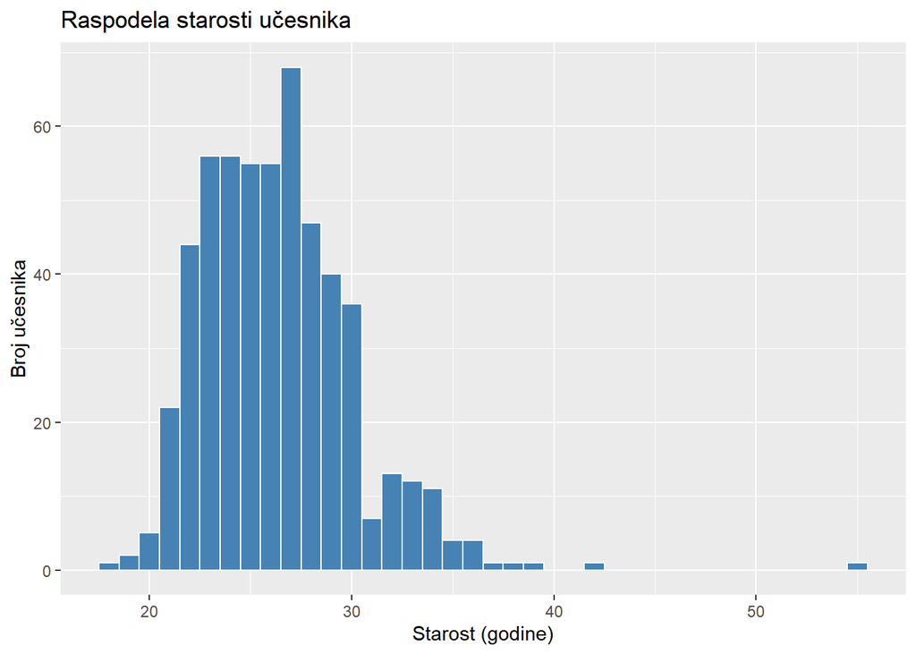

```r
ggplot(ucesnici, aes(x = age)) +
  geom_histogram(binwidth = 1, fill = "steelblue", color = "white", na.rm = TRUE) +
  labs(title = "Raspodela starosti učesnika", x = "Starost (godine)",
       y = "Broj učesnika")
```

```r
mean(between(ucesnici$age, 22, 30), na.rm = TRUE)
```

```
## [1] 0.8416206
```

Raspodela je očekivano zakrivljena udesno sa gustim jezgrom u srednjim dvadesetim godinama, gde čak 84,2% svih studenata u eksperimentu ima između 22 i 30 godina. Pošto veliku većinu uzorka čine vršnjaci, i razlike u godinama na samim sastancima biće u proseku veoma male, što će biti važno kada budemo tumačili rezultate za hipotezu H3.

## 6.2 Bivarijantna analiza

Nakon pregleda pojedinačnih promenljivih, u bivarijantnoj analizi ukrštamo ulazne kolone direktno sa ciljnom promenljivom dec kako bismo videli šta najviše razdvaja pozitivne i negativne odluke.

### 6.2.1 Privlačnost i odluka

Pošto je fizička privlačnost prva stvar koja se primeti pri upoznavanju, prvo proveravamo kako procenat odgovora „da” raste sa ocenom attr. Krive crtamo odvojeno za muškarce i žene jer nas u okviru druge hipoteze zanima da li izgled partnera jače utiče na muške odluke. Retke ocene na pola boda ovde zaokružujemo na najbliži ceo broj kako bismo imali stabilne procente u svakoj tački:

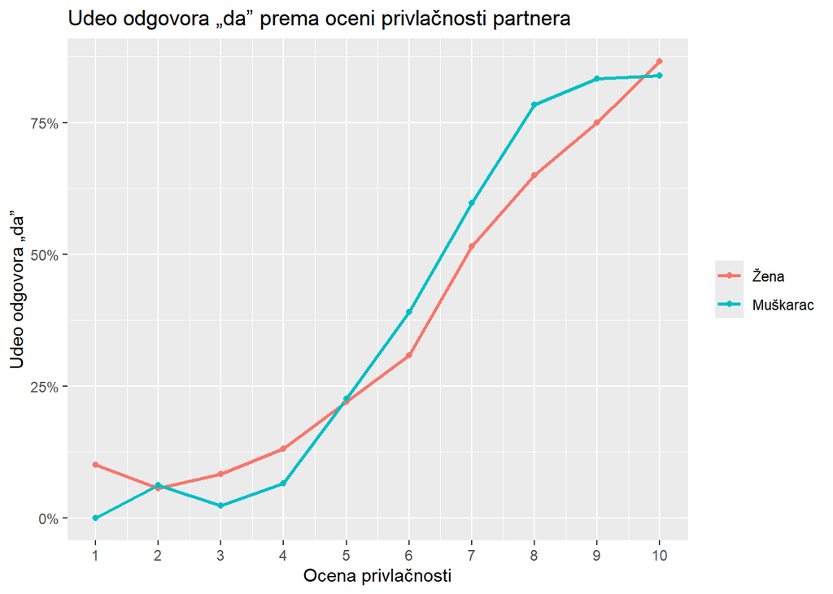

```r
sd %>%
  filter(!is.na(attr)) %>%
  mutate(attr_ceo = round(attr)) %>%
  group_by(gender, attr_ceo) %>%
  summarise(udeo_da = mean(dec), broj = n(), .groups = "drop") %>%
  ggplot(aes(x = attr_ceo, y = udeo_da, color = gender)) +
  geom_line(linewidth = 1) +
  geom_point() +
  scale_x_continuous(breaks = 1:10) +
  scale_y_continuous(labels = scales::percent) +
  labs(title = "Udeo odgovora „da” prema oceni privlačnosti partnera",
       x = "Ocena privlačnosti", y = "Udeo odgovora „da”", color = NULL)
```

Grafik pokazuje izuzetno jaku vezu kod oba pola. Kada partner dobije nisku ocenu privlačnosti od 1 do 4, šansa za potvrdan odgovor je minimalna i kreće se ispod 13%. Već na oceni 7 udeo odgovora „da” prelazi 50%, dok kod devetki i desetki skače na preko 75%. Pritom se jasno vidi da je plava linija za muškarce strmija u srednjem i gornjem delu skale. Dok za ocene od 1 do 5 muškarci i žene glasaju skoro identično, već na oceni 7 muškarci kažu „da” u 60% slučajeva naspram 51% kod žena, a na oceni 8 taj odnos je 78% prema 65%, što ide direktno u prilog našoj hipotezi H2.

### 6.2.2 Ocene partnera prema odluci

Da bismo uporedili privlačnost sa ostalim osobinama sa sastanka, računamo prosečnu vrednost svake od osam ocena posebno za sastanke koji su se završili sa „ne” i za one koji su se završili sa „da”:

```r
ocene_po_odluci <- sd %>%
  select(dec, all_of(ocene)) %>%
  pivot_longer(-dec, names_to = "ocena", values_to = "vrednost") %>%
  group_by(ocena, odluka = factor(dec, labels = c("Ne", "Da"))) %>%
  summarise(prosek = mean(vrednost, na.rm = TRUE), .groups = "drop")

ocene_po_odluci %>%
  pivot_wider(names_from = odluka, values_from = prosek) %>%
  mutate(razlika = Da - Ne) %>%
  mutate(across(where(is.numeric), ~ round(.x, 2))) %>%
  arrange(desc(razlika))
```

```
## # A tibble: 8 × 4
##   ocena    Ne    Da razlika
##   <chr> <dbl> <dbl>   <dbl>
## 1 attr   5.38  7.29    1.91
## 2 like   5.32  7.22    1.9
## 3 shar   4.77  6.49    1.71
## 4 fun    5.71  7.34    1.62
## 5 prob   4.67  5.98    1.31
## 6 sinc   6.87  7.6     0.73
## 7 intel  7.08  7.76    0.67
## 8 amb    6.5   7.16    0.66
```

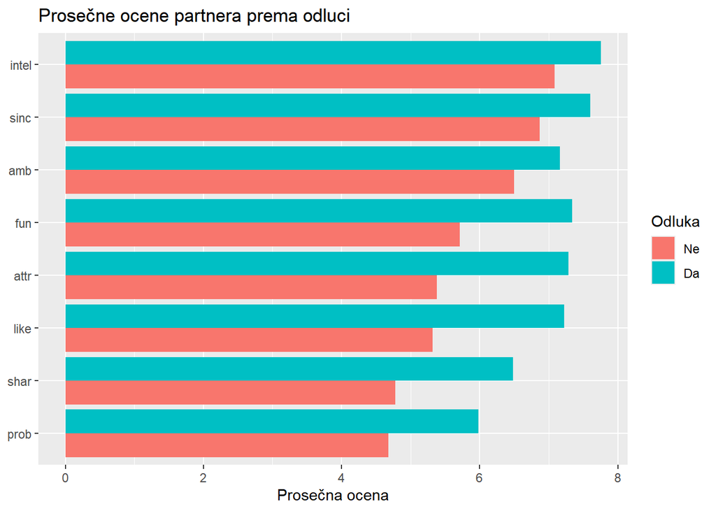

```r
ggplot(ocene_po_odluci, aes(x = reorder(ocena, prosek), y = prosek, fill = odluka)) +
  geom_col(position = "dodge") +
  coord_flip() +
  labs(title = "Prosečne ocene partnera prema odluci", x = NULL,
       y = "Prosečna ocena", fill = "Odluka")
```

Naravno, partneri koji su dobili „da” imaju u proseku više ocene na svim skalama, ali veličina tog jaza drastično varira od osobine do osobine. Najveća razlika u prosecima između pozitivne i negativne odluke javlja se kod privlačnosti gde iznosi 1,91 poen, zatim kod opšteg utiska like sa 1,90 poena, zajedničkih interesovanja sa 1,71 i zabavnosti sa 1,62 poena. S druge strane, kod iskrenosti, inteligencije i ambicioznosti partneri kojima je rečeno „da” imaju u proseku tek za 0,66 do 0,73 poena višu ocenu od onih koji su odbijeni. Ovo se potpuno poklapa sa našim ranijim zapažanjem iz univarijantne analize da na kratkom sastanku presuđuju one osobine koje se najlakše uoče.

Pošto su sve ocene više kod partnera koji su dobili „da”, prirodno se nameće ideja da se šest ocena spoji u jednu globalnu ocenu partnera. To radimo u osmom poglavlju kroz dve nove promenljive: prosek_ocena, koja je običan prosek šest ocena, i ponderisana_ocena, kod koje svaka ocena dobija težinu prema poenima koje je učesnik pre događaja dodelio toj osobini. Tamo proveravamo i koliko dobro takva jedna ocena sama razdvaja odluke „da” i „ne”.

### 6.2.3 Ista rasa, veličina događaja i prethodno poznanstvo

Sada proveravamo kako se procenat potvrdnih odgovora menja kroz kategorije tri bitne nominalne promenljive, a to su indikator iste rase samerace iz hipoteze H3, veličina događaja condtn i podatak da li su se osobe poznavale pre te večeri met:

```r
sd %>%
  mutate(across(c(samerace, condtn, met), as.character)) %>%
  select(dec, samerace, condtn, met) %>%
  pivot_longer(-dec, names_to = "promenljiva", values_to = "vrednost") %>%
  filter(!is.na(vrednost)) %>%
  group_by(promenljiva, vrednost) %>%
  summarise(udeo_da = round(mean(dec), 3), broj = n(), .groups = "drop")
```

```
## # A tibble: 6 × 4
##   promenljiva vrednost       udeo_da  broj
##   <chr>       <chr>            <dbl> <int>
## 1 condtn      Mali događaj     0.46   1434
## 2 condtn      Veliki događaj   0.412  6944
## 3 met         Da               0.607   351
## 4 met         Ne               0.421  7644
## 5 samerace    Da               0.434  3316
## 6 samerace    Ne               0.411  5062
```

Kod promenljive samerace vidimo da učesnici daju potvrdan odgovor u 43,4% slučajeva kada je partner iste rase, u poređenju sa 41,1% kada nije. Razlika postoji u smeru koji predviđa hipoteza H3, ali iznosi jedva nešto više od 2 procentna poena. Kod veličine događaja primećujemo da su na manjim događajima od 5 do 10 sastanaka ljudi bili nešto manje izbirljivi pa su rekli „da” u 46% slučajeva, naspram 41,2% na velikim događajima gde su imali veći izbor. Konačno, ubedljivo najveći skok vidimo kod kolone met, gde poznanicima učesnici kažu „da” u čak 60,7% slučajeva, ali pošto takvi susreti čine svega 4% tabele, ova kolona neće moći previše da pomogne modelu na nivou celog skupa.

### 6.2.4 Razlika u godinama

Drugi deo treće hipoteze kaže da učesnici češće biraju partnere koji su im bliži po godinama. Zato računamo apsolutnu razliku u starosti između učesnika i partnera i poredimo njenu raspodelu za pozitivne i negativne odluke, pri čemu y-osu na grafiku sečemo na 15 godina kako bi se kvartili lepo videli:

```r
razlika <- sd %>%
  mutate(razlika_godina = abs(age - age_o),
         odluka = factor(dec, labels = c("Ne", "Da"))) %>%
  filter(!is.na(razlika_godina))

razlika %>%
  group_by(odluka) %>%
  summarise(prosek = round(mean(razlika_godina), 2),
            medijana = median(razlika_godina),
            broj = n())
```

```
## # A tibble: 2 × 4
##   odluka prosek medijana  broj
##   <fct>   <dbl>    <dbl> <int>
## 1 Ne       3.75        3  4741
## 2 Da       3.53        3  3439
```

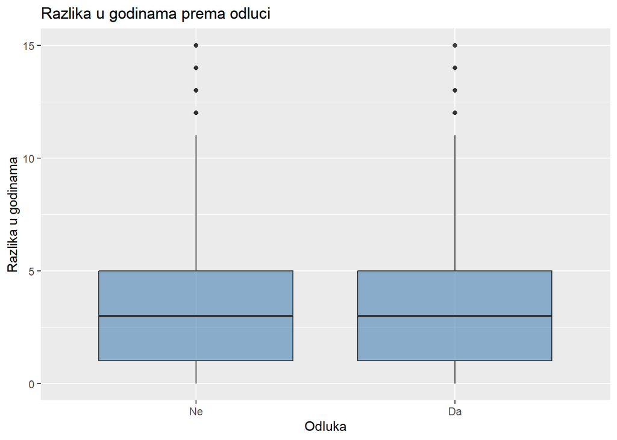

```r
ggplot(razlika, aes(x = odluka, y = razlika_godina)) +
  geom_boxplot(fill = "steelblue", alpha = 0.6) +
  coord_cartesian(ylim = c(0, 15)) +
  labs(title = "Razlika u godinama prema odluci", x = "Odluka",
       y = "Razlika u godinama")
```

Na boxplot grafiku ove dve grupe izgledaju praktično identično. I kod odluke „ne” i kod odluke „da” medijana razlike u godinama iznosi tačno 3 godine, dok se interkvartilni raspon kod obe klase proteže od 1 do 5 godina. Jedina sitna razlika vidi se u aritmetičkoj sredini, koja kod potvrdnih odgovora iznosi 3,53 godine, a kod odričnih 3,75 godina. Ovako slab efekat je sasvim logičan kada se setimo da skoro 85% učesnika u eksperimentu pripada istoj starosnoj grupi od 22 do 30 godina.

## 6.3 Multivarijantna analiza

### 6.3.1 Povezanost ocena sa odlukom i međusobno

U praksi učesnik ne ocenjuje osobine partnera izolovano, već osoba koja ostavi dobar opšti utisak obično dobije visoke ocene na više skala odjednom. Zato računamo Pirsonove koeficijente korelacije između svih osam ocena sa sastanka i odluke dec, a zatim izdvajamo i parove samih ocena koji su međusobno najjače povezani:

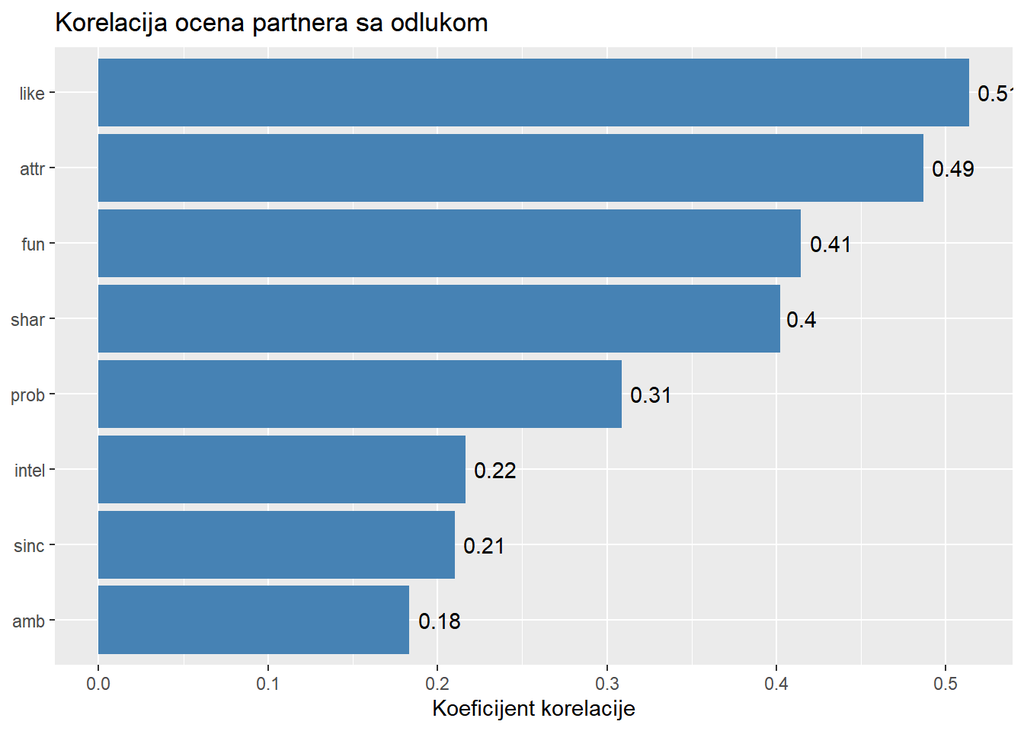

```r
korelacije <- sd %>%
  select(all_of(ocene), dec) %>%
  cor(use = "pairwise.complete.obs")

tibble(ocena = ocene, r = korelacije[ocene, "dec"]) %>%
  ggplot(aes(x = reorder(ocena, r), y = r)) +
  geom_col(fill = "steelblue") +
  geom_text(aes(label = round(r, 2)), hjust = -0.2) +
  coord_flip() +
  labs(title = "Korelacija ocena partnera sa odlukom",
       x = NULL, y = "Koeficijent korelacije")
```

```r
korelacije[ocene, ocene] %>%
  as.data.frame() %>%
  rownames_to_column("ocena_1") %>%
  pivot_longer(-ocena_1, names_to = "ocena_2", values_to = "r") %>%
  filter(ocena_1 < ocena_2) %>%
  mutate(r = round(r, 2)) %>%
  arrange(desc(r)) %>%
  slice_head(n = 6)
```

```
## # A tibble: 6 × 3
##   ocena_1 ocena_2     r
##   <chr>   <chr>   <dbl>
## 1 fun     like     0.69
## 2 attr    like     0.66
## 3 intel   sinc     0.66
## 4 like    shar     0.66
## 5 amb     intel    0.62
## 6 fun     shar     0.61
```

Korelacije sa ciljnom promenljivom potvrđuju redosled koji smo videli kod razlika u prosecima. Sa odlukom dec najjače koreliraju opšti utisak like sa r = 0,51 i privlačnost attr sa r = 0,49, a prate ih zabavnost sa 0,41 i zajednička interesovanja sa 0,40. Inteligencija, iskrenost i ambicioznost imaju prilično niske korelacije sa odlukom koje se kreću od 0,18 do 0,22.

Druga tabela nam otkriva da su i same ocene prilično uvezane. Opšti utisak like ima visoku korelaciju sa zabavnošću od 0,69, kao i sa privlačnošću i zajedničkim interesovanjima od po 0,66, što potvrđuje da učesnici kroz kolonu like zapravo daju neku vrstu zbirne ocene partnera. Pored toga, vidimo i jaku vezu između inteligencije i iskrenosti od 0,66, te inteligencije i ambicioznosti od 0,62. Iako nijedna od ovih korelacija ne prelazi kritični prag od 0,80 zbog kog bismo morali odmah da izbacimo neku kolonu, ovoliko preklapanje znači da ćemo u delu sa modelima morati da proverimo multikolinearnost pomoću VIF faktora i da će nam regularizovani modeli poput ridge i lasso regresije verovatno biti od koristi.

### 6.3.2 Šta učesnici kažu da traže

Za kraj eksplorativne analize gledamo kako su muškarci i žene u uvodnom upitniku pre događaja raspodelili onih 100 poena na šest osobina (kolone attr1_1 do shar1_1) i to poredimo sa onim što smo upravo videli da utiče na njihove stvarne odluke:

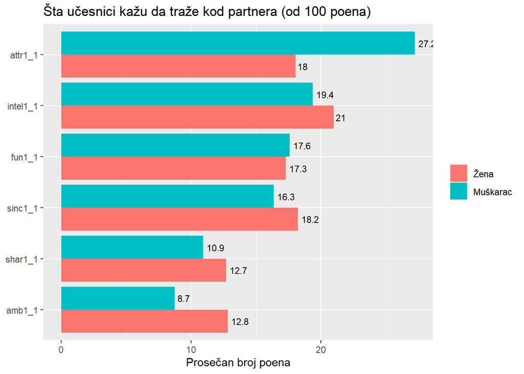

```r
ucesnici <- sd %>%
  distinct(iid, .keep_all = TRUE)

ucesnici %>%
  select(gender, all_of(pref_1)) %>%
  pivot_longer(-gender, names_to = "osobina", values_to = "poeni") %>%
  group_by(gender, osobina) %>%
  summarise(prosek = mean(poeni, na.rm = TRUE), .groups = "drop") %>%
  ggplot(aes(x = reorder(osobina, prosek), y = prosek, fill = gender)) +
  geom_col(position = "dodge") +
  geom_text(aes(label = round(prosek, 1)),
            position = position_dodge(width = 0.9), hjust = -0.2, size = 3) +
  coord_flip() +
  labs(title = "Šta učesnici kažu da traže kod partnera (od 100 poena)",
       x = NULL, y = "Prosečan broj poena", fill = NULL)
```

Grafik pokazuje zanimljiv kontrast između polova u početnim izjavama. Muškarci već u upitniku otvoreno stavljaju privlačnost na prvo mesto sa prosečno 27 poena, dok su im inteligencija sa 19,4, zabavnost sa 17,6 i iskrenost sa 16,3 poena u drugom planu. Žene, međutim, u anketi tvrde da im je najvažnija inteligencija kojoj daju 21 poen, zatim iskrenost sa 18,2 poena, pa tek onda privlačnost sa 18 i zabavnost sa 17,3 poena. Kada to uporedimo sa prethodnim graficima gde smo videli da u praksi i kod žena privlačnost i zabavnost ubedljivo najjače vuku ka odluci „da”, dok inteligencija i iskrenost igraju sporednu ulogu, dobijamo odličnu osnovu za testiranje četvrte hipoteze.

## 6.4 Zaključak eksplorativne analize

- Ciljna promenljiva ima umeren disbalans od 42% potvrdnih prema 58% odričnih odgovora, pa ćemo modele pored obične tačnosti ocenjivati pomoću F1 mere i ROC AUC skorova.
- Muškarci znatno češće govore „da” nego žene (47,4% naspram 36,5%), a kriva potvrdnih odgovora u zavisnosti od ocene privlačnosti partnera kod muškaraca raste strmije nego kod žena.
- Na odluku sa sastanka najviše utiču opšti utisak like, privlačnost, zabavnost i zajednička interesovanja, dok inteligencija, iskrenost i ambicioznost veoma slabo razdvajaju klase.
- Ista rasa i manja razlika u godinama u našem uzorku pokazuju sasvim blagu vezu sa pozitivnom odlukom.
- Ocene sa sastanka su umereno do jako međusobno korelisane, o čemu ćemo voditi računa prilikom konstrukcije i tumačenja linearnih modela.
- Postoji očigledan raskorak između osobina kojima učesnici daju najviše poena u uvodnom upitniku i onih osobina koje zaista presuđuju na četvorominutnom sastanku, što je posebno izraženo kod žena.

# 7 Statistički testovi

U ovom poglavlju sve obrasce koje smo uočili tokom eksplorativne analize proveravamo formalnim statističkim testovima kako bismo utvrdili da li su uočene razlike zaista statistički značajne ili su mogle nastati slučajno. Za svaku od pet postavljenih hipoteza definišemo nultu (H0) i alternativnu (H1) hipotezu, proveravamo uslove za primenu parametarskih testova poput normalnosti raspodele i donosimo odluku na nivou značajnosti α = 0,05.

Pored same p-vrednosti, uz svaki test obavezno računamo i odgovarajuću meru veličine efekta. Ovo je neophodno zato što radimo sa tabelom od 8.378 redova, a na tako velikom uzorku čak i potpuno nebitne, milimetarske razlike lako daju p-vrednost manju od 0,05. Dok nam p-vrednost govori samo da li efekat nije ravan nuli, veličina efekta nam otkriva koliko je ta razlika zaista bitna u praksi.

## 7.1 Napomena o zavisnosti opažanja

Pre izvođenja testova važno je podsetiti se da standardni statistički testovi pretpostavljaju da su sva opažanja u uzorku međusobno nezavisna. Kao što smo objasnili u drugom poglavlju, u našoj tabeli se svaki učesnik pojavljuje u 5 do 22 reda, pa odluke koje je donela ista osoba tokom večeri nisu potpuno nezavisne jedna od druge. Posledica toga je da testovi sprovedeni nad svih 8.378 redova vide veći efektivni uzorak nego što zaista imamo jedinstvenih ljudi, pa daju nešto niže p-vrednosti. Da bismo izbegli pogrešne zaključke, ovaj problem rešavamo na tri načina:

1. kod prve hipoteze test izvodimo i na nivou cele tabele i na nivou od 551 pojedinačnog učesnika gde su opažanja potpuno nezavisna;
2. kod svih testova zaključak ne donosimo samo na osnovu p-vrednosti, već gledamo izračunatu veličinu efekta na koju broj ponavljanja ne utiče;
3. svaki rezultat kod kog je p-vrednost blizu graničnih 0,05 uz zanemarljiv efekat tumačimo sa oprezom.

Formalno modelovanje zavisnih opažanja pomoću modela sa slučajnim efektima po učesniku i partneru prevazilazi gradivo ovog predmeta, pa ćemo se zadržati na opisanim proverama.

## 7.2 H1: Muškarci češće odgovaraju sa „da”

- H0: Pol učesnika i odluka na sastanku su nezavisni, odnosno muškarci i žene jednako često govore „da”.
- H1: Pol učesnika i odluka su povezani, pri čemu se udeo potvrdnih odgovora razlikuje između muškaraca i žena.

Pošto na nivou pojedinačnih sastanaka poredimo dve kategorijske promenljive, prvo primenjujemo Pirsonov hi-kvadrat test nezavisnosti, a veličinu efekta izražavamo kao razliku u procentu potvrdnih odgovora između muškaraca i žena:

```r
tabela_h1 <- table(sd$gender, sd$dec)
tabela_h1
```

```
##
##               0    1
##   Žena     2655 1529
##   Muškarac 2205 1989
```

```r
test_h1 <- chisq.test(tabela_h1)
test_h1
```

```
##
##  Pearson's Chi-squared test with Yates' continuity correction
##
## data:  tabela_h1
## X-squared = 101.36, df = 1, p-value < 2.2e-16
```

```r
round(prop.table(tabela_h1, margin = 1) * 100, 1)
```

```
##
##               0    1
##   Žena     63.5 36.5
##   Muškarac 52.6 47.4
```

Hi-kvadrat statistika iznosi 101,36 uz p-vrednost manju od 0,001, pa možemo da odbacimo nultu hipotezu i zaključujemo da muškarci statistički značajno češće daju potvrdan odgovor na sastancima (47,4% prema 36,5%). Razlika od oko 11 procentnih poena je stvarna, ali umerena, i govori nam da sam pol učesnika, iako pravi jasnu razliku, naravno nije jedina stvar od koje zavisi ishod sastanka.

Kako bismo bili sigurni da ova p-vrednost nije posledica višestrukih redova po osobi, test ponavljamo na nivou učesnika. Za svaku od 551 osobe računamo njen lični procenat odgovora „da” tokom večeri i zatim poredimo muškarce i žene. Da bismo znali da li smemo da koristimo parametarski t-test ili moramo da pređemo na njegovu neparametarsku zamenu, prvo proveravamo da li je udeo potvrdnih odgovora po osobi normalno raspoređen pomoću Q-Q grafika i Šapiro-Vilkovog testa:

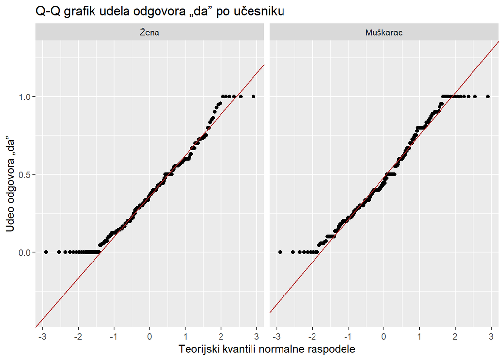

```r
po_ucesniku_h1 <- sd %>%
  group_by(iid, gender) %>%
  summarise(udeo_da = mean(dec), .groups = "drop")

ggplot(po_ucesniku_h1, aes(sample = udeo_da)) +
  stat_qq() +
  stat_qq_line(color = "firebrick") +
  facet_wrap(~ gender) +
  labs(title = "Q-Q grafik udela odgovora „da” po učesniku",
       x = "Teorijski kvantili normalne raspodele", y = "Udeo odgovora „da”")
```

```r
po_ucesniku_h1 %>%
  group_by(gender) %>%
  summarise(shapiro_p = shapiro.test(udeo_da)$p.value)
```

```
## # A tibble: 2 × 2
##   gender   shapiro_p
##   <fct>        <dbl>
## 1 Žena     0.0000103
## 2 Muškarac 0.0000456
```

Sa Q-Q grafika se jasno vidi da se tačke na oba kraja odvajaju od pravca normalne raspodele i formiraju vodoravne repove na vrednostima 0 i 1, zato što u uzorku imamo oko 9% učesnika koji te večeri nikome nisu rekli „da” ili su svima rekli „da”. Šapiro-Vilkov test to i formalno potvrđuje p-vrednostima manjim od 0,001 za oba pola, čime odbacujemo pretpostavku o normalnosti. Zbog toga umesto t-testa koristimo neparametarski Man-Vitnijev test ranga za dva nezavisna uzorka:

- H0: Raspodela ličnog udela odgovora „da” je ista kod muškaraca i kod žena.
- H1: Raspodele ličnog udela odgovora „da” kod muškaraca i žena se statistički značajno razlikuju.

```r
po_ucesniku_h1 %>%
  group_by(gender) %>%
  summarise(prosek = round(mean(udeo_da), 3),
            medijana = round(median(udeo_da), 3),
            broj_ucesnika = n())
```

```
## # A tibble: 2 × 4
##   gender   prosek medijana broj_ucesnika
##   <fct>     <dbl>    <dbl>         <int>
## 1 Žena      0.374    0.368           274
## 2 Muškarac  0.481    0.444           277
```

```r
wilcox.test(udeo_da ~ gender, data = po_ucesniku_h1)
```

```
##
##  Wilcoxon rank sum test with continuity correction
##
## data:  udeo_da by gender
## W = 29229, p-value = 3.02e-06
## alternative hypothesis: true location shift is not equal to 0
```

Gledano po osobi, prosečan muškarac kaže „da” na 48,1% svojih sastanaka (medijana 44,4%), dok prosečna žena kaže „da” na 37,4% sastanaka (medijana 36,8%). Man-Vitnijev test daje p-vrednost od 3,02e-06, što je daleko ispod praga od 0,05, pa i na nivou nezavisnih ispitanika odbacujemo H0 i u potpunosti potvrđujemo hipotezu H1.

## 7.3 H2: Privlačnost više utiče na odluku muškaraca

- H0: Uticaj ocene privlačnosti partnera na verovatnoću potvrdne odluke je jednak kod muškaraca i kod žena.
- H1: Ocena privlačnosti partnera ima različit uticaj na odluku u zavisnosti od pola učesnika.

Da bismo proverili da li nagib krive sa grafika iz šestog poglavlja zaista brže raste kod muškaraca, postavljamo model binarne logističke regresije u kom odluku dec predviđamo pomoću ocene privlačnosti attr, pola gender i njihovog interakcijskog člana attr * gender. Upravo koeficijent uz interakciju meri koliko se uticaj privlačnosti kod muškaraca razlikuje u odnosu na žene, pa se testiranje hipoteze H2 svodi na proveru da li je taj koeficijent statistički značajno različit od nule.

Radi lakšeg tumačenja, u tabeli ispod prikazujemo eksponencirane koeficijente modela koji predstavljaju količnik šansi, odnosno odds ratio (OR). Vrednost OR veća od 1 znači da porast promenljive za jednu jedinicu povećava šansu za odgovor „da” toliko puta, pri čemu su žene postavljene kao referentna kategorija:

```r
model_h2 <- glm(dec ~ attr * gender, data = sd, family = binomial)

broom::tidy(model_h2, exponentiate = TRUE, conf.int = TRUE) %>%
  mutate(across(where(is.numeric), ~ round(.x, 3)))
```

```
## # A tibble: 4 × 7
##   term                estimate std.error statistic p.value conf.low conf.high
##   <chr>                  <dbl>     <dbl>     <dbl>   <dbl>    <dbl>     <dbl>
## 1 (Intercept)            0.014     0.155    -27.4        0    0.011     0.019
## 2 attr                   1.82      0.023     25.6        0    1.74      1.91
## 3 genderMuškarac         0.423     0.239     -3.60       0    0.265     0.675
## 4 attr:genderMuškarac    1.19      0.036      4.80       0    1.11      1.27
```

Iz rezultata vidimo da kod žena svako povećanje ocene privlačnosti partnera za jedan bod povećava šansu za odgovor „da” za 1,82 puta (p < 0,001). Ključni interakcijski član attr:genderMuškarac ima količnik šansi 1,19 sa 95% intervalom poverenja od 1,11 do 1,27 i p-vrednošću manjom od 0,001. To znači da odbacujemo H0 i potvrđujemo hipotezu H2. Kod muškaraca svaki dodatni poen na skali privlačnosti množi šansu za potvrdan odgovor sa 1,82 * 1,19 = 2,17 puta, što potvrđuje da fizički izgled partnera zaista ima jači uticaj na odluku muškaraca nego žena.

## 7.4 H3: Ista rasa i manja razlika u godinama

Pošto se treća hipoteza sastoji iz dve odvojene tvrdnje, prvo testiramo uticaj iste rase, a zatim uticaj razlike u godinama.

Prvi deo hipoteze: Ista rasa partnera.

- H0: Odluka na sastanku ne zavisi od toga da li su učesnik i partner iste rase.
- H1: Udeo potvrdnih odgovora zavisi od toga da li su učesnik i partner iste rase.

```r
test_h3_rasa <- chisq.test(table(sd$samerace, sd$dec))
test_h3_rasa
```

```
##
##  Pearson's Chi-squared test with Yates' continuity correction
##
## data:  table(sd$samerace, sd$dec)
## X-squared = 4.351, df = 1, p-value = 0.03699
```

```r
round(prop.table(table(sd$samerace, sd$dec), margin = 1) * 100, 1)
```

```
##
##         0    1
##   Ne 58.9 41.1
##   Da 56.6 43.4
```

Hi-kvadrat test daje statistiku 4,35 uz p-vrednost od 0,037, što je tek za nijansu ispod našeg praga od 0,05. Međutim, kada pogledamo same procente, učesnici kažu „da” u 43,4% sastanaka sa osobom iste rase i u 41,1% sa osobom druge rase, što je razlika od svega oko 2 procentna poena. Ako se setimo da su p-vrednosti na nivou svih redova blago preuveličane zbog ponovljenih merenja po učesniku, jasno je da razlika između 43,4% i 41,1% u praksi ne igra nikakvu ulogu.

Drugi deo hipoteze: Razlika u godinama.

- H0: Raspodela apsolutne razlike u godinama između partnera je ista kod odluka „da” i „ne”.
- H1: Raspodele apsolutne razlike u godinama između odluka „da” i „ne” se statistički razlikuju.

Pre izbora testa ponovo proveravamo normalnost raspodele apsolutne razlike u godinama. Pošto standardna funkcija shapiro.test() u R-u prima najviše 5.000 opažanja, a naša tabela ima preko 8.000 redova, ovde normalnost proveravamo pomoću Q-Q grafika i računanjem koeficijenta asimetrije (skewness), koji kod normalne raspodele iznosi 0:

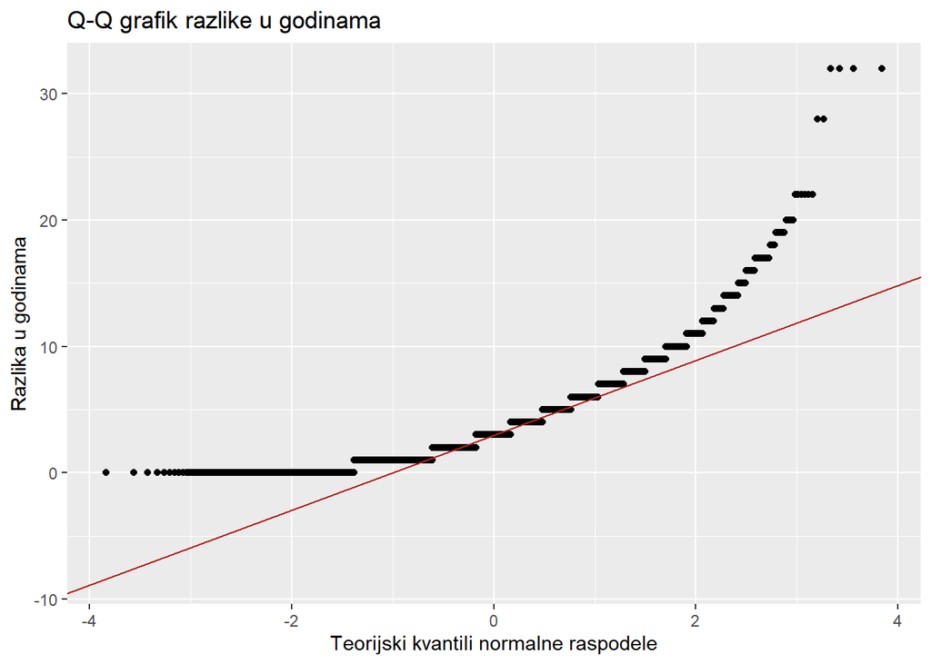

```r
ggplot(razlika, aes(sample = razlika_godina)) +
  stat_qq() +
  stat_qq_line(color = "firebrick") +
  labs(title = "Q-Q grafik razlike u godinama",
       x = "Teorijski kvantili normalne raspodele", y = "Razlika u godinama")
```

```r
asimetrija <- function(x) {
  mean((x - mean(x))^3) / sd(x)^3
}

asimetrija(razlika$razlika_godina)
```

```
## [1] 1.817882
```

Sa Q-Q grafika je očigledno da raspodela nema nikakve veze sa normalnom jer je donja granica presečena na nuli, dok desni rep beži visoko nagore. Koeficijent asimetrije iznosi čak 1,82, što potvrđuje jaku desnu zakrivljenost, pa umesto t-testa ponovo primenjujemo neparametarski Man-Vitnijev test. Kao meru veličine efekta ovde računamo verovatnoću superiornosti, koja govori kolika je šansa da nasumično izabran sastanak sa odlukom „ne” ima veću razliku u godinama od nasumično izabranog sastanka sa odlukom „da”, pri čemu se parovi sa jednakom razlikom računaju kao pola (gde vrednost 0,50 znači potpuno odsustvo efekta):

```r
test_h3_godine <- wilcox.test(razlika_godina ~ odluka, data = razlika)
test_h3_godine
```

```
##
##  Wilcoxon rank sum test with continuity correction
##
## data:  razlika_godina by odluka
## W = 8552470, p-value = 0.0001285
## alternative hypothesis: true location shift is not equal to 0
```

```r
broj_po_odluci <- table(razlika$odluka)
unname(test_h3_godine$statistic) / prod(broj_po_odluci)
```

```
## [1] 0.524553
```

Man-Vitnijev test daje p-vrednost od 0,00013 pa formalno odbacujemo H0, ali verovatnoća superiornosti iznosi svega 0,525, što je jedva različito od 0,50, dok su medijane u obe grupe identične i iznose po 3 godine.

Kada spojimo oba dela, zaključujemo da je hipoteza H3 samo formalno potvrđena na papiru zahvaljujući ogromnom broju od preko 8.000 redova, dok su u stvarnosti oba efekta potpuno zanemarljiva. Učesnici u ovom eksperimentu gotovo uopšte nisu birali partnere na osnovu rase ili godina, što je i razumljivo jer se radi o relativno homogenoj grupi postdiplomaca sa istog univerziteta, od kojih je većina u srednjim dvadesetim godinama.

## 7.5 H4: Izjavljene i stvarne preferencije

- H0: Redosled važnosti osobina koje učesnici navode u uvodnom upitniku poklapa se sa stvarnim uticajem tih osobina na njihove odluke tokom sastanaka.
- H1: Postoji značajna razlika između proklamovanih preferencija pre događaja i osobina koje stvarno određuju odluke na sastancima.

### 7.5.1 Provera pomoću modela

Da bismo direktno uporedili reči i dela, prvo za svaki pol posebno treniramo model logističke regresije u kom odluku dec predviđamo na osnovu šest ocena osobina partnera sa sastanka (attr, sinc, intel, fun, amb i shar). Model koristi samo sastanke na kojima je svih šest ocena popunjeno, pa se koeficijenti odnose na kompletno popunjene formulare. Kako smo videli u četvrtom poglavlju, ocene češće fale kod odbijenih partnera, pa među ovim sastancima ima nešto više odgovora „da” nego u celom skupu, ali to ne menja poređenje osobina međusobno. Sve ocene pre ulaska u model standardizujemo na prosek 0 i standardnu devijaciju 1 kako bi njihovi koeficijenti bili na istoj skali. Na taj način veličina standardizovanog koeficijenta nam direktno govori koliko koja osobina zaista vuče odluku ka „da”, pa taj rang možemo da uporedimo sa rangom prosečnih poena iz uvodnog upitnika:

```r
osobine <- c("attr", "sinc", "intel", "fun", "amb", "shar")

stvarni_uticaj <- function(pol) {
  podaci <- sd %>%
    filter(gender == pol) %>%
    select(dec, all_of(osobine)) %>%
    drop_na() %>%
    mutate(across(all_of(osobine), ~ as.numeric(scale(.x))))

  glm(dec ~ ., data = podaci, family = binomial) %>%
    broom::tidy(conf.int = TRUE) %>%
    filter(term != "(Intercept)") %>%
    transmute(gender = pol, osobina = term,
              koeficijent = round(estimate, 2),
              donja = round(conf.low, 2), gornja = round(conf.high, 2))
}

stvarno <- bind_rows(stvarni_uticaj("Žena"), stvarni_uticaj("Muškarac"))

izjavljeno <- ucesnici %>%
  select(gender, all_of(pref_1)) %>%
  pivot_longer(-gender, names_to = "osobina", values_to = "poeni") %>%
  mutate(gender = as.character(gender),
         osobina = str_remove(osobina, "1_1")) %>%
  group_by(gender, osobina) %>%
  summarise(poeni = round(mean(poeni, na.rm = TRUE), 1), .groups = "drop")

izjavljeno %>%
  left_join(stvarno, by = c("gender", "osobina")) %>%
  group_by(gender) %>%
  mutate(rang_izjavljeno = rank(-poeni),
         rang_stvarno = rank(-koeficijent)) %>%
  arrange(gender, rang_izjavljeno)
```

```
## # A tibble: 12 × 8
## # Groups:   gender [2]
##    gender   osobina poeni koeficijent donja gornja rang_izjavljeno rang_stvarno
##    <chr>    <chr>   <dbl>       <dbl> <dbl>  <dbl>           <dbl>        <dbl>
##  1 Muškarac attr     27.2        1.25  1.13   1.37               1          1
##  2 Muškarac intel    19.4       -0.04 -0.16   0.08               2          4
##  3 Muškarac fun      17.6        0.48  0.36   0.61               3          3
##  4 Muškarac sinc     16.3       -0.27 -0.39  -0.16               4          5.5
##  5 Muškarac shar     10.9        0.6   0.5    0.71               5          2
##  6 Muškarac amb       8.7       -0.27 -0.39  -0.16               6          5.5
##  7 Žena     intel    21          0.19  0.05   0.33               1          4
##  8 Žena     sinc     18.2       -0.16 -0.28  -0.03               2          5
##  9 Žena     attr     18          0.81  0.69   0.92               3          1
## 10 Žena     fun      17.3        0.55  0.42   0.69               4          3
## 11 Žena     amb      12.8       -0.31 -0.44  -0.19               5          6
## 12 Žena     shar     12.7        0.59  0.48   0.71               6          2
```

Rezultati u tabeli jasno pokazuju gde nastaje raskorak, naročito kod ženskog dela uzorka. Žene u uvodnom upitniku na prvo mesto stavljaju inteligenciju sa prosečno 21 poenom, a na drugo iskrenost sa 18,2 poena. Međutim, u modelu njihovih stvarnih odluka inteligencija je tek na četvrtom mestu sa skromnim koeficijentom od 0,19, dok je privlačnost, koja je u anketi bila treća sa 18 poena, u praksi ubedljivo najvažnija sa koeficijentom 0,81. Kako se 95% intervali poverenja za privlačnost (0,69 do 0,92) i inteligenciju (0,05 do 0,33) uopšte ne preklapaju, ova razlika u njihovom stvarnom uticaju je i statistički nedvosmislena. Još veći skok kod žena prave zajednička interesovanja shar, koja sa poslednjeg, šestog mesta u anketi izbijaju na visoko drugo mesto po stvarnom uticaju na sastanku sa koeficijentom 0,59.

Kod muškaraca su početne izjave na samom vrhu nešto iskrenije jer privlačnosti daju najviše poena u anketi (27,2) i ona zaista ima najjači uticaj na njihovu odluku sa koeficijentom 1,25. Ipak, i kod njih postoji neslaganje u ostatku tabele. Dok u upitniku inteligenciju stavljaju na visoko drugo mesto sa 19,4 poena, na samom sastanku njen koeficijent iznosi -0,04 i interval poverenja obuhvata nulu, što znači da uz kontrolu ostalih ocena inteligencija uopšte ne utiče na mušku odluku. Baš kao i kod žena, drugo i treće mesto u praksi zauzimaju zajednička interesovanja (0,60) i zabavnost (0,48).

Ovde je dobro objasniti i zašto iskrenost i ambicioznost u tabeli imaju blago negativne koeficijente kod oba pola, iako smo u šestom poglavlju videli da su njihove proste korelacije sa odlukom pozitivne. To se dešava zbog multikolinearnosti između ocena: kada u modelu već držimo fiksirane privlačnost, zabavnost i zajednička interesovanja, visoka ocena samo za iskrenost ili ambicioznost često označava situaciju u kojoj je učesnik partneru kog odbija iz pristojnosti dao visoke ocene za karakterne osobine.

### 7.5.2 Provera prema samoproceni posle događaja

Pošto se prethodna provera oslanja na koeficijente regresionog modela, hteli smo da proverimo hipotezu H4 i na potpuno nezavisan način. Zato smo iskoristili kolone attr7_2 do shar7_2 iz upitnika koji se popunjavao dan nakon događaja u poslednjih sedam talasa eksperimenta (talasi 15 do 21). Tada su učesnici ponovo raspoređivali 100 poena, ali ovog puta odgovarajući na pitanje šta im je prethodne večeri zaista bilo najvažnije dok su glasali. Te kolone naravno nismo uključili u skup za mašinsko učenje jer su nastale nakon odluke, ali su idealne da pomoću uparenog testa proverimo da li su i sami učesnici sutradan priznali da su se vodili drugačijim kriterijumima nego što su najavili pre događaja:

- H0: Raspodela razlika u dodeljenim poenima pre i posle događaja za datu osobinu je simetrična oko nule.
- H1: Učesnici dan nakon događaja datoj osobini dodeljuju statistički značajno drugačiji broj poena nego pre događaja.

Pošto poredimo dva odgovora iste osobe u dva različita trenutka, koristimo neparametarski Vilkoksonov test ranga sa znakom za uparene uzorke nad 123 učesnika koji imaju popunjena oba upitnika:

```r
posle_7 <- c("attr7_2", "sinc7_2", "intel7_2", "fun7_2", "amb7_2", "shar7_2")

pre_posle <- ucesnici %>%
  filter(wave >= 15) %>%
  select(iid, all_of(pref_1)) %>%
  left_join(data %>%
              distinct(iid, .keep_all = TRUE) %>%
              select(iid, all_of(posle_7)),
            by = "iid") %>%
  normalizuj(posle_7) %>%
  drop_na()

nrow(pre_posle)
```

```
## [1] 123
```

```r
map_dfr(osobine, function(o) {
  pre <- pre_posle[[paste0(o, "1_1")]]
  posle <- pre_posle[[paste0(o, "7_2")]]
  # test racunamo PRE pravljenja tabele, nad svih 123 para vrednosti
  p <- wilcox.test(pre, posle, paired = TRUE)$p.value
  tibble(osobina = o,
         pre_prosek = round(mean(pre), 1),
         posle_prosek = round(mean(posle), 1),
         p_vrednost = format.pval(p, digits = 2, eps = 0.001))
})
```

```
## # A tibble: 6 × 4
##   osobina pre_prosek posle_prosek p_vrednost
##   <chr>        <dbl>        <dbl> <chr>
## 1 attr          23.9         32.2 <0.001
## 2 sinc          17           14.2 <0.001
## 3 intel         20.1         15.8 <0.001
## 4 fun           18.1         18.4 0.65
## 5 amb            9.2          7.4 <0.001
## 6 shar          11.7         12.1 0.65
```

Rezultati uparenog testa se u potpunosti slažu sa onim što je pokazala logistička regresija. Dan nakon događaja, kada se slegnu utisci, učesnici privlačnosti u proseku daju čak 32,2 poena umesto početnih 23,9 poena, što je skok od preko 8 poena. Istovremeno, broj poena za inteligenciju pada sa 20,1 na 15,8, za iskrenost sa 17,0 na 14,2, a za ambicioznost sa 9,2 na 7,4 poena, dok zabavnost i zajednička interesovanja ostaju na sličnom nivou. Za privlačnost, inteligenciju, iskrenost i ambicioznost p-vrednost je manja od 0,001, pa za te četiri osobine odbacujemo H0, dok su za zabavnost i zajednička interesovanja p-vrednosti oko 0,65 i tu razliku ne možemo da potvrdimo. To znači da i sami ispitanici nakon iskustva brzih sastanaka postaju svesni da im je fizički izgled bio znatno važniji nego što su mislili pre početka večeri.

### 7.5.3 Zaključak za H4

Na osnovu obe sprovedene provere odbacujemo H0 i potvrđujemo hipotezu H4. Dok u teoriji i uvodnim anketama učesnici, a posebno žene, visoko vrednuju inteligenciju i iskrenost, u četiri minuta stvarnog razgovora odluku donose prvenstveno na osnovu fizičke privlačnosti, zajedničkih interesovanja i zabavnosti.

## 7.6 H5: Hipergamija

Hipergamija je sklonost da se bira partner višeg društvenog ili ekonomskog statusa, odnosno da se „bira naviše”. Česta je tvrdnja da je ova sklonost izraženija kod žena nego kod muškaraca. Pošto su svi učesnici postdiplomci istog univerziteta, klasičnu hipergamiju po nivou obrazovanja ne možemo da proverimo, jer je obrazovanje kod svih praktično isto. Kolona income takođe nije dobra mera, jer ne predstavlja lični prihod već medijanu prihoda domaćinstava u kraju iz kog je osoba, a nedostaje kod 49% učesnika. Zato kao meru statusa koristimo karijeru kojom partner planira da se bavi: karijere pravnika, lekara i posla u bankarstvu, konsaltingu i finansijama smatramo karijerama visokog statusa, a sve ostale svrstavamo u grupu „ostalo”. Partnerovu karijeru, kao i kod oblasti studija, čitamo iz uvodnog upitnika te osobe preko kolone pid.

- H0: Uticaj visokog statusa partnerove karijere na odluku isti je kod muškaraca i žena.
- H1: Visok status partnerove karijere ima jači uticaj na odluku žena nego muškaraca.

Hipotezu proveravamo isto kao H2, logističkom regresijom sa interakcijom između statusa partnera i pola učesnika. Ako je H1 tačna, efekat statusa kod žena treba da bude veći, pa bi interakcija sa polom muškarac morala da ima količnik šansi manji od 1:

```r
visok_status <- c("Pravnik", "Lekar/medicina", "Bankarstvo/konsalting/finansije/biznis")

status_partnera <- ucesnici %>%
  transmute(pid = iid,
            status_partnera = case_when(
              is.na(career_c)             ~ NA_character_,
              career_c %in% visok_status ~ "Visok",
              TRUE                        ~ "Ostalo"),
            status_partnera = factor(status_partnera, levels = c("Ostalo", "Visok")))

h5 <- sd %>%
  left_join(status_partnera, by = "pid") %>%
  filter(!is.na(status_partnera))

h5 %>%
  group_by(gender, status_partnera) %>%
  summarise(udeo_da = round(mean(dec), 3), broj = n(), .groups = "drop") %>%
  pivot_wider(names_from = status_partnera, values_from = c(udeo_da, broj))
```

```
## # A tibble: 2 × 5
##   gender   udeo_da_Ostalo udeo_da_Visok broj_Ostalo broj_Visok
##   <fct>             <dbl>         <dbl>       <int>      <int>
## 1 Žena              0.347         0.38         1973       2172
## 2 Muškarac          0.446         0.553        2997       1088
```

```r
model_h5 <- glm(dec ~ status_partnera * gender, data = h5, family = binomial)

broom::tidy(model_h5, exponentiate = TRUE, conf.int = TRUE) %>%
  select(term, OR = estimate, donja = conf.low, gornja = conf.high, p.value) %>%
  mutate(across(where(is.numeric), ~ round(.x, 4)))
```

```
## # A tibble: 4 × 5
##   term                                   OR donja gornja p.value
##   <chr>                               <dbl> <dbl>  <dbl>   <dbl>
## 1 (Intercept)                         0.532 0.484  0.583  0
## 2 status_partneraVisok                1.15  1.02   1.31   0.027
## 3 genderMuškarac                      1.51  1.35   1.70   0
## 4 status_partneraVisok:genderMuškarac 1.33  1.11   1.61   0.0027
```

Rezultat je suprotan od onoga što hipergamija predviđa. Žene kažu „da” partnerima sa karijerom visokog statusa u 38% slučajeva, naspram 34,7% kod ostalih, što je razlika od svega 3 procentna poena. Kod muškaraca je ta razlika mnogo veća, 55,3% naspram 44,6%. Interakcija ima količnik šansi 1,33 (95% interval poverenja od 1,11 do 1,61, p = 0,003), što znači da status partnerove karijere jače utiče na odluku muškaraca, a ne žena.

Da bismo proverili da li je ovo zaista efekat statusa ili samo posledica toga da su partneri sa takvim karijerama na sastanku drugačije ocenjeni, isti model ponavljamo uz kontrolu tri najvažnije ocene sa sastanka:

```r
glm(dec ~ attr + fun + shar + status_partnera * gender, data = h5, family = binomial) %>%
  broom::tidy() %>%
  filter(str_detect(term, "status|gender")) %>%
  mutate(across(where(is.numeric), ~ round(.x, 4)))
```

```
## # A tibble: 3 × 5
##   term                                estimate std.error statistic p.value
##   <chr>                                  <dbl>     <dbl>     <dbl>   <dbl>
## 1 status_partneraVisok                  0.0123    0.0833     0.147  0.883
## 2 genderMuškarac                        0.310     0.0766     4.05   0.0001
## 3 status_partneraVisok:genderMuškarac   0.263     0.123      2.14   0.0323
```

```r
h5 %>%
  group_by(gender, status_partnera) %>%
  summarise(prosek_attr = round(mean(attr, na.rm = TRUE), 2), .groups = "drop")
```

```
## # A tibble: 4 × 3
##   gender   status_partnera prosek_attr
##   <fct>    <fct>                 <dbl>
## 1 Žena     Ostalo                 5.81
## 2 Žena     Visok                  6.04
## 3 Muškarac Ostalo                 6.35
## 4 Muškarac Visok                  6.76
```

Kada u model dodamo ocene privlačnosti, zabavnosti i zajedničkih interesovanja, kod žena efekat statusa partnera potpuno nestaje (p = 0,88), dok kod muškaraca ostaje značajan (interakcija p = 0,032). Takođe vidimo da su muškarci žene sa karijerom visokog statusa ocenjivali privlačnijim (6,76 naspram 6,35), pa se deo njihove razlike objašnjava i time. Ovaj drugi model ipak treba tumačiti oprezno: ocena privlačnosti može biti i deo puta kojim status utiče na odluku (posrednik), pa njenim uključivanjem uklanjamo i deo samog efekta koji merimo. Zato je glavni rezultat prvi model, a drugi samo pokazuje koliko efekta statusa ostaje mimo ocena sa sastanka.

Nultu hipotezu o jednakom uticaju statusa kod oba pola odbacujemo, ali je razlika u smeru suprotnom od H1, jer status jače utiče na odluke muškaraca. Zato zaključujemo da hipergamija u ovim podacima nije potvrđena. Važno je imati u vidu ograničenja ove provere: karijera je ono čime osoba planira da se bavi, a ne njen stvarni status, svi učesnici su sličnog obrazovanja, a odluka posle četiri minuta razgovora nije isto što i izbor dugoročnog partnera. Takođe, kao i kod ostalih testova na nivou redova, p-vrednosti su zbog ponovljenih merenja po učesniku blago preuveličane.

## 7.7 Pregled rezultata testova

| Hipoteza | Test | p-vrednost | Veličina efekta | Zaključak |
| --- | --- | --- | --- | --- |
| H1: muškarci češće kažu „da” | Hi-kvadrat test i Man-Vitnijev test po učesniku | < 0,001; < 0,001 | razlika od 11 procentnih poena (47,4% prema 36,5%) | Potvrđena |
| H2: privlačnost više utiče na muškarce | Logistička regresija sa interakcijom | < 0,001 | OR interakcije = 1,19 | Potvrđena |
| H3: ista rasa | Hi-kvadrat test | 0,037 | razlika od 2 procentna poena, zanemarljiv efekat | Formalno potvrđena, efekat zanemarljiv |
| H3: razlika u godinama | Man-Vitnijev test | < 0,001 | 0,52, zanemarljiv efekat | Formalno potvrđena, efekat zanemarljiv |
| H4: razlika izjavljenih i stvarnih preferencija | Logistička regresija po polu i upareni Vilkoksonov test za talase 15 do 21 | < 0,001 za privlačnost | promena ranga osobina i skok privlačnosti za +8,3 poena | Potvrđena, izraženije kod žena |
| H5: hipergamija | Logistička regresija sa interakcijom status partnera × pol | 0,003, ali u suprotnom smeru | OR interakcije = 1,33 u korist muškaraca | Nije potvrđena |

# 8 Nove promenljive

Pre nego što pređemo na treniranje modela mašinskog učenja, u ovom poglavlju kreiramo sedam novih promenljivih, odnosno radimo feature engineering. Ideja je da iz postojećih kolona izvučemo dublje relacije koje smo uočili tokom eksplorativne analize i statističkih testova, kako bismo linearnim modelima i algoritmu k najbližih suseda olakšali prepoznavanje obrazaca. Pored sedam numeričkih promenljivih, na kraju poglavlja pravimo i jednu kategorijsku promenljivu, ista_oblast, i sređujemo retke kategorije u kolonama sa oblašću studija i karijerom.

## 8.1 Pravljenje novih promenljivih

Pregled svih sedam izvedenih kolona, načina na koji se računaju i njihove uloge u modelu dat je u sledećoj tabeli:

| Promenljiva | Kako se računa | Zašto |
| --- | --- | --- |
| `razlika_godina` | apsolutna razlika starosti učesnika i partnera | provera hipoteze H3 i ublažavanje uticaja ekstremnih godina |
| `stariji_partner` | starost partnera minus starost učesnika | pokazuje smer razlike u godinama, odnosno da li je partner stariji ili mlađi |
| `prosek_ocena` | prosek šest ocena osobina partnera | zbirni utisak o partneru kroz svih šest osobina |
| `attr_relativno` | ocena privlačnosti minus prosečna ocena privlačnosti koju je taj učesnik dao svim partnerima | eliminiše razliku između strogih i blagih ocenjivača |
| `ponderisana_ocena` | prosek ocena partnera ponderisan poenima koje je učesnik pre događaja dodelio svakoj osobini | meri koliko partner ispunjava početne kriterijume tog učesnika |
| `relativni_redosled` | redni broj sastanka podeljen ukupnim brojem sastanaka te večeri, od 0 do 1 | ispituje efekat zamora tokom večeri na ujednačenoj skali za male i velike događaje |
| `broj_na_ocena` | broj preskočenih ocena sa sastanka u datom redu, od 0 do 8 | čuva informaciju o tome da učesnici češće preskaču ocenjivanje partnera koje odbijaju |

Prilikom računanja vodimo računa o grupisanju podataka, pa tako kolone attr_relativno i relativni_redosled računamo unutar svakog pojedinačnog učesnika pomoću group_by(iid), dok ostale promenljive računamo na nivou svakog reda. Takođe, kolonu broj_na_ocena moramo da izračunamo sada, dok su prazna polja još uvek u tabeli, jer će nakon imputacije u narednom poglavlju sve te vrednosti biti popunjene:

```r
# kreiranje novih promenljivih (feature engineering)
sd_fe <- sd %>%
  group_by(iid) %>%
  mutate(attr_relativno = attr - mean(attr, na.rm = TRUE),
         relativni_redosled = order / max(order)) %>%
  ungroup() %>%
  mutate(razlika_godina = abs(age - age_o),
         stariji_partner = age_o - age,
         prosek_ocena = rowMeans(across(all_of(osobine)), na.rm = TRUE),
         prosek_ocena = if_else(is.nan(prosek_ocena), NA_real_, prosek_ocena),
         broj_na_ocena = rowSums(is.na(across(all_of(ocene)))))

tezine <- as.matrix(sd_fe[pref_1])
vrednosti <- as.matrix(sd_fe[osobine])
# osobina ulazi u racun samo ako postoje i ponder i ocena
ok <- !is.na(tezine) & !is.na(vrednosti)
brojilac <- rowSums(ifelse(ok, tezine * vrednosti, 0))
imenilac <- rowSums(ifelse(ok, tezine, 0))

sd_fe <- sd_fe %>%
  mutate(ponderisana_ocena = if_else(imenilac > 0, brojilac / imenilac, NA_real_))

nove <- c("razlika_godina", "stariji_partner", "prosek_ocena", "attr_relativno",
          "ponderisana_ocena", "relativni_redosled", "broj_na_ocena")

sd_fe %>%
  select(all_of(nove)) %>%
  summary()
```

```
##  razlika_godina   stariji_partner  prosek_ocena    attr_relativno
##  Min.   : 0.000   Min.   :-32     Min.   : 1.000   Min.   :-7.190
##  1st Qu.: 1.000   1st Qu.: -3     1st Qu.: 5.750   1st Qu.:-1.050
##  Median : 3.000   Median :  0     Median : 6.667   Median : 0.000
##  Mean   : 3.658   Mean   :  0     Mean   : 6.598   Mean   : 0.000
##  3rd Qu.: 5.000   3rd Qu.:  3     3rd Qu.: 7.500   3rd Qu.: 1.071
##  Max.   :32.000   Max.   : 32     Max.   :10.000   Max.   : 6.062
##  NA's   :198      NA's   :198     NA's   :195      NA's   :210
##  ponderisana_ocena relativni_redosled broj_na_ocena
##  Min.   : 1.000    Min.   :0.04545    Min.   :0.0000
##  1st Qu.: 5.800    1st Qu.:0.28571    1st Qu.:0.0000
##  Median : 6.744    Median :0.52632    Median :0.0000
##  Mean   : 6.656    Mean   :0.53288    Mean   :0.4309
##  3rd Qu.: 7.600    3rd Qu.:0.78571    3rd Qu.:0.0000
##  Max.   :10.000    Max.   :1.00000    Max.   :8.0000
##  NA's   :266
```

Kod promenljive ponderisana_ocena množe se ocene sa sastanka sa poenima koje je učesnik pre događaja dao svakoj od tih šest osobina. Kako ne bismo dobili više od hiljadu NA vrednosti samo zato što je neko preskočio da oceni zajednička interesovanja shar, i u brojiocu i u imeniocu koristimo samo one osobine za koje postoje i ocena sa sastanka i ponder iz uvodnog upitnika. Tako ova kolona ostaje prazna u svega 266 redova kod ljudi kojima fale ili sve ocene ili ceo uvodni upitnik.

Ispis osnovnih statistika potvrđuje da su sve izvedene kolone u očekivanim granicama. Prosek ocena i ponderisana ocena kreću se od 1 do 10, relativna privlačnost ima tačan prosek 0 uz raspon od -7,19 do +6,06 poena u odnosu na lični kriterijum ocenjivača, relativni redosled ide do 1, a broj nedostajućih ocena od 0 do 8.

## 8.2 Povezanost novih promenljivih sa odlukom

Da bismo videli koliko su nove promenljive informativne, prvo računamo njihovu Pirsonovu korelaciju sa odlukom dec i poredimo ih sa sirovom ocenom privlačnosti attr:

```r
sd_fe %>%
  select(dec, attr, all_of(nove)) %>%
  cor(use = "pairwise.complete.obs") %>%
  as.data.frame() %>%
  rownames_to_column("promenljiva") %>%
  select(promenljiva, r = dec) %>%
  filter(promenljiva != "dec") %>%
  mutate(r = round(r, 3)) %>%
  arrange(desc(abs(r)))
```

```
##          promenljiva      r
## 1               attr  0.487
## 2     attr_relativno  0.448
## 3  ponderisana_ocena  0.443
## 4       prosek_ocena  0.433
## 5      broj_na_ocena -0.121
## 6    stariji_partner -0.046
## 7     razlika_godina -0.036
## 8 relativni_redosled -0.014
```

Tri nove promenljive pokazuju veoma jaku korelaciju sa odlukom i nalaze se odmah iza same privlačnosti (r = 0,487), a to su attr_relativno sa 0,448, ponderisana_ocena sa 0,443 i prosek_ocena sa 0,433. Broj preskočenih ocena broj_na_ocena ima očekivanu negativnu korelaciju od -0,121, dok su razlike u godinama i redosled sastanka po pitanju linearne korelacije blizu nule.

Pošto koeficijent korelacije hvata samo pravolinijske veze, za najzanimljivije nove kolone proverićemo i kako se procenat odgovora „da” ponaša kada podatke podelimo po grupama.

Prvo gledamo relativnu privlačnost attr_relativno podeljenu u pet jednakih kvintila, od partnera koji su ocenjeni znatno ispod proseka datog učesnika do onih koji su ocenjeni znatno iznad njegovog proseka:

```r
sd_fe %>%
  filter(!is.na(attr_relativno)) %>%
  mutate(grupa = ntile(attr_relativno, 5)) %>%
  group_by(grupa) %>%
  summarise(od = round(min(attr_relativno), 2), do = round(max(attr_relativno), 2),
            udeo_da = round(mean(dec), 3), broj = n())
```

```
## # A tibble: 5 × 5
##   grupa    od    do udeo_da  broj
##   <int> <dbl> <dbl>   <dbl> <int>
## 1     1 -7.19 -1.25   0.105  1634
## 2     2 -1.25 -0.43   0.256  1634
## 3     3 -0.43  0.38   0.448  1634
## 4     4  0.38  1.33   0.601  1633
## 5     5  1.33  6.06   0.737  1633
```

Ovaj pregled odlično pokazuje zašto smo uveli ovu promenljivu. Kada učesnik partneru da ocenu privlačnosti koja je za više od 1,25 poena niža od njegovog uobičajenog proseka te večeri, kaže mu „da” u svega 10,5% slučajeva. S druge strane, kada je partner ocenjen za više od 1,33 poena iznad proseka tog učesnika, procenat potvrdnih odgovora skače na čak 73,7%. Time model dobija informaciju o tome da li je konkretna sedmica došla od nekoga ko svima deli osmice ili od strogog ocenjivača kome je prosek četiri.

Zatim proveravamo kako se ponaša kolona broj_na_ocena:

```r
sd_fe %>%
  mutate(grupa = case_when(
    broj_na_ocena == 0 ~ "0",
    broj_na_ocena == 1 ~ "1",
    broj_na_ocena <= 3 ~ "2-3",
    broj_na_ocena <= 7 ~ "4-7",
    TRUE               ~ "8 (sve)"
  )) %>%
  group_by(grupa) %>%
  summarise(udeo_da = round(mean(dec), 3), broj = n())
```

```
## # A tibble: 5 × 3
##   grupa   udeo_da  broj
##   <chr>     <dbl> <int>
## 1 0         0.435  6864
## 2 1         0.398   839
## 3 2-3       0.422   427
## 4 4-7       0.254    59
## 5 8 (sve)   0.021   189
```

Vidimo veoma jasan obrazac. Dok god je učesnik preskočio samo jednu do tri ocene na formularu, šansa za „da” ostaje blizu proseka i iznosi oko 40% do 42%. Međutim, čim na listiću fali četiri ili više ocena, udeo potvrdnih odgovora pada na 25,4%, a u onih 189 redova gde je učesnik ostavio svih osam skala prazno, rekao je „da” u samo 2,1% slučajeva. Ova kolona će zato biti veoma korisna u modelima jer čuva informaciju koju bi sama imputacija medijanom inače izbrisala.

Na kraju proveravamo nelinearne efekte kod smera razlike u godinama stariji_partner po polovima, kao i to da li zamor tokom večeri kroz kolonu relativni_redosled menja odluke:

```r
sd_fe %>%
  filter(!is.na(stariji_partner)) %>%
  mutate(grupa = case_when(
    stariji_partner <= -3 ~ "1. partner mlađi 3+ god.",
    stariji_partner < 0   ~ "2. partner mlađi 1-2 god.",
    stariji_partner == 0  ~ "3. iste godine",
    stariji_partner < 3   ~ "4. partner stariji 1-2 god.",
    TRUE                  ~ "5. partner stariji 3+ god."
  )) %>%
  group_by(gender, grupa) %>%
  summarise(udeo_da = round(mean(dec), 3), .groups = "drop") %>%
  pivot_wider(names_from = gender, values_from = udeo_da)
```

```
## # A tibble: 5 × 3
##   grupa                        Žena Muškarac
##   <chr>                       <dbl>    <dbl>
## 1 1. partner mlađi 3+ god.    0.378    0.46
## 2 2. partner mlađi 1-2 god.   0.374    0.505
## 3 3. iste godine              0.378    0.531
## 4 4. partner stariji 1-2 god. 0.373    0.507
## 5 5. partner stariji 3+ god.  0.348    0.429
```

```r
sd_fe %>%
  group_by(cetvrtina_veceri = ntile(relativni_redosled, 4)) %>%
  summarise(udeo_da = round(mean(dec), 3))
```

```
## # A tibble: 4 × 2
##   cetvrtina_veceri udeo_da
##              <int>   <dbl>
## 1                1   0.43
## 2                2   0.425
## 3                3   0.404
## 4                4   0.421
```

Tabela za smer razlike u godinama otkriva zanimljiv nelinearni obrazac koji obična korelacija nije mogla da vidi. I muškarci i žene najčešće govore „da” vršnjacima iste starosti (53,1% kod muškaraca i 37,8% kod žena) ili partnerima koji su do dve godine mlađi odnosno stariji, dok procenat potvrdnih odgovora kod oba pola opada kada je partner stariji za tri ili više godina. Što se tiče redosleda sastanaka tokom večeri, u sve četiri četvrtine događaja procenat odgovora „da” stoji mirno između 40,4% i 43%, što znači da učesnici pred kraj večeri nisu postajali ni stroži ni popustljiviji.

## 8.3 Globalna ocena partnera

U šestom poglavlju smo videli da partneri koji dobiju „da” imaju više ocene na svih šest osobina. Promenljive prosek_ocena i ponderisana_ocena su upravo pokušaj da se tih šest ocena spoji u jednu globalnu ocenu partnera. Da bismo videli koliko dobro jedna takva ocena sama za sebe razdvaja odluke, za svaku od njih računamo AUC kao da je ta jedna kolona ceo model (način računanja AUC preko rangova detaljno objašnjavamo u devetom poglavlju):

```r
auc_jedne_kolone <- function(y, x) {
  ok <- !is.na(x)
  y <- y[ok]
  r <- rank(x[ok])
  n1 <- sum(y == 1)
  n0 <- sum(y == 0)
  (sum(r[y == 1]) - n1 * (n1 + 1) / 2) / (n1 * n0)
}

c("attr", "prosek_ocena", "ponderisana_ocena", "attr_relativno") %>%
  set_names() %>%
  map_dbl(~ auc_jedne_kolone(sd_fe$dec, sd_fe[[.x]])) %>%
  round(3)
```

```
##              attr      prosek_ocena ponderisana_ocena    attr_relativno
##             0.789             0.759             0.765             0.771
```

Obe globalne ocene same za sebe imaju AUC od oko 0,76 (prosek_ocena 0,759, ponderisana_ocena 0,765), što je nešto manje od same privlačnosti (0,789). To znači da jedna globalna ocena nosi dosta informacije o odluci, ali ne više od najvažnije pojedinačne osobine, jer prosek ravnopravno meša i osobine koje slabo utiču na odluku, poput iskrenosti i ambicioznosti. Zato u modelima zadržavamo i pojedinačne ocene i globalne ocene, a lasso će sam izabrati koja kombinacija najviše pomaže.

## 8.4 Ista oblast studija

Pri izboru kolona u drugom poglavlju izbacili smo sve što je partner pisao o sebi, ali smo najavili da ćemo proveriti da li je bitno to što učesnik i partner studiraju istu oblast. Partnerovu oblast ne uzimamo iz partnerovog obrasca sa ocenama, već je čitamo iz uvodnog upitnika te osobe preko njenog iid broja, koji se u našem redu nalazi u koloni pid. Učesnik oblast partnera saznaje već u prvim rečenicama razgovora, pa ova promenljiva ne pravi curenje podataka:

```r
oblast_partnera <- sd %>%
  distinct(iid, field_cd) %>%
  rename(pid = iid, field_cd_o = field_cd)

sd_fe <- sd_fe %>%
  left_join(oblast_partnera, by = "pid") %>%
  mutate(ista_oblast = factor(if_else(field_cd == field_cd_o, "Da", "Ne"),
                              levels = c("Ne", "Da"))) %>%
  select(-field_cd_o)

sd_fe %>%
  filter(!is.na(ista_oblast)) %>%
  group_by(ista_oblast) %>%
  summarise(udeo_da = round(mean(dec), 3), broj = n())
```

```
## # A tibble: 2 × 3
##   ista_oblast udeo_da  broj
##   <fct>         <dbl> <int>
## 1 Ne            0.413  7244
## 2 Da            0.485   960
```

```r
chisq.test(table(sd_fe$ista_oblast, sd_fe$dec))
```

```
##
##  Pearson's Chi-squared test with Yates' continuity correction
##
## data:  table(sd_fe$ista_oblast, sd_fe$dec)
## X-squared = 18.131, df = 1, p-value = 2.063e-05
```

- H0: Odluka na sastanku ne zavisi od toga da li učesnik i partner studiraju istu oblast.
- H1: Udeo potvrdnih odgovora zavisi od toga da li učesnik i partner studiraju istu oblast.

Kada su učesnik i partner iz iste oblasti, učesnik kaže „da” u 48,5% slučajeva, naspram 41,3% kada su iz različitih oblasti. Hi-kvadrat test daje statistiku 18,13 i p-vrednost manju od 0,001, pa odbacujemo H0. Za razliku od iste rase, ovde je razlika od oko 7 procentnih poena i praktično primetna, verovatno zato što ista oblast odmah daje zajedničku temu za razgovor. Treba imati u vidu da su ovakvi parovi retki (960 sastanaka, oko 12% onih kod kojih znamo oblast oba učesnika) i da p-vrednost na nivou redova može biti blago preuveličana zbog ponovljenih merenja po učesniku. Promenljivu ista_oblast zadržavamo u skupu za modele.

Pošto su neke oblasti mnogo zastupljenije od drugih (najviše parova iz iste oblasti ima u biznisu), proveravamo da li ova razlika samo odražava oblast učesnika ili sličnost interesovanja. Zato isti efekat računamo logističkom regresijom uz kontrolu oblasti učesnika field_cd i korelacije interesovanja int_corr:

```r
glm(dec ~ ista_oblast + field_cd + int_corr, data = sd_fe, family = binomial) %>%
  broom::tidy(exponentiate = TRUE) %>%
  filter(term == "ista_oblastDa") %>%
  mutate(across(where(is.numeric), ~ round(.x, 4)))
```

```
## # A tibble: 1 × 5
##   term          estimate std.error statistic p.value
##   <chr>            <dbl>     <dbl>     <dbl>   <dbl>
## 1 ista_oblastDa     1.28    0.0706      3.55  0.0004
```

I uz ove kontrole efekat ostaje značajan (količnik šansi oko 1,28, p < 0,001), pa razlika nije samo posledica toga koje oblasti su najzastupljenije.

## 8.5 Retke kategorije

Kategorijske kolone field_cd (oblast studija) i career_c (željena karijera) imaju 18 i 17 nivoa, a neki od njih pokrivaju svega nekoliko ljudi. Pošto su to osobine učesnika, a ne sastanka, broj ljudi u svakoj kategoriji brojimo na nivou jedinstvenih učesnika:

```r
broj_po_nivou <- function(podaci, kolona) {
  podaci %>%
    distinct(iid, .keep_all = TRUE) %>%
    filter(!is.na(.data[[kolona]])) %>%
    count(nivo = .data[[kolona]], name = "ucesnika", .drop = FALSE) %>%
    arrange(ucesnika)
}

broj_po_nivou(sd_fe, "field_cd") %>% filter(ucesnika < 10)
```

```
## # A tibble: 6 × 2
##   nivo                              ucesnika
##   <fct>                                <int>
## 1 Neopredeljeni                            1
## 2 Arhitektura                              1
## 3 Jezici                                   3
## 4 Ostalo                                   3
## 5 Film                                     7
## 6 Medicina/farmacija/biotehnologija        9
```

```r
broj_po_nivou(sd_fe, "career_c") %>% filter(ucesnika < 10)
```

```
## # A tibble: 7 × 2
##   nivo                ucesnika
##   <fct>                  <int>
## 1 Profesionalni sport        1
## 2 Arhitektura                1
## 3 Logopedija                 2
## 4 Novinarstvo                2
## 5 Nekretnine                 3
## 6 Politika                   5
## 7 Ostalo                     5
```

Tabele pokazuju da šest oblasti studija i sedam karijera ima manje od 10 učesnika. Na primer, oblast Jezici ima samo 3 učesnika, Arhitektura i Neopredeljeni po jednog, a karijere Profesionalni sport i Arhitektura takođe po jednog. Takve kategorije prave dva problema. Prvo, pošto podelu na trening i test skup radimo po učesniku, retka kategorija lako može da završi samo u test skupu, pa model o njoj ne bi naučio ništa. Drugo, binarna kolona koja je jednaka 1 za samo jednu do tri osobe u praksi samo opisuje te ljude, a ne opšte pravilo, pa modelu donosi šum i povećava rizik od preprilagođavanja.

Zato sve nivoe sa manje od 10 učesnika spajamo u postojeću kategoriju „Ostalo”. Prag od 10 učesnika je jednostavno pravilo kojim osiguravamo da svaka kategorija ima dovoljno ljudi i u trening i u test skupu. Ovaj korak ne koristi ciljnu promenljivu dec, već samo broj ljudi po kategoriji. Pošto ljude brojimo u celom skupu pre podele, pravilo spajanja je ipak „videlo” i test učesnike, ali bez ikakve informacije o njihovim odlukama, pa je ovaj uticaj zanemarljiv:

```r
spoji_retke <- function(x, retki) {
  # zadrzavamo redosled nivoa, "Ostalo" ostaje poslednji nivo
  novi_nivoi <- union(setdiff(levels(x), retki), "Ostalo")
  x <- as.character(x)
  x[x %in% retki] <- "Ostalo"
  factor(x, levels = novi_nivoi)
}

retki_field <- broj_po_nivou(sd_fe, "field_cd") %>%
  filter(ucesnika < 10) %>% pull(nivo) %>% as.character()
retki_career <- broj_po_nivou(sd_fe, "career_c") %>%
  filter(ucesnika < 10) %>% pull(nivo) %>% as.character()

sd_fe <- sd_fe %>%
  mutate(field_cd = spoji_retke(field_cd, retki_field),
         career_c = spoji_retke(career_c, retki_career))

tibble(kolona = c("field_cd", "career_c"),
       nivoa_pre = c(nlevels(sd$field_cd), nlevels(sd$career_c)),
       nivoa_posle = c(nlevels(sd_fe$field_cd), nlevels(sd_fe$career_c)))
```

```
## # A tibble: 2 × 3
##   kolona   nivoa_pre nivoa_posle
##   <chr>        <int>       <int>
## 1 field_cd        18          13
## 2 career_c        17          11
```

```r
broj_po_nivou(sd_fe, "field_cd") %>% slice_head(n = 3)
```

```
## # A tibble: 3 × 2
##   nivo                         ucesnika
##   <fct>                           <int>
## 1 Likovna umetnost                   11
## 2 Matematika                         14
## 3 Istorija/religija/filozofija       17
```

```r
broj_po_nivou(sd_fe, "career_c") %>% slice_head(n = 3)
```

```
## # A tibble: 3 × 2
##   nivo          ucesnika
##   <fct>            <int>
## 1 Inženjer            14
## 2 Socijalni rad       14
## 3 Psiholog            17
```

Nakon spajanja field_cd ima 13 umesto 18 nivoa, a career_c 11 umesto 17, i najmanja kategorija u obe kolone sada ima bar 11 učesnika. Time se broj binarnih kolona koje ove dve promenljive daju u modelu smanjuje za 11. Kategorija „Ostalo” sada okuplja 24 učesnika kod oblasti i 19 kod karijere, pa je dovoljno velika da se pojavi i u trening i u test skupu.

## 8.6 Provera curenja podataka

Pre nego što tabelu sa novim promenljivim prosledimo u deveto poglavlje, za svaku izvedenu kolonu proveravamo da slučajno ne narušava pravila protiv curenja podataka:

| Promenljiva | Koristi | Curenje? |
| --- | --- | --- |
| `razlika_godina`, `stariji_partner` | `age`, `age_o` | Ne, starost partnera je vidljiva tokom samog razgovora |
| `prosek_ocena`, `ponderisana_ocena` | ocene partnera i preferencije pre događaja | Ne, oba podatka nastaju pre ili u trenutku donošenja odluke |
| `attr_relativno` | ocene privlačnosti koje je učesnik dao tokom večeri | Ne koristi odluku, ali računa prosek na nivou cele večeri |
| `relativni_redosled` | `order` i broj sastanaka učesnika | Ne, redosled stolova je poznat unapred |
| `broj_na_ocena` | koje ocene nedostaju na obrascu | Ne, obrazac sa ocenama se popunjava u istom trenutku kada i odluka |
| `ista_oblast` | oblast studija učesnika i partnera iz uvodnih upitnika | Ne, oblast se saznaje na početku razgovora |
| spojeni nivoi `field_cd`, `career_c` | broj učesnika po kategoriji | Ne, ne koristi odluku dec |

Jedina kolona oko koje vredi ostaviti metodološku napomenu jeste attr_relativno. Pošto ona oduzima prosek svih ocena privlačnosti koje je taj učesnik dao tokom cele večeri, za prvi ili drugi sastanak u taj prosek ulaze i ocene sa sastanaka koji će se desiti pola sata kasnije. To naravno ne predstavlja klasično curenje ciljne promenljive jer nigde ne koristimo kolonu dec, a pošto podelu na trening i test skup radimo po učesniku, trening i test skup ostaju potpuno odvojeni. Ipak, to znači da naš model predviđa odluke u situaciji kada na kraju večeri imamo pred sobom sve popunjene listiće sa ocenama tog učesnika, što ćemo jasno navesti i u zaključku rada.

## 8.7 Čuvanje skupa sa novim promenljivim

```r
dim(sd_fe)
```

```
## [1] 8378   72
```

```r
saveRDS(sd_fe, "data/clean/sd_fe.rds")
```

Prošireni skup podataka sd_fe sada ima 8.378 redova i ukupno 72 kolone (64 početne, sedam numeričkih novih promenljivih i ista_oblast), i njega čuvamo za poglavlje o mašinskom učenju.

# 9 Mašinsko učenje

U ovom poglavlju prelazimo na centralni zadatak rada, a to je treniranje i evaluacija modela mašinskog učenja koji na osnovu profila učesnika i njegovih ocena sa sastanka predviđaju binarnu odluku dec. Koristimo metode obrađene na predmetu koje su prilagođene problemu binarne klasifikacije:

| Metoda | Oblast iz predmeta | Uloga u radu |
| --- | --- | --- |
| Logistička regresija, glm | Statističko učenje i uopšteni linearni modeli | osnovni parametarski model i tumačenje uticaja prediktora |
| Ridge i lasso regresija, glmnet | Metode regularizacije i skupljanja koeficijenata | otpornost na multikolinearnost i automatski izbor promenljivih |
| k najbližih suseda, class::knn | Statističko učenje | neparametarski model, poređenje fleksibilnosti |
| k-struka unakrsna validacija | Metode ponovnog uzorkovanja, resampling | pravilna evaluacija modela i izbor hiperparametara po učesniku |

Iako se na kursu veliki deo vremena posvećuje klasičnoj linearnoj regresiji, nju ovde ne možemo direktno da primenimo za klasifikaciju jer bi za binarnu promenljivu 0/1 predviđala vrednosti koje izlaze van intervala [0, 1] i koje se ne mogu tumačiti kao verovatnoće. Zato kao osnovni parametarski model koristimo logističku regresiju, koja pomoću logističke funkcije modeluje logaritam šanse za potvrdan odgovor log(p / (1 - p)) i garantuje da je svako predviđanje validna verovatnoća između 0 i 1.

```r
library(glmnet)
library(class)
```

## 9.1 Podela na trening i test skup

Iz tabele sd_fe prvo izbacujemo identifikatore partnera pid i događaja wave, dok kolonu iid privremeno zadržavamo samo kako bismo izveli pravilnu podelu podataka. Ceo skup delimo u odnosu 80% prema 20% na trening skup, na kom ćemo učiti modele i birati hiperparametre pomoću unakrsne validacije, i test skup koji ostavljamo potpuno po strani za konačnu proveru.

Kao što smo najavili u drugom poglavlju, podelu na trening i test skup radimo na nivou učesnika (iid). Nasumično biramo 80% od 551 učesnika i sve njihove sastanke smeštamo u trening skup, dok preostalih 20% učesnika sa svim svojim sastancima ide u test skup. Time osiguravamo da model na testiranju ocenjujemo na potpuno novim ljudima čije navike u ocenjivanju nikada ranije nije video:

```r
# podela na trening (80%) i test (20%) po ucesniku (iid)
sd_model <- sd_fe %>%
  select(-pid, -wave)

set.seed(2026)
svi_ucesnici <- unique(sd_model$iid)
ucesnici_trening <- sample(svi_ucesnici, size = round(0.8 * length(svi_ucesnici)))

trening <- sd_model %>% filter(iid %in% ucesnici_trening)
test <- sd_model %>% filter(!(iid %in% ucesnici_trening))

tibble(skup = c("trening", "test"),
       redova = c(nrow(trening), nrow(test)),
       ucesnika = c(n_distinct(trening$iid), n_distinct(test$iid)),
       udeo_da = round(c(mean(trening$dec), mean(test$dec)), 3))
```

```
## # A tibble: 2 × 4
##   skup    redova ucesnika udeo_da
##   <chr>    <int>    <int>   <dbl>
## 1 trening   6732      441   0.427
## 2 test      1646      110   0.391
```

```r
length(intersect(trening$iid, test$iid))
```

```
## [1] 0
```

Provera preseka potvrđuje da nijedan učesnik nije završio u oba skupa. U trening skupu imamo 441 učesnika sa 6.732 sastanka (42,7% odluka „da”), dok test skup čini 110 učesnika sa 1.646 sastanaka (39,1% odluka „da”), što je sasvim dobra i ujednačena podela.

## 9.2 Priprema promenljivih

Kako bi svi algoritmi dobili čiste i uporedive ulazne podatke, pripremu promenljivih sprovodimo kroz tri koraka unutar jedinstvene funkcije:

1. Prvi korak je imputacija nedostajućih vrednosti, gde numeričke kolone popunjavamo medijanom, a faktorske najčešćom kategorijom (modusom).
2. Drugi korak je kreiranje veštačkih promenljivih (one-hot encoding) pomoću funkcije model.matrix(), koja svaku kategorijsku kolonu pretvara u skup binarnih 0/1 indikatora uz izostavljanje prve, referentne kategorije.
3. Treći korak je standardizacija svih kolona na aritmetičku sredinu 0 i standardnu devijaciju 1. Ovo je ključno za algoritam k najbližih suseda (kNN) koji računa Euklidska rastojanja između tačaka, pa bi bez standardizacije kolone sa većim rasponom poput poena od 0 do 100 potpuno dominirale nad ocenama od 1 do 10. Isto važi i za kažnjavanje koeficijenata kod ridge i lasso modela.

Pored osnovne imputacije medijanom, u funkciju pripremi() odmah ugrađujemo i opciju za regresionu imputaciju koju ćemo detaljno opisati i isprobati u desetom poglavlju.

Najvažnije pravilo u ovom koraku jeste da se sve statistike za pripremu podataka, uključujući medijane, moduse, proseke i standardne devijacije, računaju isključivo na trening delu podataka, a zatim se te iste naučene vrednosti samo primenjuju na validacioni ili test skup. Kada bismo medijanu ili standardizaciju računali nad celom tabelom pre podele, podaci iz test skupa bi iscurili u proces treniranja:

```r
nauci_pripremu <- function(podaci) {
  list(
    medijane = podaci %>%
      summarise(across(where(is.numeric), ~ median(.x, na.rm = TRUE))),
    modusi = podaci %>%
      summarise(across(where(is.factor), ~ names(which.max(table(.x)))))
  )
}

popuni <- function(podaci, priprema) {
  for (k in names(priprema$medijane)) {
    podaci[[k]][is.na(podaci[[k]])] <- priprema$medijane[[k]]
  }
  for (k in names(priprema$modusi)) {
    podaci[[k]][is.na(podaci[[k]])] <- priprema$modusi[[k]]
  }
  podaci
}

u_matricu <- function(podaci, izbaci) {
  model.matrix(dec ~ ., data = select(podaci, -all_of(izbaci)))[, -1]
}

# regresiona imputacija: svaku ocenu predvidjamo iz ostalih pet ocena i pola (koristi se u 10. poglavlju)
regresiona_imputacija <- function(tr_sirov, va_sirov, tr, va) {
  for (o in osobine) {
    forma <- reformulate(c(setdiff(osobine, o), "gender"), response = o)
    fit <- lm(forma, data = tr[!is.na(tr_sirov[[o]]), ])
    nedostaje_tr <- is.na(tr_sirov[[o]])
    nedostaje_va <- is.na(va_sirov[[o]])
    tr[[o]][nedostaje_tr] <- pmin(pmax(predict(fit, tr[nedostaje_tr, ]), 1), 10)
    va[[o]][nedostaje_va] <- pmin(pmax(predict(fit, va[nedostaje_va, ]), 1), 10)
  }
  list(tr = tr, va = va)
}

pripremi <- function(tr, va, izbaci = c("iid", "like", "prob"),
                     imputacija = "medijana") {
  priprema <- nauci_pripremu(tr)
  tr_popunjen <- popuni(tr, priprema)
  va_popunjen <- popuni(va, priprema)

  if (imputacija == "regresija") {
    r <- regresiona_imputacija(tr, va, tr_popunjen, va_popunjen)
    tr_popunjen <- r$tr
    va_popunjen <- r$va
  }

  tr <- tr_popunjen
  va <- va_popunjen

  X_tr <- u_matricu(tr, izbaci)
  X_va <- u_matricu(va, izbaci)

  proseci <- colMeans(X_tr)
  devijacije <- apply(X_tr, 2, stats::sd)
  zadrzi <- devijacije > 0

  list(X_tr = scale(X_tr[, zadrzi], center = proseci[zadrzi], scale = devijacije[zadrzi]),
       X_va = scale(X_va[, zadrzi], center = proseci[zadrzi], scale = devijacije[zadrzi]),
       y_tr = tr$dec,
       y_va = va$dec,
       iid_tr = tr$iid)
}

primer <- pripremi(trening, test)
dim(primer$X_tr)
```

```
## [1] 6732   96
```

Nakon širenja faktorskih kolona u binarne indikatore i izbacivanja konstantnih kolona (poput prazne kategorije za starosedelačku rasu), matrica prediktora X_tr ima 6.732 reda i 96 ulaznih kolona.

Pošto svi modeli dobijaju ulaz iz iste funkcije pripremi(), skaliranje obeležja je urađeno za sve modele, a ne samo za neke. Ipak, ono nema istu ulogu kod svakog algoritma:

- kod kNN modela skaliranje je neophodno, jer bez njega rastojanje određuju kolone sa najvećim rasponom vrednosti;
- kod ridge i lasso regresije kazna λ deluje na veličinu koeficijenata, pa sve kolone moraju biti na istoj skali da bi bile kažnjene ravnopravno (funkcija glmnet() i sama interno standardizuje kolone, pa je naš korak ovde samo usklađen sa njom);
- kod obične logističke regresije skaliranje ne menja predviđene verovatnoće, već samo koeficijente čini međusobno uporedivim, jer svaki koeficijent tada pokazuje uticaj promene od jedne standardne devijacije;
- osnovni model ne koristi prediktore, pa za njega skaliranje nema nikakav uticaj.

Takođe, u podrazumevanom pozivu funkcije iz skupa ulaznih promenljivih izbacujemo kolone like i prob. Kao što smo videli u šestom poglavlju, opšta ocena dopadanja like je praktično drugačije formulisano pitanje o samoj odluci dec. Naš primarni cilj je da otkrijemo kako konkretne osobine partnera (privlačnost, inteligencija, iskrenost, zabavnost, ambicioznost i zajednička interesovanja) i profil učesnika predviđaju odluku, dok ćemo model koji uključuje i kolone like i prob prikazati na kraju poglavlja radi poređenja.

## 9.3 Mere uspešnosti

Pošto nam modeli za svaki sastanak vraćaju verovatnoću potvrdnog odgovora p, uz standardni prag odlučivanja od 0,50 računamo šest metrika uspešnosti:

- tačnost (accuracy), kao ukupan procenat tačno pogođenih odluka;
- preciznost (precision), koja govori koliki je udeo stvarnih odgovora „da” među svim sastancima za koje je model predvideo „da”;
- odziv (recall / osetljivost), koji meri koliki je udeo stvarnih odgovora „da” model uspeo da pronađe;
- specifičnost (specificity), koja pokazuje koliki je udeo stvarnih odgovora „ne” model tačno prepoznao;
- F1 meru, koja predstavlja harmonijsku sredinu preciznosti i odziva i daje dobar balans na neuravnoteženim klasama;
- AUC (površinu ispod ROC krive), koja meri sposobnost modela da razdvoji klase nezavisno od izabranog praga preseka i koju koristimo kao glavnu metriku za poređenje modela.

Samu AUC vrednost računamo direktno preko rangova predviđenih verovatnoća, pošto je ona matematički ekvivalentna verovatnoći da model nasumično izabranom sastanku sa stvarnom odlukom „da” dodeli veću verovatnoću nego nasumično izabranom sastanku sa odlukom „ne”:

```r
# racunanje AUC preko rangova (ekvivalentno Man-Vitni statistici)
auc <- function(y, p) {
  r <- rank(p)
  n1 <- sum(y == 1)
  n0 <- sum(y == 0)
  (sum(r[y == 1]) - n1 * (n1 + 1) / 2) / (n1 * n0)
}

metrike <- function(y, p, prag = 0.5) {
  predvidjeno <- as.integer(p >= prag)
  tp <- sum(predvidjeno == 1 & y == 1)
  tn <- sum(predvidjeno == 0 & y == 0)
  fp <- sum(predvidjeno == 1 & y == 0)
  fn <- sum(predvidjeno == 0 & y == 1)
  preciznost <- tp / (tp + fp)
  odziv <- tp / (tp + fn)
  tibble(auc = auc(y, p),
         tacnost = (tp + tn) / length(y),
         preciznost = preciznost,
         odziv = odziv,
         specificnost = tn / (tn + fp),
         f1 = 2 * preciznost * odziv / (preciznost + odziv))
}
```

## 9.4 Unakrsna validacija

Za ocenjivanje modela i podešavanje hiperparametara pre izlaska na test skup koristimo petostruku unakrsnu validaciju (5-fold cross-validation) nad trening skupom. Baš kao i kod početne podele podataka, i ovde preklope (foldove) formiramo na nivou učesnika iid. Svih 441 učesnika iz trening skupa delimo u pet grupa, pa u svakom od pet koraka model učimo na četiri grupe učesnika (gde se unutar funkcije pripremi() iznova računaju medijane i standardizacija samo na ta četiri preklopa), a predviđamo verovatnoće za petu grupu:

Na ovaj način svaki sastanak iz trening skupa dobija predviđanje od modela koji tog učesnika nije video tokom učenja, dok test skup ostaje potpuno netaknut sve do kraja desetog poglavlja.

```r
set.seed(2026)
fold_po_ucesniku <- sample(rep(1:5, length.out = n_distinct(trening$iid)))
names(fold_po_ucesniku) <- unique(trening$iid)
fold <- fold_po_ucesniku[as.character(trening$iid)]

table(fold)
```

```
## fold
##    1    2    3    4    5
## 1288 1381 1412 1292 1359
```

```r
cv_grupno <- function(model, izbaci = c("iid", "like", "prob"), podaci = trening,
                      imputacija = "medijana", vrati_p = FALSE, ...) {
  p <- numeric(nrow(podaci))
  for (k in 1:5) {
    deo <- pripremi(podaci[fold != k, ], podaci[fold == k, ], izbaci, imputacija)
    p[fold == k] <- model(deo, ...)
  }
  if (vrati_p) {
    return(p)
  }
  metrike(podaci$dec, p)
}
```

## 9.5 Modeli

Sve modele pišemo u obliku standardizovanih funkcija kako bismo ih ravnopravno testirali kroz istu petlju unakrsne validacije cv_grupno():

- Osnovni (naivni) model svakom sastanku dodeljuje konstantnu verovatnoću jednaku udelu klase „da” u trening skupu (oko 0,427). Pošto je to manje od praga 0,50, ovaj model uvek predviđa brojniju klasu „ne” i služi nam kao referentna nula.
- Obična logistička regresija prima svih 96 prediktora bez ikakvog ograničenja ili kažnjavanja koeficijenata.
- Ridge regresija (L2 regularizacija, alpha = 0) na funkciju gubitka dodaje kazneni član proporcionalan zbiru kvadrata koeficijenata λ * Σβ². Time smanjuje koeficijente ka nuli i ublažava problem multikolinearnosti između povezanih ocena.
- Lasso regresija (L1 regularizacija, alpha = 1) koristi kaznu proporcionalnu zbiru apsolutnih vrednosti koeficijenata λ * Σ|β|, čime manje bitne koeficijente postavlja na tačnu nulu i tako automatski vrši selekciju promenljivih.
- Metod k najbližih suseda (kNN) je neparametarski algoritam koji za svaki novi sastanak pronalazi k najsličnijih sastanaka u trening skupu po Euklidskom rastojanju i vraća udeo odgovora „da” među tim susedima. Za početno poređenje postavljamo k = 51.

Optimalnu jačinu kazne λ kod ridge i lasso modela unutar svakog preklopa bira funkcija cv.glmnet() pomoću unutrašnje unakrsne validacije grupisanje po učesniku, čime se maksimizuje AUC skor:

```r
m_osnovni <- function(deo) {
  rep(mean(deo$y_tr), nrow(deo$X_va))
}

m_logisticka <- function(deo) {
  fit <- glm(y ~ ., data = data.frame(y = deo$y_tr, deo$X_tr), family = binomial)
  predict(fit, newdata = data.frame(deo$X_va), type = "response")
}

m_glmnet <- function(deo, alpha) {
  unutrasnji_fold <- match(deo$iid_tr, sample(unique(deo$iid_tr))) %% 5 + 1
  cv_fit <- cv.glmnet(deo$X_tr, deo$y_tr, family = "binomial", alpha = alpha,
                      type.measure = "auc", foldid = unutrasnji_fold)
  as.numeric(predict(cv_fit, newx = deo$X_va, s = "lambda.min", type = "response"))
}

m_knn <- function(deo, k = 51) {
  predvidjeno <- knn(deo$X_tr, deo$X_va, cl = factor(deo$y_tr), k = k, prob = TRUE)
  udeo_glasova <- attr(predvidjeno, "prob")
  ifelse(predvidjeno == "1", udeo_glasova, 1 - udeo_glasova)
}
```

Jedina razlika u pozivu između ridge i lasso modela jeste vrednost parametra alpha u funkciji glmnet().

## 9.6 Poređenje modela

```r
set.seed(2026)
rezultati_cv <- bind_rows(
  "Osnovni model" = cv_grupno(m_osnovni),
  "Logistička regresija" = cv_grupno(m_logisticka),
  "Ridge" = cv_grupno(m_glmnet, alpha = 0),
  "Lasso" = cv_grupno(m_glmnet, alpha = 1),
  "kNN (k = 51)" = cv_grupno(m_knn, k = 51),
  .id = "model"
)

rezultati_cv %>%
  mutate(across(where(is.numeric), ~ round(.x, 3))) %>%
  arrange(desc(auc))
```

```
## # A tibble: 5 × 7
##   model                  auc tacnost preciznost odziv specificnost      f1
##   <chr>                <dbl>   <dbl>      <dbl> <dbl>        <dbl>   <dbl>
## 1 Lasso                0.839   0.76       0.739 0.675        0.823   0.706
## 2 Ridge                0.834   0.757      0.738 0.667        0.824   0.701
## 3 Logistička regresija 0.819   0.751      0.718 0.687        0.799   0.702
## 4 kNN (k = 51)         0.772   0.699      0.682 0.554        0.807   0.612
## 5 Osnovni model        0.47    0.573    NaN     0            1     NaN
```

Rezultati unakrsne validacije daju veoma jasnu početnu sliku. Osnovni model koji uvek predviđa „ne” ostvaruje tačnost od 57,3%, dok su mu odziv i F1 mera nepostojeći jer ne pronalazi nijedan pozitivan sastanak. Svi obučeni modeli ga ubedljivo nadmašuju.

Najbolji rezultat postižu regularizovani linearni modeli, i to na prvom mestu lasso sa AUC skorom od 0,839, tačnošću od 76,0% i F1 merom od 0,706, a odmah iza njega je ridge sa AUC vrednošću od 0,834. Obična logistička regresija bez regularizacije zaostaje sa AUC skorom od 0,819 i tačnošću od 75,1%. Razlog za ovu razliku leži u tome što matrica prediktora ima čak 96 kolona (uključujući 17 hobija i mnoštvo binarnih kolona za fakultetska usmerenja i željene karijere), pa obična logistička regresija počinje blago da se preprilagođava šumu u trening podacima, dok lasso i ridge uspešno suzbijaju uticaj nebitnih kolona.

Algoritam kNN sa k = 51 se u ovom početnom krugu pokazao najslabije od svih pravih modela, sa AUC vrednošću od 0,772 i tačnošću od 69,9%. Razlog za ovako slab rezultat je klasično prokletstvo dimenzionalnosti: kada kNN računa Euklidsko rastojanje kroz 96 kolona, razlike u desetinama nebitnih kolona o hobijima i oblastima studija potpuno zamaskiraju sličnost po onih par ključnih ocena sa sastanka. Ovu pretpostavku ćemo direktno proveriti i rešiti u sledećem poglavlju.

Pored toga, već iz eksplorativne analize znamo da verovatnoća odluke „da” raste prilično monotono i ravnomerno sa porastom ključnih ocena partnera, zbog čega linearni modeli u ovom problemu prirodno imaju prednost nad neparametarskim metodama.

## 9.7 Model sa ocenama like i prob

Za kraj ovog poglavlja proveravamo koliko bi skočile performanse modela kada bismo u prediktore vratili i opšti utisak like i procenjenu šansu prob:

```r
set.seed(2026)
rezultati_sa <- bind_rows(
  "Logistička regresija" = cv_grupno(m_logisticka, izbaci = "iid"),
  "Lasso" = cv_grupno(m_glmnet, izbaci = "iid", alpha = 1),
  .id = "model"
)

rezultati_cv %>%
  filter(model %in% rezultati_sa$model) %>%
  select(model, bez = auc) %>%
  left_join(rezultati_sa %>% select(model, sa = auc), by = "model") %>%
  mutate(razlika = sa - bez) %>%
  mutate(across(where(is.numeric), ~ round(.x, 3)))
```

```
## # A tibble: 2 × 4
##   model                  bez    sa razlika
##   <chr>                <dbl> <dbl>   <dbl>
## 1 Logistička regresija 0.819 0.844   0.025
## 2 Lasso                0.839 0.858   0.019
```

Uključivanjem ove dve kolone AUC skor kod logističke regresije raste sa 0,819 na 0,844, dok kod lasso modela raste sa 0,839 na 0,858. Poboljšanje od oko 2 procentna poena u AUC skoru je umereno: kolona like donosi nešto dodatne informacije o odluci, ali ne mnogo, i naš osnovni lasso model bez nje ostaje sasvim blizu po tačnosti. To znači da šest pojedinačnih ocena osobina i naše izvedene promenljive već uspevaju da uhvate najveći deo onoga što čini opšti utisak o partneru, pa kroz naredno poglavlje nastavljamo sa usavršavanjem modela bez kolona like i prob.

# 10 Iteracije modela

Nakon početnog poređenja u kom smo koristili podrazumevane postavke, u ovom poglavlju sistematski prolazimo kroz nekoliko iteracija i na trening skupu pomoću unakrsne validacije pratimo šta zaista podiže kvalitet predviđanja. Ispitujemo podešavanje hiperparametara (λ i k), izbor promenljivih i proveru multikolinearnosti, dodavanje nelinearnih članova, regresionu imputaciju nedostajućih vrednosti i pomeranje praga odlučivanja. Na samom kraju poglavlja najbolje modele izvodimo na test skup koji do sada nismo koristili.

## 10.1 Podešavanje hiperparametara

Hiperparametri su vrednosti koje sam algoritam ne može da nauči direktno iz jednačine modela, već ih biramo spolja pomoću unakrsne validacije kako bismo pronašli najbolju ravnotežu između pristrasnosti i varijanse.

### 10.1.1 Jačina kazne λ

Kod lasso i ridge regresije ključni hiperparametar je jačina regularizacije λ. Pokrećemo unakrsnu validaciju nad celim trening skupom i crtamo zavisnost AUC skora od logaritma parametra λ:

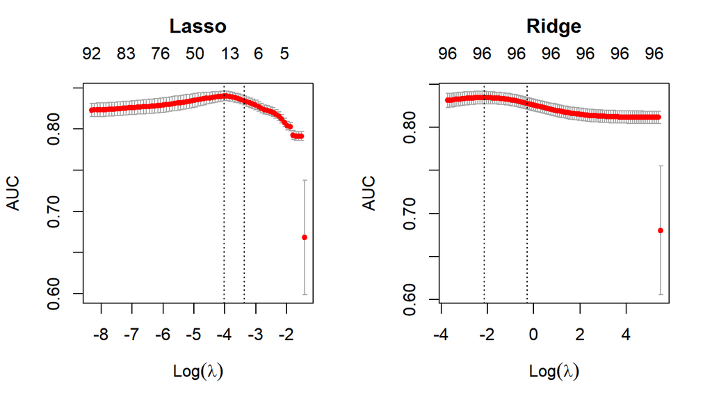

```r
set.seed(2026)
cv_lasso <- cv.glmnet(primer$X_tr, primer$y_tr, family = "binomial", alpha = 1,
                      type.measure = "auc", foldid = as.integer(fold))
cv_ridge <- cv.glmnet(primer$X_tr, primer$y_tr, family = "binomial", alpha = 0,
                      type.measure = "auc", foldid = as.integer(fold))

par(mfrow = c(1, 2))
plot(cv_lasso)
title("Lasso", line = 2.5)
plot(cv_ridge)
title("Ridge", line = 2.5)
```

```r
par(mfrow = c(1, 1))

tibble(model = c("Lasso", "Ridge"),
       lambda_min = c(cv_lasso$lambda.min, cv_ridge$lambda.min),
       auc = c(max(cv_lasso$cvm), max(cv_ridge$cvm))) %>%
  mutate(across(where(is.numeric), ~ signif(.x, 3)))
```

```
## # A tibble: 2 × 3
##   model lambda_min   auc
##   <chr>      <dbl> <dbl>
## 1 Lasso     0.0178 0.84
## 2 Ridge     0.117  0.834
```

### 10.1.2 Broj suseda k

Kod algoritma k najbližih suseda broj suseda k direktno kontroliše fleksibilnost modela. Malo k (recimo k = 5) daje veoma fleksibilan model koji se oslanja na svega par najsličnijih tačaka pa ima nisku pristrasnost ali veliku varijansu, dok veliko k uprosečava mnogo sastanaka i daje glatkiju granicu odlučivanja.

U prethodnom poglavlju smo posumnjali da kNN radi loše prvenstveno zbog desetina nebitnih kolona koje kvare obračun Euklidskog rastojanja. Zato ovde kroz mrežu vrednosti k od 5 do 151 paralelno testiramo dve verzije kNN modela: jednu sa svih 96 kolona i drugu u kojoj zadržavamo samo 13 ključnih promenljivih (šest ocena sa sastanka i sedam izvedenih promenljivih iz osmog poglavlja):

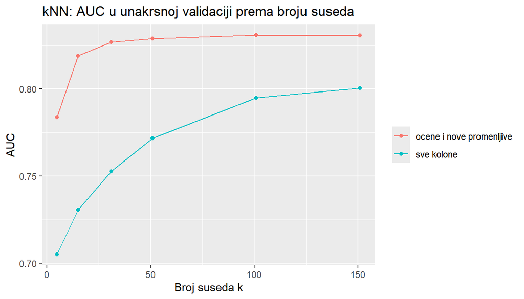

```r
kolone_knn <- c(osobine, nove)
izbaci_knn <- setdiff(names(trening), c("dec", kolone_knn))

susedi <- c(5, 15, 31, 51, 101, 151)

set.seed(2026)
knn_rezultati <- map_dfr(susedi, function(k) {
  bind_rows(
    cv_grupno(m_knn, k = k) %>%
      mutate(kolone = "sve kolone"),
    cv_grupno(m_knn, izbaci = izbaci_knn, k = k) %>%
      mutate(kolone = "ocene i nove promenljive")
  ) %>%
    mutate(k = k)
})

ggplot(knn_rezultati, aes(x = k, y = auc, color = kolone)) +
  geom_line() +
  geom_point() +
  labs(title = "kNN: AUC u unakrsnoj validaciji prema broju suseda",
       x = "Broj suseda k", y = "AUC", color = NULL)
```

```r
najbolji_knn <- knn_rezultati %>%
  filter(kolone == "ocene i nove promenljive") %>%
  slice_max(auc, n = 1, with_ties = FALSE)

najbolji_knn %>%
  select(k, auc, tacnost, f1) %>%
  mutate(across(where(is.numeric), ~ round(.x, 3)))
```

```
## # A tibble: 1 × 4
##       k   auc tacnost    f1
##   <dbl> <dbl>   <dbl> <dbl>
## 1   101 0.831   0.758 0.718
```

Grafik daje izuzetno jasan rezultat i u potpunosti potvrđuje našu hipotezu o prokletstvu dimenzionalnosti. Crvena kriva koja koristi samo ocene sa sastanka i izvedene promenljive leži drastično iznad plave krive sa svim kolonama za svaku vrednost parametra k. Takođe vidimo da kod obe verzije veći broj suseda donosi stabilnije verovatnoće, pa suženi kNN model pri k = 101 dostiže AUC od 0,831, tačnost od 75,8% i F1 meru od 0,718, čime staje rame uz rame sa ridge i lasso regresijom.

## 10.2 Izbor promenljivih

Sada detaljnije ispitujemo koje su to promenljive od početnih 96 zaista bitne za predviđanje odluke, koristeći koeficijente lasso modela i analizu faktora rasta varijanse (VIF).

### 10.2.1 Lasso

Pogledajmo prvo koliko je tačno kolona lasso model pri optimalnom λ = 0,0178 zadržao u jednačini i koje promenljive imaju najveće standardizovane koeficijente:

```r
koef_lasso <- coef(cv_lasso, s = "lambda.min")

koef_tabela <- tibble(promenljiva = rownames(koef_lasso),
                      koeficijent = as.numeric(koef_lasso)) %>%
  filter(promenljiva != "(Intercept)")

koef_tabela %>%
  summarise(ukupno = n(),
            jednako_nuli = sum(koeficijent == 0),
            zadrzano = sum(koeficijent != 0))
```

```
## # A tibble: 1 × 3
##   ukupno jednako_nuli zadrzano
##    <int>        <int>    <int>
## 1     96           79       17
```

```r
koef_tabela %>%
  filter(koeficijent != 0) %>%
  arrange(desc(abs(koeficijent))) %>%
  slice_head(n = 12) %>%
  mutate(koeficijent = round(koeficijent, 3))
```

```
## # A tibble: 12 × 2
##    promenljiva       koeficijent
##    <chr>                   <dbl>
##  1 attr_relativno          0.519
##  2 shar                    0.419
##  3 attr                    0.398
##  4 fun                     0.328
##  5 broj_na_ocena          -0.23
##  6 imprace                -0.133
##  7 genderMuškarac          0.112
##  8 ponderisana_ocena       0.07
##  9 raceEvropska/bela      -0.068
## 10 sinc2_1                 0.053
## 11 exercise               -0.051
## 12 shar1_1                 0.045
```

Vidimo da je lasso uradio veoma oštru selekciju: od ukupno 96 kolona, čak 79 je postavio na tačnu nulu i izbacio iz modela, zadržavši svega 17 prediktora. Na samom vrhu po jačini uticaja nalazi se naša izvedena promenljiva attr_relativno sa koeficijentom 0,519, a odmah iza nje su zajednička interesovanja shar (0,419), sirova ocena privlačnosti attr (0,398) i zabavnost fun (0,328). Na petom mestu je još jedna naša nova kolona, broj_na_ocena sa snažnim negativnim koeficijentom od -0,230, što potvrđuje da je čuvanje informacije o preskočenim ocenama bio odličan potez. U modelu su ostali još i važnost iste rase imprace, pol učesnika, evropska rasa, nekoliko preferencija i ponderisana ocena, dok su skoro svi hobiji i oblasti studija obrisani.

### 10.2.2 Multikolinearnost

U šestom i osmom poglavlju videli smo da su ocene sa sastanka i nove izvedene kolone poput proseka svih ocena međusobno jako korelisane. Da bismo izmerili stepen multikolinearnosti u običnoj logističkoj regresiji, računamo faktor rasta varijanse (VIF) za šest ocena i tri izvedene kolone, pri čemu vrednosti VIF veće od 5 ili 10 ukazuju na ozbiljno preklapanje:

```r
# provera multikolinearnosti pomocu VIF faktora
# VIF iz korelacija procenjenih koeficijenata (isti rezultat kao car::vif za numericke prediktore)
vif_glm <- function(model) {
  r <- cov2cor(vcov(model)[-1, -1])
  diag(solve(r))
}
podaci_vif <- popuni(trening, nauci_pripremu(trening))

model_vif <- glm(dec ~ attr + sinc + intel + fun + amb + shar +
                   prosek_ocena + attr_relativno + ponderisana_ocena,
                 data = podaci_vif, family = binomial)

sort(round(vif_glm(model_vif), 1), decreasing = TRUE)
```

```
##      prosek_ocena ponderisana_ocena              attr              sinc
##              72.7              14.6               6.6               5.6
##             intel               amb               fun              shar
##               5.4               5.4               5.2               5.2
##    attr_relativno
##               2.4
```

```r
model_vif_2 <- update(model_vif, . ~ . - prosek_ocena)

sort(round(vif_glm(model_vif_2), 1), decreasing = TRUE)
```

```
## ponderisana_ocena              attr             intel              sinc
##              12.7               3.9               3.1               2.6
##    attr_relativno               fun               amb              shar
##               2.4               2.3               2.0               1.6
```

U prvom modelu kolona prosek_ocena ima ogroman VIF od čak 72,7, dok šest pojedinačnih ocena ima VIF između 5,2 i 6,6. To je sasvim logično jer je prosek_ocena čista aritmetička sredina tih šest ocena, pa u linearnom modelu pravi skoro savršenu kolinearnost. Čim u drugom koraku izbacimo prosek_ocena iz modela, VIF vrednosti za svih šest ocena padaju na potpuno bezbedan nivo između 1,6 i 3,9, dok jedino ponderisana_ocena ostaje visoka sa 12,7 jer i ona kombinuje iste te ocene.

Iz istog matematičkog razloga u ovakvu proveru ne treba stavljati svih šest kolona početnih preferencija attr1_1 do shar1_1 odjednom, jer je njihov zbir uvek fiksiran na 100, pa je svaka šesta kolona u potpunosti određena zbirom preostalih pet.

## 10.3 Transformacije promenljivih

### 10.3.1 Kvadratni član i interakcija

Sada proveravamo da li logističkoj regresiji možemo da pomognemo dodavanjem nelinearnih članova i interakcija. Na osnovu nalaza iz šestog i sedmog poglavlja u model ubacujemo kvadratni član ocene privlačnosti attr² kako bismo uhvatili eventualno zakrivljenje, kao i interakciju attr * pol iz hipoteze H2:

```r
trening_poly <- trening %>%
  mutate(attr_kvadrat = attr^2,
         attr_muskarac = attr * (gender == "Muškarac"))

set.seed(2026)
r_poly <- cv_grupno(m_logisticka, podaci = trening_poly)
r_poly %>% mutate(across(where(is.numeric), ~ round(.x, 3)))
```

```
## # A tibble: 1 × 6
##     auc tacnost preciznost odziv specificnost    f1
##   <dbl>   <dbl>      <dbl> <dbl>        <dbl> <dbl>
## 1 0.821   0.752      0.719 0.688          0.8 0.703
```

Iako se u sedmom poglavlju interakcija između privlačnosti i pola pokazala kao statistički značajna, njeno dodavanje zajedno sa kvadratnim članom podiže AUC u unakrsnoj validaciji sa 0,819 na svega 0,821. To je lep primer razlike između statističke značajnosti i prediktivne moći: razlika u nagibu između muškaraca i žena zaista postoji, ali pošto privlačnost kod oba pola snažno gura odluku u istom smeru, taj dodatni detalj skoro uopšte ne menja konačna predviđanja modela, pa ove dve kolone ne zadržavamo.

## 10.4 Način imputacije

U četvrtom poglavlju smo videli da ocene sa sastanka poput shar i amb nedostaju u 8% do 13% redova. Do sada smo ta prazna polja popunjavali običnom medijanom iz trening skupa, koja svakom praznom polju dodeljuje istu srednju ocenu. Sada želimo da proverimo da li će model biti tačniji ako primenimo pametniju, regresionu imputaciju. Ideja je da unutar svakog preklopa, za svaku od šest ocena koja ima prazna polja, na trening podacima obučimo linearni model koji tu ocenu predviđa na osnovu preostalih pet ocena sa tog sastanka i pola učesnika. Tako će partner koji je dobio dvojke i trojke na ostalim osobinama i za prazno polje shar dobiti nisku ocenu umesto medijane:

```r
# funkcija regresiona_imputacija() definisana je u devetom poglavlju, uz pripremi()
set.seed(2026)
r_imputacija <- cv_grupno(m_glmnet, imputacija = "regresija", alpha = 1)

bind_rows("medijana" = rezultati_cv %>% filter(model == "Lasso") %>% select(-model),
          "regresija" = r_imputacija,
          .id = "imputacija") %>%
  mutate(across(where(is.numeric), ~ round(.x, 3)))
```

```
## # A tibble: 2 × 7
##   imputacija   auc tacnost preciznost odziv specificnost    f1
##   <chr>      <dbl>   <dbl>      <dbl> <dbl>        <dbl> <dbl>
## 1 medijana   0.839   0.76       0.739 0.675        0.823 0.706
## 2 regresija  0.839   0.762      0.743 0.677        0.825 0.709
```

Kada uporedimo lasso model uz imputaciju medijanom (AUC 0,839, tačnost 76,0%) i uz regresionu imputaciju (AUC 0,839, tačnost 76,2%), vidimo da su rezultati praktično identični. Razlog zašto složenija imputacija ovde ne donosi nikakav skok leži u tome što ocenama nedostaje relativno mali procenat podataka, a glavnu informaciju o tome da je učesnik bojkotovao ocenjivanje partnera koji mu se ne sviđa model je već dobio kroz našu izvedenu kolonu broj_na_ocena. Zato se u konačnom modelu držimo jednostavnije imputacije medijanom.

## 10.5 Neuravnoteženost klasa i izbor praga

Pošto u trening skupu imamo 42,7% odgovora „da” i 57,3% odgovora „ne”, podrazumevani prag verovatnoće od 0,50 pri kom model seče odluku više odgovara brojnijoj klasi „ne”, zbog čega je kod našeg lasso modela specifičnost (82,3%) dosta viša od odziva (67,5%). Zato proveravamo kako se menjaju tačnost, preciznost, odziv i F1 mera kada prag odlučivanja pomeramo u rasponu od 0,20 do 0,70:

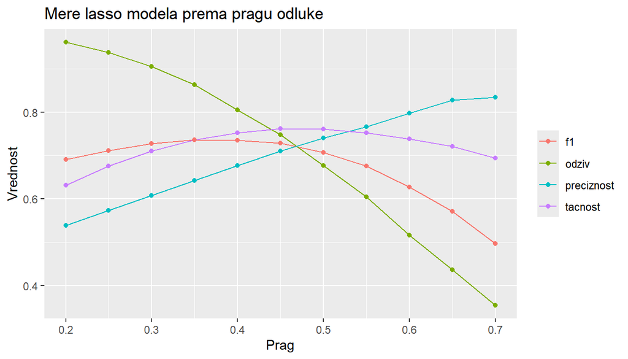

```r
set.seed(2026)
p_lasso_cv <- cv_grupno(m_glmnet, alpha = 1, vrati_p = TRUE)

po_pragu <- map_dfr(seq(0.2, 0.7, by = 0.05), function(t) {
  metrike(trening$dec, p_lasso_cv, prag = t) %>% mutate(prag = t)
})

po_pragu %>%
  select(prag, tacnost, preciznost, odziv, f1) %>%
  pivot_longer(-prag, names_to = "mera", values_to = "vrednost") %>%
  ggplot(aes(x = prag, y = vrednost, color = mera)) +
  geom_line() +
  geom_point() +
  labs(title = "Mere lasso modela prema pragu odluke",
       x = "Prag", y = "Vrednost", color = NULL)
```

```r
najbolji_prag <- po_pragu$prag[which.max(po_pragu$f1)]
najbolji_prag
```

```
## [1] 0.35
```

Grafik jasno prikazuje kompromis između preciznosti i odziva. Dok se maksimalna ukupna tačnost postiže oko praga 0,45 do 0,50, F1 mera svoj vrhunac od 0,736 dostiže pri nižem pragu od 0,35 (naspram 0,706 na pragu 0,50). Spuštanjem praga na 0,35 govorimo modelu da lakše predviđa „da”, čime pronalazimo znatno veći procenat stvarnih simpatija uz nešto više lažnih uzbuna. Zato ćemo na test skupu za lasso model pored standardnog praga 0,50 prikazati i rezultat sa pragom 0,35.

## 10.6 Pregled iteracija

```r
pregled <- bind_rows(
  "Logistička regresija, sve promenljive" =
    rezultati_cv %>% filter(model == "Logistička regresija") %>% select(-model),
  "Logistička regresija, attr² i attr × pol" = r_poly,
  "Lasso, imputacija medijanom" =
    rezultati_cv %>% filter(model == "Lasso") %>% select(-model),
  "Lasso, regresiona imputacija" = r_imputacija,
  "Ridge" = rezultati_cv %>% filter(model == "Ridge") %>% select(-model),
  "kNN, sve kolone (najbolje k)" =
    knn_rezultati %>% filter(kolone == "sve kolone") %>%
    slice_max(auc, n = 1, with_ties = FALSE) %>% select(-kolone, -k),
  "kNN, ocene i nove promenljive (najbolje k)" =
    najbolji_knn %>% select(-kolone, -k),
  .id = "iteracija"
)

pregled %>%
  select(iteracija, auc, tacnost, f1) %>%
  mutate(across(where(is.numeric), ~ round(.x, 3))) %>%
  arrange(desc(auc))
```

```
## # A tibble: 7 × 4
##   iteracija                                    auc tacnost    f1
##   <chr>                                      <dbl>   <dbl> <dbl>
## 1 Lasso, imputacija medijanom                0.839   0.76  0.706
## 2 Lasso, regresiona imputacija               0.839   0.762 0.709
## 3 Ridge                                      0.834   0.757 0.701
## 4 kNN, ocene i nove promenljive (najbolje k) 0.831   0.758 0.718
## 5 Logistička regresija, attr² i attr × pol   0.821   0.752 0.703
## 6 Logistička regresija, sve promenljive      0.819   0.751 0.702
## 7 kNN, sve kolone (najbolje k)               0.801   0.728 0.642
```

Kada podvučemo crtu ispod svih isprobanih iteracija na trening skupu, vidimo da najveći dobitak donose eliminacija šuma kroz izbor promenljivih i regularizaciju (lasso, ridge i suženi skup kolona za kNN), čime svi dobri modeli dolaze u veoma uzak pojas AUC skora između 0,831 i 0,839. Nelinearne transformacije i regresiona imputacija nisu donele poboljšanje, pa na konačno testiranje izvodimo čiste, regularizovane modele i popravljeni kNN. Treba imati u vidu da su k = 101, izbor 13 kolona za kNN i prag 0,35 izabrani upravo na osnovu ovih rezultata unakrsne validacije, pa su brojevi u ovoj tabeli blago optimistični. Poštenu procenu daje tek test skup u nastavku.

## 10.7 Konačna procena na test skupu

Sada sve izabrane modele učimo na kompletnom trening skupu od 6.732 sastanka i po prvi put ih ocenjujemo na test skupu od 1.646 sastanaka (110 učesnika) koji do ovog trenutka uopšte nije korišćen.

### 10.7.1 Postupak na primeru lasso modela

Pre nego što prikažemo rezultate svih modela, ceo put od podataka do mere na test skupu prolazimo korak po korak na primeru lasso modela. Ostali modeli prolaze kroz potpuno isti postupak, a razlikuju se samo u četvrtom koraku, odnosno u tome kako se model uči:

1. Podela. Test skup od 110 učesnika izdvojen je na početku devetog poglavlja i do sada nije korišćen ni za šta, ni za učenje, ni za izbor λ, ni za izbor praga.
2. Priprema. Funkcija pripremi() računa medijane, moduse, proseke i standardne devijacije samo na trening skupu, a onda te iste vrednosti primenjuje i na test skup.
3. Izbor λ. Funkcija cv.glmnet() bira jačinu kazne λ petostrukom unakrsnom validacijom, ali samo nad trening skupom, pri čemu su preklopi napravljeni po učesniku. Za svaku vrednost λ model se uči na četiri petine trening učesnika, a AUC se meri na preostaloj petini, i bira se λ sa najvećim prosečnim AUC (lambda.min).
4. Konačni model. Sa izabranim λ model se ponovo uči na celom trening skupu (cv.glmnet ovo radi automatski i čuva u objektu).
5. Predviđanje. Taj jedan model primenjujemo na test skup i za svaki sastanak dobijamo verovatnoću da je odgovor „da”.
6. Odluka i mere. Verovatnoće veće ili jednake od 0,50 pretvaramo u „da”, ostale u „ne”, pa poređenjem sa stvarnim odlukama dobijamo matricu konfuzije i mere uspešnosti.

```r
# korak 2: priprema naucena samo na treningu, primenjena na test
konacno <- pripremi(trening, test)
dim(konacno$X_tr)
```

```
## [1] 6732   96
```

```r
dim(konacno$X_va)
```

```
## [1] 1646   96
```

```r
# korak 3 i 4: izbor lambda unakrsnom validacijom po ucesniku, samo na treningu
set.seed(2026)
fold_lasso <- match(konacno$iid_tr, sample(unique(konacno$iid_tr))) %% 5 + 1
lasso_konacni <- cv.glmnet(konacno$X_tr, konacno$y_tr, family = "binomial",
                           alpha = 1, type.measure = "auc", foldid = fold_lasso)
lasso_konacni$lambda.min
```

```
## [1] 0.02587502
```

```r
sum(coef(lasso_konacni, s = "lambda.min")[-1] != 0)
```

```
## [1] 13
```

```r
# korak 5: verovatnoce za test skup
p_test_lasso <- as.numeric(predict(lasso_konacni, newx = konacno$X_va,
                                   s = "lambda.min", type = "response"))
round(head(p_test_lasso), 3)
```

```
## [1] 0.063 0.474 0.160 0.729 0.366 0.258
```

```r
# korak 6: prag 0,5, matrica konfuzije i mere
table(stvarno = test$dec, predvidjeno = as.integer(p_test_lasso >= 0.5))
```

```
##        predvidjeno
## stvarno   0   1
##       0 816 186
##       1 235 409
```

```r
metrike(test$dec, p_test_lasso) %>%
  mutate(across(where(is.numeric), ~ round(.x, 3)))
```

```
## # A tibble: 1 × 6
##     auc tacnost preciznost odziv specificnost    f1
##   <dbl>   <dbl>      <dbl> <dbl>        <dbl> <dbl>
## 1 0.821   0.744      0.687 0.635        0.814  0.66
```

Unakrsna validacija na trening skupu izabrala je λ ≈ 0,026, pri kom lasso zadržava 13 kolona. To je za nijansu drugačije od λ = 0,0178 i 17 kolona iz desetog poglavlja, jer cv.glmnet ovde koristi drugu nasumičnu podelu učesnika na preklope, a kriva AUC je oko svog maksimuma skoro ravna, pa male promene podele malo pomeraju izabrano λ. Na test skupu ovaj model daje AUC 0,821 i tačnost 74,4%, uz 409 tačno prepoznatih odgovora „da” i 816 tačno prepoznatih odgovora „ne”.

Test skup je u ovom postupku upotrebljen samo jednom, na samom kraju, i nijedna odluka o modelu (izbor kolona, λ, k ili praga) nije doneta na osnovu njega. Zato je mera koju dobijemo poštena procena toga kako bi se model ponašao na novim učesnicima.

### 10.7.2 Rezultati svih modela

Na isti način sada učimo i ostale modele i poredimo ih na test skupu:

```r
konacno_knn <- pripremi(trening, test, izbaci = izbaci_knn)

set.seed(2026)
predvidjanja <- list(
  "Osnovni model" = m_osnovni(konacno),
  "Logistička regresija" = m_logisticka(konacno),
  "Ridge" = m_glmnet(konacno, alpha = 0),
  "Lasso" = p_test_lasso,
  "kNN" = m_knn(konacno_knn, k = najbolji_knn$k)
)

rezultati_test <- map_dfr(predvidjanja, ~ metrike(test$dec, .x), .id = "model")

rezultati_test %>%
  mutate(across(where(is.numeric), ~ round(.x, 3))) %>%
  arrange(desc(auc))
```

```
## # A tibble: 5 × 7
##   model                  auc tacnost preciznost odziv specificnost      f1
##   <chr>                <dbl>   <dbl>      <dbl> <dbl>        <dbl>   <dbl>
## 1 Logistička regresija 0.826   0.756      0.689 0.685        0.801   0.687
## 2 Ridge                0.822   0.754      0.713 0.621        0.839   0.664
## 3 Lasso                0.821   0.744      0.687 0.635        0.814   0.66
## 4 kNN                  0.813   0.741      0.657 0.705        0.763   0.68
## 5 Osnovni model        0.5     0.609    NaN     0            1     NaN
```

```r
metrike(test$dec, predvidjanja$Lasso, prag = najbolji_prag) %>%
  mutate(across(where(is.numeric), ~ round(.x, 3)))
```

```
## # A tibble: 1 × 6
##     auc tacnost preciznost odziv specificnost    f1
##   <dbl>   <dbl>      <dbl> <dbl>        <dbl> <dbl>
## 1 0.821   0.705      0.586 0.839        0.619  0.69
```

### 10.7.3 ROC krive i matrica konfuzije

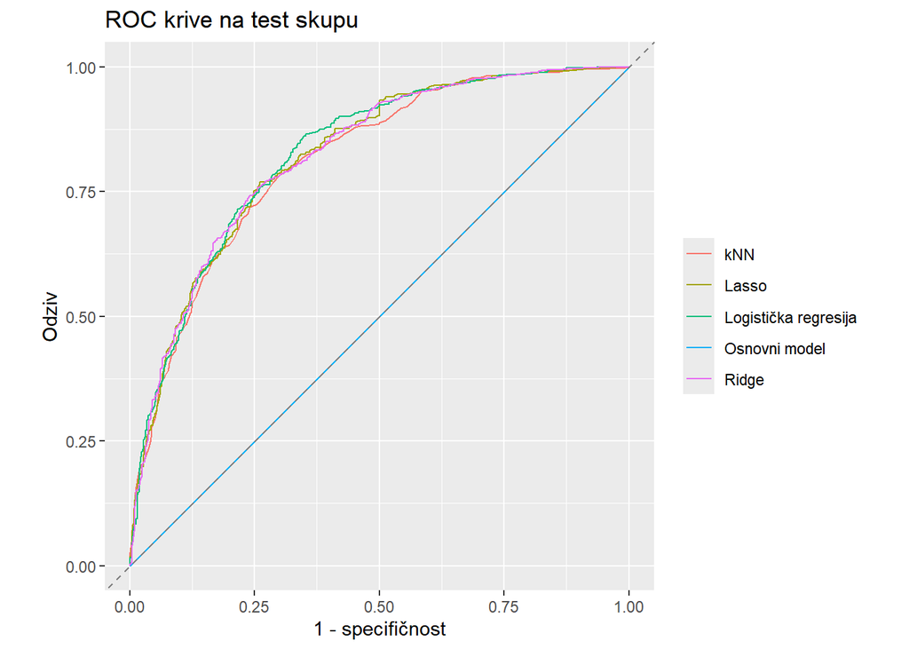

```r
roc_kriva <- function(y, p) {
  pragovi <- c(Inf, sort(unique(p), decreasing = TRUE))
  tibble(fpr = sapply(pragovi, function(t) mean(p[y == 0] >= t)),
         tpr = sapply(pragovi, function(t) mean(p[y == 1] >= t)))
}

map_dfr(predvidjanja, ~ roc_kriva(test$dec, .x), .id = "model") %>%
  ggplot(aes(x = fpr, y = tpr, color = model)) +
  geom_path() +
  geom_abline(linetype = "dashed", color = "grey50") +
  coord_equal() +
  labs(title = "ROC krive na test skupu",
       x = "1 - specifičnost", y = "Odziv", color = NULL)
```

```r
matrica <- table(stvarno = factor(test$dec, levels = c(1, 0), labels = c("Da", "Ne")),
                 predvidjeno = factor(as.integer(predvidjanja$Lasso >= 0.5), levels = c(1, 0),
                                      labels = c("Da", "Ne")))
matrica
```

```
##        predvidjeno
## stvarno  Da  Ne
##      Da 409 235
##      Ne 186 816
```

```r
propusteno_da <- matrica["Da", "Ne"]
pogresno_da <- matrica["Ne", "Da"]
```

Sa grafika vidimo da se ROC krive za lasso, ridge, logističku regresiju i popravljeni kNN model skoro potpuno preklapaju i visoko izdižu iznad sive dijagonale nasumičnog pogađanja. Iz matrice konfuzije vidimo da je lasso model na 1.646 sastanaka iz test skupa tačno pogodio 409 potvrdnih i 816 odričnih odluka, dok je u 235 slučajeva propustio da prepozna „da” i u 186 slučajeva pogrešno predvideo „da” kada je učesnik zapravo odbio partnera.

### 10.7.4 Model sa ocenama like i prob na test skupu

```r
konacno_sa <- pripremi(trening, test, izbaci = "iid")

set.seed(2026)
p_lasso_sa <- m_glmnet(konacno_sa, alpha = 1)
test_sa <- metrike(test$dec, p_lasso_sa)

test_sa %>% mutate(across(where(is.numeric), ~ round(.x, 3)))
```

```
## # A tibble: 1 × 6
##     auc tacnost preciznost odziv specificnost    f1
##   <dbl>   <dbl>      <dbl> <dbl>        <dbl> <dbl>
## 1 0.848   0.769      0.719 0.671        0.831 0.694
```

Kao što smo videli i na trening skupu, kada lasso modelu dozvolimo da koristi i opštu ocenu dopadanja like i procenu verovatnoće prob, AUC na test skupu raste sa 0,821 na 0,848, a tačnost na 76,9%.

## 10.8 Nesigurnost procene: bootstrap

Pošto u test skupu imamo 110 učesnika, izračunati AUC skor od 0,821 nosi određenu dozu slučajnosti u zavisnosti od toga koji su tačno ljudi pri podeli zapali u tih 20% podataka. Da bismo izmerili interval poverenja našeg rezultata na test skupu, sprovodimo neparametarski bootstrap sa 1.000 ponavljanja. Pritom u svakoj bootstrap iteraciji ponovo uzorkujemo sa vraćanjem cele učesnike (njih 110 sa svim njihovim sastancima), kako bismo očuvali zavisnost redova unutar iste osobe:

```r
# bootstrap interval poverenja na test skupu (uzorkujemo ucesnike sa vracanjem)
test_ucesnici <- unique(test$iid)
redovi_po_ucesniku <- split(seq_len(nrow(test)), test$iid)

auc_bootstrap <- function(ucesnici, indeksi) {
  redovi <- unlist(redovi_po_ucesniku[as.character(ucesnici[indeksi])])
  auc(test$dec[redovi], predvidjanja$Lasso[redovi])
}

set.seed(2026)
boot_rezultat <- boot::boot(test_ucesnici, auc_bootstrap, R = 1000)

ip_lasso <- boot::boot.ci(boot_rezultat, type = "perc")$percent[4:5]

round(c(auc = boot_rezultat$t0, donja = ip_lasso[1], gornja = ip_lasso[2]), 3)
```

```
##    auc  donja gornja
##  0.821  0.786  0.855
```

Dobijeni 95% bootstrap interval poverenja za AUC lasso modela na test skupu kreće se od 0,786 do 0,855, što potvrđuje da model stabilno i pouzdano razdvaja klase na novim ispitanicima. Pri tome bootstrap ponovo uzorkuje samo test učesnike, dok sam model ostaje isti, pa interval meri nesigurnost koja potiče od izbora test skupa, a ne i od izbora trening skupa. Interval je ipak dovoljno širok da razlike od 0,01 do 0,02 u AUC skoru između najboljih modela treba tumačiti oprezno, jer bi se sa drugačijim izborom test učesnika redosled modela lako mogao promeniti.

# 11 Zaključak

U ovom seminarskom radu sproveli smo kompletnu analizu Speed Dating skupa podataka, od čišćenja sirove tabele sa 195 kolona i ispitivanja mehanizma nedostajućih vrednosti, preko testiranja statističkih hipoteza i inženjeringa novih promenljivih pa sve do treniranja klasifikacionih modela.

## 11.1 Odgovori na istraživačka pitanja

- Hipoteza H1 je potvrđena. Muškarci su u proseku manje izbirljivi na brzim sastancima i daju potvrdan odgovor u 47,4% slučajeva naspram 36,5% kod žena. Razlika je visoko statistički značajna i na nivou sastanaka i na nivou pojedinačnih učesnika (p < 0,001), uz umeren efekat od oko 11 procentnih poena.
- Hipoteza H2 je potvrđena. Logistička regresija sa interakcijom je pokazala da fizička privlačnost partnera jače utiče na odluku muškaraca nego žena (OR interakcije = 1,19, p < 0,001). Svaki dodatni poen na skali privlačnosti povećava šansu za odgovor „da” za 2,17 puta kod muškaraca, u poređenju sa 1,82 puta kod žena.
- Hipoteza H3 je samo formalno potvrđena zbog velikog uzorka, dok su u praksi efekti zanemarljivi. Učesnici za nijansu češće kažu „da” osobama iste rase (43,4% prema 41,1%, p = 0,037) i partnerima sa manjom razlikom u godinama (p < 0,001, verovatnoća superiornosti 0,52), ali su oba efekta toliko blizu nule da nemaju praktični značaj.
- Hipoteza H4 je u potpunosti potvrđena kroz dve nezavisne provere. Iako učesnici, a posebno žene, u uvodnim upitnicima tvrde da su im inteligencija i iskrenost važnije od izgleda, modeli nad stvarnim odlukama i samoprocena učesnika dan nakon događaja (gde privlačnost skače sa 23,9 na 32,2 poena) pokazuju da na četvorominutnom sastanku odluku dominantno određuju privlačnost, zajednička interesovanja i zabavnost.
- Hipoteza H5 o hipergamiji nije potvrđena. Žene nisu birale partnere sa karijerom višeg statusa više od muškaraca, već je obrnuto: status partnerove karijere jače je uticao na odluku muškaraca (OR interakcije = 1,33, p = 0,003), a kod žena je efekat nestao kada smo uzeli u obzir ocene sa sastanka.